# Appendix A: Effect size calculation

### **Michalak et al. (2015) (Quality-checked)**

Entering data from Table 2 (p. 957)

```r
Michalak_2015 <- tibble(
  outcome = rep(c(
    "HAM-D",   # Hamilton Depression Rating Scale
    "BDI"      # BDI
  ), each = 3),

  group = rep(c(
    "MBCT", # mindfulness-based cognitive therapy
    "CBASP", # cognitive behavioral analysis system of psychotherapy
    "TAU" # Treatment as usual (control group)
  ), times = 2),

  N = rep(c(36, 35, 35), times = 2),
  N_start = N,

  m_pre = c(
    23.03, 24.71, 23.87,   # Hamilton Depression Rating Scale
    31.31, 30.26, 29.76    # BDI
  ),

  sd_pre = c(
    6.27, 6.69, 6.33,
    9.55, 7.52, 7.42
  ),

  m_post = c(
    17.86, 14.64, 21.16,     # Hamilton Depression Rating Scale
    22.69, 22.28, 28.34      # BDI
  ),

  sd_post = c(
    10.37, 8.85, 8.16,
    12.11, 12.54, 10.27
  )
)


Michalak2015_wide_DD <-
  map(c("MBCT", "CBASP"), \(x)
      Michalak_2015 |>
      filter(group %in% c(x, "TAU")) |>
      mutate(group = case_match(group, x ~ "t", "TAU" ~ "c")) |>
      tidyr::pivot_wider(
        names_from = group,
        names_glue = "{.value}_{group}",
        values_from = N:last_col()
      ) |>
        mutate(
          treatment = x,
          N_total = N_t + N_c
        ) |>
        relocate(treatment)
  ) |>
  list_rbind() |>
  mutate(

    effect_size = "SMD",
    sd_used = "Pooled posttest SD",
    main_es_method = "Raw diff-in-diffs",
    analysis_plan = "All mental health outcomes/Depression"

  )


Michalak2015_wide_from_paper <-
  tibble(

    effect_size = "SMD",
    sd_used = "Unknown - extracted from report effect sizes",
    main_es_method = "Covariate-adjusted es from multi-level regression",

    analysis_plan = rep(c(
      "Wellbeing and Quality of Life",
      "Social functioning (degree of impairment)"
    ), c(8,2)),


    outcome = paste0(
      rep(c("SF-36", "SASS"), c(8,2)), "/",
      rep(c("Vitality", "Social func", "Role", "Mental health", "overall"), each = 2)
    ),

    treatment = rep(c("MBCT","CBASP"), each = 1,5),
    N_t = rep(c(36,35), each = 1,5),
    N_c = 35,
    N_total = N_t + N_c,

    N_start_t = N_t,
    N_start_c = N_c,

    b_reg = c(1.12, 1.32,
             0.27, 0.74,
             0.52, 0.46,
             0.63, 1.25,
             2.43, 1.68),
    se_b_reg = c(0.90, 0.70,
             0.43, 0.44,
             0.26, 0.24,
             0.95, 0.89,
             1.01, 0.93),

    t_val = b_reg/se_b_reg,

    es_paper = c(0.31,0.36,
                 0.12, 0.34,
                 0.48, 0.42,
                 0.14, 0.28,
                 0.57, 0.40),

    es_paper_type = "Covariate-adjusted ES (d) from a multi-level model",

    sd_total = b_reg/es_paper

  )


Michalak_2015_dat <-
  bind_rows(Michalak2015_wide_DD, Michalak2015_wide_from_paper)

ppcor <- ppcor_imp <- 0.5

Michalak_2015_est <-
  Michalak_2015_dat |>
  mutate(
    study = "Michalak et al. 2015",
    vary_id = paste0(outcome, "/", treatment),

    ppcor = ppcor_imp,
    ppcor_method = "Imputed",

    df_ind = N_total,
    m_post = if_else(is.na(es_paper), (m_post_t - m_post_c)*-1, NA_real_),
    sd_pool = if_else(
      is.na(es_paper),
      sqrt(((N_t-1)*sd_post_t^2 + (N_c-1)*sd_post_c^2)/(N_t + N_c - 2)),
      sqrt( ((N_total-1)/(N_total-2))*sd_total^2 - ((N_t*N_c)/(N_total * (N_total-2)))*b_reg^2 )
    ),

    d_post = m_post/sd_pool,
    vd_post = (1/N_t + 1/N_c) + d_post^2/(2*df_ind),
    Wd_post = if_else(is.na(es_paper), (1/N_t + 1/N_c), NA_real_),

    J =  1 - 3/(4*df_ind-1),

    g_post =  J * (m_post/sd_pool),
    vg_post = (1/N_t + 1/N_c) + g_post^2/(2*df_ind),
    Wg_post = Wd_post,

    # DiD (DD) effect sizes for HAM-D og BDI



    #cluster bias adjustment

    # For HAM-D lower scores is beneficial, hence these are reverted
    m_diff_t = if_else(
      str_detect(outcome, "HAM|BDI"),
      (m_post_t - m_pre_t) * -1,
      m_post_t - m_pre_t
    ),

    m_diff_c = if_else(
      str_detect(outcome, "HAM|BDI"),
      (m_post_c - m_pre_c) * -1,
      m_post_c - m_pre_c
    ),

    d_DD = (m_diff_t - m_diff_c) / sd_pool,
    vd_DD = 2 * (1 - ppcor) * (1 / N_t + 1 / N_c) + d_DD^2 / (2 * df_ind),
    Wd_DD = if_else(is.na(es_paper), 2 * (1 - ppcor) * (1 / N_t + 1 / N_c), NA_real_),

    g_DD = J * d_DD,
    vg_DD = 2 * (1 - ppcor) * (1 / N_t + 1 / N_c) + g_DD^2 / (2 * df_ind),
    Wg_DD = Wd_DD,

    # Reg adjusted effect sizes for SF-36 and SASS outcomes
    d_reg = b_reg/sd_pool,
    vd_reg = d_reg^2 * (1/t_val^2 + 1/(2*df_ind)),
    Wd_reg = d_reg^2 * (1/t_val^2),

    g_reg = J * d_reg,
    vg_reg = g_reg^2 * (1/t_val^2 + 1/(2*df_ind)),
    Wg_reg = Wd_reg

  ) |>
  rowwise() |>
  mutate(
    # Average cluster size in treatment group
    avg_cl_size = 6,
    avg_cl_type = "From study (p. 177)",

    # Imputed icc value
    icc = ICC_01,
    icc_type = "Imputed",

    n_covariates = 1,# Baseline scores only

    # Find info about the function via ?VIVECampbell::gamma_1armcluster
    gamma_sqrt = VIVECampbell::gamma_1armcluster(
      N_total = N_total, Nc = N_c, avg_grp_size = avg_cl_size, ICC = icc
    ),

    # Calculated via Eq. 7 (Hedges & Citkowicz, 2015)
    df_adj = df_h_1armcluster(N_total = N_total, ICC = icc, N_grp = N_t, avg_grp_size = avg_cl_size),
    omega = 1 - 3 / (4 * df_adj - 1),

    # Cluster-adjusting g_post
    gt_post = if_else(is.na(es_paper), omega * d_post * gamma_sqrt, NA_real_),
    VIVECampbell::vgt_smd_1armcluster(
      N_cl_grp = N_t,
      N_ind_grp = N_c,
      avg_grp_size = avg_cl_size,
      ICC = icc,
      g = gt_post,
      model = "posttest",
      cluster_adj = FALSE,
      add_name_to_vars = "_post",
      vars = c("vgt_post", "Wgt_post")
    ),

    gt_DD = omega * d_DD * gamma_sqrt,
    VIVECampbell::vgt_smd_1armcluster(
      N_cl_grp = N_t,
      N_ind_grp = N_c,
      avg_grp_size = avg_cl_size,
      ICC = icc,
      g = gt_DD,
      model = "DiD",
      cluster_adj = FALSE,
      prepost_cor = ppcor,
      q = n_covariates,
      add_name_to_vars = "_DD",
      vars = -c("var_term1_DD")
    ),

    gt_reg = omega * d_reg * gamma_sqrt,
    VIVECampbell::vgt_smd_1armcluster(
      N_cl_grp = N_t,
      N_ind_grp = N_c,
      avg_grp_size = avg_cl_size,
      ICC = icc,
      g = gt_reg,
      model = "reg_coef",
      cluster_adj = TRUE,
      t_val = t_val,
      q = n_covariates,
      add_name_to_vars = "_reg",
      vars = -c("var_term1_reg")
    ),

    across(c(Wgt_post, Wgt_DD:adj_value_DD), ~ if_else(!str_detect(outcome, "HAM|BDI"), NA, .x)),
    across(c(Wgt_reg:adj_value_reg), ~ if_else(str_detect(outcome, "HAM|BDI"), NA, .x)),

    gt_DD_pop = if_else(
      str_detect(outcome, "BDI"),
      omega * ((m_diff_t - m_diff_c)/BDI_pop_res$sd_population) * gamma_sqrt,
      NA_real_
      ),

    # Calculated from Eq. 28 (Fitzgerald & Tipton, 2024)
    vgt_DD_pop = if_else(
      str_detect(outcome, "BDI"),
      BDI_pop_res$WaboveT * (2*(1-ppcor) * (1/N_t + 1/N_c) * adj_value_DD) + gt_DD_pop^2/(2*BDI_pop_res$df_pop),
      NA_real_
      ),

    Wgt_DD_pop = if_else(
      str_detect(outcome, "BDI"),
      BDI_pop_res$WaboveT * (2*(1-ppcor) * (1/N_t + 1/N_c) * adj_value_DD),
      NA_real_
      )

  ) |>
  ungroup(); Michalak_2015_est
```

```
## # A tibble: 14 × 87
##    treatment outcome               N_t   N_c N_start_t N_start_c m_pre_t m_pre_c
##    <chr>     <chr>               <dbl> <dbl>     <dbl>     <dbl>   <dbl>   <dbl>
##  1 MBCT      HAM-D                  36    35        36        35   23.03   23.87
##  2 MBCT      BDI                    36    35        36        35   31.31   29.76
##  3 CBASP     HAM-D                  35    35        35        35   24.71   23.87
##  4 CBASP     BDI                    35    35        35        35   30.26   29.76
##  5 MBCT      SF-36/Vitality         36    35        36        35   NA      NA
##  6 CBASP     SF-36/Vitality         35    35        35        35   NA      NA
##  7 MBCT      SF-36/Social func      36    35        36        35   NA      NA
##  8 CBASP     SF-36/Social func      35    35        35        35   NA      NA
##  9 MBCT      SF-36/Role             36    35        36        35   NA      NA
## 10 CBASP     SF-36/Role             35    35        35        35   NA      NA
## 11 MBCT      SF-36/Mental health    36    35        36        35   NA      NA
## 12 CBASP     SF-36/Mental health    35    35        35        35   NA      NA
```

[output cut: 226 more lines]

### **Morley et al. (2014) (Quality-checked)**

Entering data from Table 2 (p. 136)

```r
# Data from table 2 containing means and standard deviation on page 136

Morley2014 <- tibble(
  group = as.factor(rep(c("Intervention",
                          "Control"),
                        each = 1,4)),

  outcome = as.factor(rep(c("BSS",
                            "HADS_depression",
                            "HADS_anxiety",
                            "SES"), each = 2,1
  )),

  N = rep(c(
    122, 63 # obtained from Table 1 (p. 135)
  ), each = 1,4),


   N_start = rep(c(
    122, 63 # obtained from Table 1 (p. 135)
  ), each = 1,4),

#   q = 6, # Controlling for Unemployment status, Suicide Ideation, recent cannabis use,
        # recent heroin use, life time cocaine use, lifetime amphetamine use (p. 134)


  m_pre = c(
    9.5, 12.56, # Beck Scale for Suicide Ideation (range 0–38)
    9.3, 9.89,  # HAD Scale Depression (range 0–21)
    12.58, 12.35, # HAD Scale Anxiety (range 0–21)
    61.76, 65.09  # Self-Efficacy Scale (range 0–90)
  ),

  sd_pre = c(
    9.61, 8.55,
    6.66, 5.6,
    6.66, 5.39,
    15.34, 12.55
  ),

  m_post = c(
    5.83, 6,
    6.4, 7.1,
    8.83, 9.71,
    65.31, 65.13
  ),

  sd_post = c(
    5.58, 6.61,
    5.43, 4.3,
    5.72, 4.3,
    12.49, 9.58
  )

  ); Morley2014
```

```
## # A tibble: 8 × 8
##   group        outcome             N N_start m_pre sd_pre m_post sd_post
##   <fct>        <fct>           <dbl>   <dbl> <dbl>  <dbl>  <dbl>   <dbl>
## 1 Intervention BSS               122     122  9.5    9.61   5.83    5.58
## 2 Control      BSS                63      63 12.56   8.55   6       6.61
## 3 Intervention HADS_depression   122     122  9.3    6.66   6.4     5.43
## 4 Control      HADS_depression    63      63  9.89   5.6    7.1     4.3
## 5 Intervention HADS_anxiety      122     122 12.58   6.66   8.83    5.72
## 6 Control      HADS_anxiety       63      63 12.35   5.39   9.71    4.3
## 7 Intervention SES               122     122 61.76  15.34  65.31   12.49
## 8 Control      SES                63      63 65.09  12.55  65.13    9.58
```

```r
# Turning dataset into wide format
Morley2014_wide <-
  Morley2014 |>
  mutate (group = case_match(
    group, "Intervention"  ~ "t",
    "Control" ~ "c")) |>
  tidyr::pivot_wider(
    names_from = group,
    names_glue = "{.value}_{group}",
    values_from = N:last_col()
  )


# Effect size calculating
Morley2014_est <-
  Morley2014_wide |>
  mutate(

     analysis_plan = case_when(
      str_detect(outcome, "BSS") ~ "All mental health outcomes",
      str_detect(outcome, "HADS_depression") ~ "All mental health outcomes/Depression",
      str_detect(outcome, "HADS_anxiety") ~ "All mental health outcomes/Anxiety",
      str_detect(outcome, "SES") ~ "Hope, Empowerment & Self-efficacy",
      .default = NA_character_
    ),

    effect_size = "SMD",
    sd_used = "Pooled posttest SD",
    main_es_method = "Raw diff-in-diffs",


    # ppcor imputed
    ppcor = ppcor_imp,
    ppcor_method = "Imputed",


    study = "Morley et al. 2014",

    N_total = N_t + N_c,
    df_ind = N_total,

    # Reverting m_post for specific outcomes
    m_post = if_else(outcome %in% c("BSS", "HADS_depression", "HADs_anxiety"),
            (m_post_t - m_post_c) * -1,
            m_post_t - m_post_c),

    sd_pool = sqrt(((N_t-1)*sd_post_t^2 + (N_c-1)*sd_post_c^2)/(N_t + N_c - 2)),

    d_post = m_post/sd_pool,
    vd_post = (1/N_t + 1/N_c) + d_post^2/(2*df_ind),
    Wd_post = (1/N_t + 1/N_c),

    J = 1 - 3/(4*df_ind-1),

    g_post = J * d_post,
    vg_post = (1/N_t + 1/N_c) + g_post^2/(2*df_ind),
    Wg_post = Wd_post,



    # Reverting specific values
   m_diff_t = if_else(outcome %in% c("BSS",
                                     "HADS_depression",
                                     "HADs_anxiety"),
                       (m_post_t - m_pre_t)*-1,
                        m_post_t - m_pre_t),
    m_diff_c = if_else(outcome %in% c("BSS",
                                     "HADS_depression",
                                     "HADs_anxiety"),
                       (m_post_c - m_pre_c)*-1,
                       m_post_c - m_pre_c),

    d_DD = (m_diff_t - m_diff_c)/sd_pool,
    vd_DD = 2*(1-ppcor) * (1/N_t + 1/N_c) + d_DD^2/(2*df_ind),
    Wd_DD = 2*(1-ppcor) * (1/N_t + 1/N_c),

    g_DD = J * d_DD,
    vg_DD = 2*(1-ppcor) * (1/N_t + 1/N_c) + g_DD^2/(2*df_ind),
    Wg_DD = Wd_DD

  ) |>
  rowwise() |>
  mutate( # Attempt to make cluster corrected estimates. Has to be checked!

    # Group sizes was between 6 to 8
    avg_cl_size = 7,
    avg_cl_type = "From study (p. 132)",

    # Imputed icc value
    icc = ICC_01,
    icc_type = "Imputed",

    n_covariates = 1,

    # Find info about the function via ?VIVECampbell::gamma_1armcluster
    gamma_sqrt = VIVECampbell::gamma_1armcluster(
      N_total = N_total, Nc = N_c, avg_grp_size = avg_cl_size, ICC = icc
    ),

    # Calculated via Eq. 7 (Hedges & Citkowicz, 2015)
    df_adj = df_h_1armcluster(N_total = N_total, ICC = icc, N_grp = N_t, avg_grp_size = avg_cl_size),
    omega = 1 - 3/(4*df_adj-1),


    # Cluster-adjusting g_post
    gt_post = omega * d_post * gamma_sqrt,
    VIVECampbell::vgt_smd_1armcluster(
      N_cl_grp = N_t,
      N_ind_grp = N_c,
      avg_grp_size = avg_cl_size,
      ICC = icc,
      g = gt_post,
      model = "posttest",
      cluster_adj = FALSE,
      add_name_to_vars = "_post",
      vars = c(vgt_post, Wgt_post)
    ),

    gt_DD = omega * d_DD * gamma_sqrt,
    VIVECampbell::vgt_smd_1armcluster(
      N_cl_grp = N_t,
      N_ind_grp = N_c,
      avg_grp_size = avg_cl_size,
      ICC = icc,
      g = gt_DD,
      model = "DiD",
      cluster_adj = FALSE,
      prepost_cor = ppcor,
      q = n_covariates,
      add_name_to_vars = "_DD",
      vars = -var_term1_DD
    )

  ) |>
  ungroup() |>
  mutate(
    vary_id = outcome
  ); Morley2014_est
```

```
## # A tibble: 4 × 61
##   outcome           N_t   N_c N_start_t N_start_c m_pre_t m_pre_c sd_pre_t
##   <fct>           <dbl> <dbl>     <dbl>     <dbl>   <dbl>   <dbl>    <dbl>
## 1 BSS               122    63       122        63    9.5    12.56     9.61
## 2 HADS_depression   122    63       122        63    9.3     9.89     6.66
## 3 HADS_anxiety      122    63       122        63   12.58   12.35     6.66
## 4 SES               122    63       122        63   61.76   65.09    15.34
##   sd_pre_c m_post_t m_post_c sd_post_t sd_post_c
##      <dbl>    <dbl>    <dbl>     <dbl>     <dbl>
## 1     8.55     5.83     6         5.58      6.61
## 2     5.6      6.4      7.1       5.43      4.3
## 3     5.39     8.83     9.71      5.72      4.3
## 4    12.55    65.31    65.13     12.49      9.58
##   analysis_plan                         effect_size sd_used
##   <chr>                                 <chr>       <chr>
## 1 All mental health outcomes            SMD         Pooled posttest SD
## 2 All mental health outcomes/Depression SMD         Pooled posttest SD
## 3 All mental health outcomes/Anxiety    SMD         Pooled posttest SD
## 4 Hope, Empowerment & Self-efficacy     SMD         Pooled posttest SD
##   main_es_method    ppcor ppcor_method study              N_total df_ind  m_post
##   <chr>             <dbl> <chr>        <chr>                <dbl>  <dbl>   <dbl>
## 1 Raw diff-in-diffs   0.5 Imputed      Morley et al. 2014     185    185  0.17
## 2 Raw diff-in-diffs   0.5 Imputed      Morley et al. 2014     185    185  0.7000
## 3 Raw diff-in-diffs   0.5 Imputed      Morley et al. 2014     185    185 -0.8800
## 4 Raw diff-in-diffs   0.5 Imputed      Morley et al. 2014     185    185  0.1800
##   sd_pool   d_post vd_post Wd_post      J   g_post vg_post Wg_post m_diff_t
##     <dbl>    <dbl>   <dbl>   <dbl>  <dbl>    <dbl>   <dbl>   <dbl>    <dbl>
## 1   5.949  0.02858 0.02407 0.02407 0.9959  0.02846 0.02407 0.02407    3.67
## 2   5.075  0.1379  0.02412 0.02407 0.9959  0.1374  0.02412 0.02407    2.9
## 3   5.282 -0.1666  0.02414 0.02407 0.9959 -0.1659  0.02414 0.02407   -3.75
## 4  11.59   0.01554 0.02407 0.02407 0.9959  0.01547 0.02407 0.02407    3.550
##   m_diff_c     d_DD   vd_DD   Wd_DD     g_DD   vg_DD   Wg_DD avg_cl_size
##      <dbl>    <dbl>   <dbl>   <dbl>    <dbl>   <dbl>   <dbl>       <dbl>
## 1  6.56    -0.4858  0.02471 0.02407 -0.4838  0.02470 0.02407           7
## 2  2.79     0.02167 0.02407 0.02407  0.02159 0.02407 0.02407           7
## 3 -2.64    -0.2102  0.02419 0.02407 -0.2093  0.02419 0.02407           7
## 4  0.04000  0.3029  0.02432 0.02407  0.3017  0.02432 0.02407           7
##   avg_cl_type           icc icc_type n_covariates gamma_sqrt df_adj  omega
##   <chr>               <dbl> <chr>           <dbl>      <dbl>  <dbl>  <dbl>
## 1 From study (p. 132)   0.1 Imputed             1      0.981  175.4 0.9957
## 2 From study (p. 132)   0.1 Imputed             1      0.981  175.4 0.9957
## 3 From study (p. 132)   0.1 Imputed             1      0.981  175.4 0.9957
## 4 From study (p. 132)   0.1 Imputed             1      0.981  175.4 0.9957
##    gt_post vgt_post Wgt_post    gt_DD  vgt_DD  Wgt_DD     hg_DD   vhg_DD  h_DD
##      <dbl>    <dbl>    <dbl>    <dbl>   <dbl>   <dbl>     <dbl>    <dbl> <dbl>
## 1  0.02791  0.02739  0.02739 -0.4745  0.02803 0.02739 -0.2156   0.005701 175.4
## 2  0.1347   0.02744  0.02739  0.02117 0.02739 0.02739  0.009658 0.005701 175.4
## 3 -0.1627   0.02747  0.02739 -0.2053  0.02751 0.02739 -0.09358  0.005701 175.4
## 4  0.01518  0.02739  0.02739  0.2959  0.02764 0.02739  0.1348   0.005701 175.4
##   df_DD n_covariates_DD adj_fct_DD adj_value_DD vary_id
##   <dbl>           <dbl> <chr>             <dbl> <fct>
## 1 175.4               1 eta               1.138 BSS
## 2 175.4               1 eta               1.138 HADS_depression
## 3 175.4               1 eta               1.138 HADS_anxiety
## 4 175.4               1 eta               1.138 SES
```

### **Morton et al. (2012) (Quality-checked)**

Entering data from Table 3 (p. 538)

```r
# Data from table 3 containing means and standard deviation (p. 538)
Morton2012 <- tibble(
  group = as.factor(rep(c("Intervention",
                          "Control"),
                        each = 1,4)),

  outcome = as.factor(rep(c("BEST_composite",
  #                          "BEST_BPD_thoughts_&_feelings", The subscaled are removed
  #                                                          we only use total-scale
  #                          "BEST_BPD_negative_behaviors",
  #                          "BEST_BPD_positive_behaviors",
  #                          "DASS_stress",
                            "DASS_anxiety",
  #                          "DASS_depression",
                            "BHS",
 #                            "AAQ-II",
                            "DERS_total"
 #                           "FFMQ_total",
 #                            "ACS_total"
  ),
  each = 2,1)),

  N = rep(c(21, 20),
          each = 1,4),


  m_pre = c(
    44.57, 49.80, # BEST composite
#     28.48, 30.3, # DASS stress
     23.33, 24.20,# DASS anxiety
#    31.52, 33.7, # DASS depression
    14.40, 15.7, # BHS
    # 24.10, 22.55,# AAQ-II
     131.76, 134.42 # DERS total
    # 96.52, 92.15,# FFMQ total
    # 4.86, 4.93   # ACS total
  ),

  sd_pre = c(
    11.16, 12.35,
 #   10.04, 10.16,
    9.34, 11.76,
 #    10.86, 8.74,
    4.87, 3.58,
    # 9.29, 8.32,
     25.15, 19.45
    # 23.01, 20.81,
    # 0.74, 0.68
  ),

  m_post = c(
    32.76, 47.42,
 #   26.55, 31.57,
    19.67, 26.28,
#    22.67, 31.00,
    9.7, 16.43,
  #  35.3, 23.1,
    113.04, 140.04
  #  108.81, 90.87,
  #  4.35, 5.08
  ),

  sd_post = c(
    12.47, 11.00,
 #   11.58, 9.93,
    11.02, 8.33,
#    14.73, 8.51,
    6.34, 3.69,
  #  10.8, 7.1,
    17.64, 20.88
  #  19.11, 20.67,
  #  0.65, 0.56
  )

); Morton2012
```

```
## # A tibble: 8 × 7
##   group        outcome            N  m_pre sd_pre m_post sd_post
##   <fct>        <fct>          <dbl>  <dbl>  <dbl>  <dbl>   <dbl>
## 1 Intervention BEST_composite    21  44.57  11.16  32.76   12.47
## 2 Control      BEST_composite    20  49.8   12.35  47.42   11
## 3 Intervention DASS_anxiety      21  23.33   9.34  19.67   11.02
## 4 Control      DASS_anxiety      20  24.2   11.76  26.28    8.33
## 5 Intervention BHS               21  14.4    4.87   9.7     6.34
## 6 Control      BHS               20  15.7    3.58  16.43    3.69
## 7 Intervention DERS_total        21 131.8   25.15 113.0    17.64
## 8 Control      DERS_total        20 134.4   19.45 140.0    20.88
```

```r
Morton2012_wide <-
  Morton2012 |>
  mutate (group = case_match(
    group, "Intervention"  ~ "t", "Control" ~ "c")) |>
  tidyr::pivot_wider(
    names_from = group,
    names_glue = "{.value}_{group}",
    values_from = N:last_col()
  )


Morton2012_wide2 <- tibble(
  outcome = c("DASS_stress",
              "DASS_depression"),

  N_t = c(21),
  N_c = c(20),

  m_pre_t = c(
    28.48,
    31.52
  ),

  m_pre_c = c(
    30.3,
    33.70
  ),

  sd_pre_t = c(
    10.04,
    10.86
  ),

  sd_pre_c = c(
    10.16,
    8.74
  ),

  m_post_t = c(
    26.55,
    22.67
  ),

  m_post_c = c(
    31.57,
    31
  ),

  sd_post_t = c(
    11.58,
    14.73
  ),

  sd_post_c = c(
    9.93,
    8.51
  )

)



Morton2012_est <-
  bind_rows(
    Morton2012_wide,
    Morton2012_wide2
  ) |>
  mutate(
    study = "Morton et al. 2012",

     analysis_plan = case_when(
      str_detect(outcome, "BEST|DASS") ~ "All mental health outcomes",
      str_detect(outcome, "BHS") ~ "Hope, Empowerment & Self-efficacy",
      str_detect(outcome, "DERS") ~ "All mental health outcomes/Unused outcomes",
      .default = NA_character_
    ),

    effect_size = "SMD",
    sd_used = "Pooled posttest SD",
    main_es_method = "Raw diff-in-diffs",

  # Entering test-retest reliability measure from text and
  # Pfohl, B., Blum, N., St. John, D., McCormick, B., Allen, J., & Black, D.W.
  #   (2009). Reliability and validity of the Borderline Evaluation of
  #   Severity over Time (BEST): A self-rated scale tomeasure severity and
  #   change in persons with Borderline Personality Disorder. Journal of
  #   Personality Disorders, 23, 281–293.

  ppcor = case_when(
    str_detect(outcome, "BEST") ~ 0.62,
    str_detect(outcome, "DASS") ~ 0.81,
    str_detect(outcome, "BHS") ~ 0.69,
    str_detect(outcome, "DERS") ~ 0.88,
    .default = ppcor_imp

  ),
  ppcor_method = "Obtained from test-retest reliability measures"

  )




Morton2012_est <-
  Morton2012_est|>
  mutate(
    N_start_t = N_t,
    N_start_c = N_c,
    N_total = N_t + N_c,
    df_ind = N_total,

    # reverting all scores as lower score is beneficial
    m_post =  (m_post_t - m_post_c) * -1,
    sd_pool = sqrt(((N_t-1)*sd_post_t^2 + (N_c-1)*sd_post_c^2)/(N_t + N_c - 2)),

    d_post = m_post/sd_pool,
    vd_post = (1/N_t + 1/N_c) + d_post^2/(2*df_ind),
    Wd_post = (1/N_t + 1/N_c),

    J = 1 - 3/(4*df_ind-1),

    g_post = J * d_post,
    vg_post = (1/N_t + 1/N_c) + g_post^2/(2*df_ind),
    Wg_post = Wd_post,

    #  reverting all scores as lower score is beneficial
    m_diff_t = (m_post_t - m_pre_t)*-1,
    m_diff_c = (m_post_c - m_pre_c)*-1,

    d_DD = (m_diff_t - m_diff_c)/sd_pool,
    vd_DD = 2*(1-ppcor) * (1/N_t + 1/N_c) + d_DD^2/(2*df_ind),
    Wd_DD = 2*(1-ppcor) * (1/N_t + 1/N_c),

    g_DD = J * d_DD,
    vg_DD = 2*(1-ppcor) * (1/N_t + 1/N_c) + g_DD^2/(2*df_ind),
    Wg_DD = Wd_DD

  ) |>
  rowwise() |>
  mutate( # Attempt to make cluster corrected estimates. Has to be checked!

    # Group sizes are imputed
    avg_cl_size = grp_size_imp,
    avg_cl_type = "Imputed",

    # Imputed icc value
    icc = ICC_01,
    icc_type = "Imputed",

    n_covariates = 1,

    # Find info about the function via ?VIVECampbell::gamma_1armcluster
    gamma_sqrt = VIVECampbell::gamma_1armcluster(
      N_total = N_total, Nc = N_c, avg_grp_size = avg_cl_size, ICC = icc
    ),

    # Calculated via Eq. 7 (Hedges & Citkowicz, 2015)
    df_adj = df_h_1armcluster(N_total = N_total, ICC = icc, N_grp = N_t, avg_grp_size = avg_cl_size),
    omega = 1 - 3/(4*df_adj-1),


    # Cluster-adjusting g_post
    gt_post = omega * d_post * gamma_sqrt,
    VIVECampbell::vgt_smd_1armcluster(
      N_cl_grp = N_t,
      N_ind_grp = N_c,
      avg_grp_size = avg_cl_size,
      ICC = icc,
      g = gt_post,
      model = "posttest",
      cluster_adj = FALSE,
      add_name_to_vars = "_post",
      vars = c(vgt_post, Wgt_post)
    ),

    gt_DD = omega * d_DD * gamma_sqrt,
    VIVECampbell::vgt_smd_1armcluster(
      N_cl_grp = N_t,
      N_ind_grp = N_c,
      avg_grp_size = avg_cl_size,
      ICC = icc,
      g = gt_DD,
      model = "DiD",
      cluster_adj = FALSE,
      prepost_cor = ppcor,
      q = n_covariates,
      add_name_to_vars = "_DD",
      vars = -var_term1_DD
    ),

    vary_id = outcome

  ) |>
  ungroup(); Morton2012_est
```

```
## # A tibble: 6 × 61
##   outcome           N_t   N_c m_pre_t m_pre_c sd_pre_t sd_pre_c m_post_t
##   <chr>           <dbl> <dbl>   <dbl>   <dbl>    <dbl>    <dbl>    <dbl>
## 1 BEST_composite     21    20   44.57    49.8    11.16    12.35    32.76
## 2 DASS_anxiety       21    20   23.33    24.2     9.34    11.76    19.67
## 3 BHS                21    20   14.4     15.7     4.87     3.58     9.7
## 4 DERS_total         21    20  131.8    134.4    25.15    19.45   113.0
## 5 DASS_stress        21    20   28.48    30.3    10.04    10.16    26.55
## 6 DASS_depression    21    20   31.52    33.7    10.86     8.74    22.67
##   m_post_c sd_post_t sd_post_c study
##      <dbl>     <dbl>     <dbl> <chr>
## 1    47.42     12.47     11    Morton et al. 2012
## 2    26.28     11.02      8.33 Morton et al. 2012
## 3    16.43      6.34      3.69 Morton et al. 2012
## 4   140.0      17.64     20.88 Morton et al. 2012
```

[output cut: 58 more lines]

```r
# Regression coefficients extracted from text (pp.537-539)
# Not used for analysis!
morton2012_es <- tibble(

  study = "morton2012",

  es_method = "Multilevel model",

  group = rep(c("treatment", # Treatment is ACT + TAU
                "control", # Control is TAU.
                "interaction"), each = 1,4),

  outcome = rep(c(
                  "BEST_composite",
#                  "BEST_BPD_thoughts_feelings",
#                  "BEST_BPD_negative_behaviors",
                  "DASS_anxiety",
                  "BHS",
#                  "AAQ-II",
                  "DERS_total"
#                  "FFMQ_total",
#                  "ACS_total"
                  ), each = 3,1),

  beta = c(-11.52, -1.8, 9.71,  # BEST Composite
#           -6.6, -0.05, 6.54, # BEST BPD thoughts and feelings
#           -1.11, -3.98, 2.87, # BEST BPD negative and behaviors
           -3.92, 3.98, 7.90, # DASS anxiety
           -4.93, 0.62, 5.55, # BHS
#           5.55, 0.37, -9.88, # AAQ-II
           -19.17, 4.77, 23.94 # DERS total
#           12.30, -0.31, -12.62, # FFMQ total
#           -0.54, 0.18, 0.71), # ACS total
),

  se = c(2.75, 3.19, 4.21,
#         1.77, 2.05, 2.72,
#         1.04, 0.90, 1.38,
         2.24, 2.50, 3.36,
         1.27, 1.38, 1.87,
#         1.87, 2.65, 3.60,
         5.68, 6.30, 8.48
#         3.71, 4.06, 5.50,
#         0.15, 0.16, 0.21),
),

  t = c(2.3, -0.57, 2.3,
#        -3.72, -0.03, 2.41,
#        -1.06, -4.42, 2.08,
        -1.74, 1.59, 2.35,
        -3.88, 0.45, 2.96,
#        2.96, 0.139, -2.74,
        -3.38, 0.76, 2.82
#        3.31, -0.08, -2.29,
#        -3.63, 1.15, 3.33), # unsure about this
),

  p = c(0.000, 0.575, 0.28,
#        0.001, 0.979, 0.022,
#        0.296, 0.0, 0.046,
        0.091, 0.121, 0.025,
        0.000, 0.656, 0.006,
#        0.006, 0.891, 0.010,
        0.002, 0.454, 0.008
#        0.002, 0.939, 0.028,
#        0.001, 0.258, 0.002),
),

  d = c(0.99,0.15, 0.81,
#        0.88, 0.01, 0.85,
#        1.05, 0.29, 0.75,
        0.41, 0.41, 0.83,
        0.91, 0.11, 1.02,
#        1.02, 0.04, 0.99,
        0.78, 0.19, 0.98
#        0.79, 0.02, 0.80,
#        0.89, 0.30, 1.20)
)

)
```

### **Patterson et al. (2003) (Quality-checked)**

Entering data from Table 3 (p. 21)

```r
# Data from Table 3 (p. 21)  containing means, standard deviation. It also contains
# Time X Interaction coefficients with p-values (estimated with ANOVA)

Patterson2003 <-
  tibble(
    group = as.factor(rep(c("FAST Intervention",
                            "Treatment-as-Usual"),
                          each = 1, 10)),

    timing = rep(c("3m", "6m"), each = 10,1),

    outcome = as.factor(rep(c(
      #    "UPSA",
      "PANSS_Positive",
      "PANSS_Negative",
      "PANSS_General",
      "HAM_D",
      "QWB"), each = 2, 2)),

    N = 16,

    N_start = 16,

    m_pre = rep(c(
      #    31.9, 41.5,   # UPSA
      12.5, 10.4,   # PANSS Positive
      16.9, 10.1,   # PANSS Negative
      25.0, 22.3,   # PANSS General
      7.8, 4.6,     # Ham-D
      0.53, 0.49    # QWB
    ), each = 1,2),

    sd_pre = rep(c(
      #    11.8, 8.3,    # UPSA
      5.6, 4.0,       # PANSS Positive
      6.6, 3.2,     # PANSS Negative
      6.2, 3.7,     # PANSS General
      6.1, 2.8,     # Ham-D
      0.08, 0.08    # QWB
    ), each = 1,2),


    m_post = c(
      #    41.5, 40.3, # UPSA           3 months
      13.0, 14.0, # PANSS Positive 3 months
      13.0, 10.9, # PANSS Negative 3 months
      21.9, 21.5, # PANSS General  3 months
      7.7, 8.0,   # Ham-D          3 months
      0.55, 0.5, # QWB            3 months

      #    42.7, 41.6,  # UPSA           6 months
      12.13, 13.1, # PANSS Positive 6 months
      14.3, 12.4,  # PANSS Negative 6 months
      23.9, 23.9,  # PANSS General  6 months
      7.2, 7.9,    # Ham-D          6 months
      0.51, 0.49   # QWB            6 months

    ),

    sd_post = c(
      #    9.5, 7.1,     # UPSA           3 months
      6.6, 6.3,     # PANSS Positive 3 months
      5.1, 4.0,       # PANSS Negative 3 months
      4.7, 4.9,     # PANSS General  3 months
      5.2, 5.3,     # Ham-D          3 months
      0.10, 0.07,   # QWB           3 months



      #    9.7, 9.7,     # UPSA           6 months
      4.3, 5.9,     # PANSS Positive 6 months
      6, 4.4,       # PANSS Negative 6 months
      4.6, 4.4,     # PANSS General  6 months
      4.9, 5.0,       # Ham-D          6 months
      0.07, 0.07    # QWB            6 months
    )
  )


# Making the patterson2003 tibble wide in order to estimate the effect sizes and
# further analysis.

Patterson2003_wide  <-
  Patterson2003 |>
  mutate(group = case_match(group, "FAST Intervention" ~ "t", "Treatment-as-Usual" ~ "c")) |>
  tidyr::pivot_wider(
    names_from = group,
    names_glue = "{.value}_{group}",
    values_from = N:last_col()
  )

Patterson2003_est <-
  Patterson2003_wide |>
  # Based on the degrees of freedom value reported in Druss et al. 2018 table 2 and 3
  mutate(
    analysis_plan = case_when(
      str_detect(outcome, "PANSS_General|PANSS_Negative|PANSS_Positive") ~ "All mental health outcomes/Symptoms of psychosis",
      str_detect(outcome, "HAM_D") ~ "All mental health outcomes/Depression",
      str_detect(outcome, "QWB") ~ "Wellbeing and Quality of Life",
      .default = NA_character_
    ),

    study = "Patterson et al. 2003",

    effect_size = "SMD",
    sd_used = "Pooled posttest SD",
    main_es_method = "Raw diff-in-diffs",

    # ppcor imputed
    ppcor = ppcor_imp,
    ppcor_method = "Imputed"

  ) |>

  mutate(
    N_total = N_t + N_c,
    df_ind = N_total,


    # For PANSS and HAM-D lower scores are beneficial why these is reverted
    m_post = if_else(analysis_plan %in% c("All mental health outcomes/Symptoms of psychosis",
                                          "All mental health outcomes/Depression"),
                     (m_post_t - m_post_c)*-1,
                     m_post_t - m_post_c),

    sd_pool = sqrt(((N_t-1)*sd_post_t^2 + (N_c-1)*sd_post_c^2)/(N_t + N_c - 2)),

    d_post = m_post/sd_pool,
    vd_post = (1/N_t + 1/N_c) + d_post^2/(2*df_ind),
    Wd_post = (1/N_t + 1/N_c),

    J = 1 - 3/(4*df_ind-1),

    g_post = J * d_post,
    vg_post = (1/N_t + 1/N_c) + g_post^2/(2*df_ind),
    Wg_post = Wd_post,



    #  reverting specific scores as lower score is beneficial
    m_diff_t = if_else(analysis_plan %in% c("All mental health outcomes/Symptoms of psychosis",
                                            "All mental health outcomes/Depression"),
                       (m_post_t - m_pre_t)*-1,
                       m_post_t - m_pre_t),
    m_diff_c = if_else(analysis_plan %in% c("All mental health outcomes/Symptoms of psychosis",
                                            "All mental health outcomes/Depression"),
                       (m_post_c - m_pre_c)*-1,
                       m_post_c - m_pre_c),

    d_DD = (m_diff_t - m_diff_c)/sd_pool,
    vd_DD = 2*(1-ppcor) * (1/N_t + 1/N_c) + d_DD^2/(2*df_ind),
    Wd_DD = 2*(1-ppcor) * (1/N_t + 1/N_c),

    g_DD = J * d_DD,
    vg_DD = 2*(1-ppcor) * (1/N_t + 1/N_c) + g_DD^2/(2*df_ind),
    Wg_DD = Wd_DD


  ) |>
  rowwise() |>
  mutate( # Attempt to make cluster corrected estimates. Has to be checked!

    # Group sizes are imputed
    avg_cl_size = grp_size_imp,
    avg_cl_type = "Imputed",

    # Imputed icc value
    icc = ICC_01,
    icc_type = "Imputed",

    n_covariates = 1,

    # Find info about the function via ?VIVECampbell::gamma_1armcluster
    gamma_sqrt = VIVECampbell::gamma_1armcluster(
      N_total = N_total, Nc = N_c, avg_grp_size = avg_cl_size, ICC = icc
    ),

    # Calculated via Eq. 7 (Hedges & Citkowicz, 2015)
    df_adj = df_h_1armcluster(N_total = N_total, ICC = icc, N_grp = N_t, avg_grp_size = avg_cl_size),
    omega = 1 - 3/(4*df_adj-1),


    # Cluster-adjusting g_post
    gt_post = omega * d_post * gamma_sqrt,
    VIVECampbell::vgt_smd_1armcluster(
      N_cl_grp = N_t,
      N_ind_grp = N_c,
      avg_grp_size = avg_cl_size,
      ICC = icc,
      g = gt_post,
      model = "posttest",
      cluster_adj = FALSE,
      add_name_to_vars = "_post",
      vars = c(vgt_post, Wgt_post)
    ),

    gt_DD = omega * d_DD * gamma_sqrt,
    VIVECampbell::vgt_smd_1armcluster(
      N_cl_grp = N_t,
      N_ind_grp = N_c,
      avg_grp_size = avg_cl_size,
      ICC = icc,
      g = gt_DD,
      model = "DiD",
      cluster_adj = FALSE,
      prepost_cor = ppcor,
      q = n_covariates,
      add_name_to_vars = "_DD",
      vars = -var_term1_DD
    )

  ) |>
  ungroup() |>
  mutate(
    vary_id = paste0(outcome, "/", timing)
  ); Patterson2003_est
```

```
## # A tibble: 10 × 62
##    timing outcome          N_t   N_c N_start_t N_start_c m_pre_t m_pre_c
##    <chr>  <fct>          <dbl> <dbl>     <dbl>     <dbl>   <dbl>   <dbl>
##  1 3m     PANSS_Positive    16    16        16        16   12.5    10.4
##  2 3m     PANSS_Negative    16    16        16        16   16.9    10.1
##  3 3m     PANSS_General     16    16        16        16   25      22.3
##  4 3m     HAM_D             16    16        16        16    7.8     4.6
##  5 3m     QWB               16    16        16        16    0.53    0.49
##  6 6m     PANSS_Positive    16    16        16        16   12.5    10.4
##  7 6m     PANSS_Negative    16    16        16        16   16.9    10.1
##  8 6m     PANSS_General     16    16        16        16   25      22.3
##  9 6m     HAM_D             16    16        16        16    7.8     4.6
## 10 6m     QWB               16    16        16        16    0.53    0.49
##    sd_pre_t sd_pre_c m_post_t m_post_c sd_post_t sd_post_c
##       <dbl>    <dbl>    <dbl>    <dbl>     <dbl>     <dbl>
```

[output cut: 94 more lines]

### **Popolo et al. (2019) (Quality-checked)**

Entering data from Table 2 (p. 351)

```r
# Data from Table 2 containing means and standard deviation + within effect size.
# Table also contains "between group-group post treatment effect size at post-tratement"
# with a coefficient and "Post hoc power" on page 351

Popolo2019 <-
  tibble(
    group = rep(c("Intervention",
                  "Control"),
                each = 1,3),

    outcome = rep(c("CORE_OM",
                    "DERS",
                    "TAS"
                   #"Metacognition_self",
                   #"Metacognition_others",
                   #"Metacognition_decentration",
                   #"Metacognition_mastery"
    ), each = 2,1),


    N = rep(c(8, 10), 3),

    N_start = 10,

    m_pre = c(
      12.85, 15.24, # CORE-OM Total
      95, 100.9, # DERS Total
      54.2, 51.5 # TAS Total
      #    4.3, 4.1, # Metacognition Self
      #    2.1, 2.85, # Metacognition Others
      #    0.75, 1.15, # Metacognition Decentration
      #    2.9, 3.3    # Metacognition Mastery
    ),

    sd_pre = c(
      4.6, 6.68,
      16.19, 17.67,
      11.52, 10.99
      #    1.32, 0.97,
      #    0.52, 1.31,
      #    0.75, 1.03,
      #    1.07, 0.67
    ),

    m_post = c(
      7.68, 11.78,
      76.4, 97.11,
      43.5, 52.63
      #    5.75, 3.35,
      #    2.9, 3.3,
      #    1.15, 0.7,
      #    4.18, 3.05
    ),

    sd_post = c(
      1.94, 4.59,
      26.78, 29.17,
      11.7, 12.59
      #    1.36, 1.27,
      #    1.07, 0.67,
      #    1.03, 0.48,
      #    1.35, 1.23
    ),

    # Within-group effect size baseline – 3-month follow-up
    within_group_d = c(
      1.14, 0.64,
      0.74, 0.16,
      1.11, 0.10
      #    1.73, 0.56,
      #    0.99, 0.32,
      #    0.59, 0.51,
      #    1.51, 0.20
    ),

    # To calculated the pre-posttest correlation, we need the standard deviation of
    # the mean differences (sd_diff). As can be seen from page 351. We can obtain
    # sd_diff from the reported within-group effect sizes as follows
    sd_diff = abs(m_post - m_pre)/within_group_d,


    # The group individual pre-posttest correlation can be obtained as follows.
    # Note that we are not able to obtained correlations from d_rm = 0. This only
    # concerns SCL90 pre-posttest effect sizes for the control group. Hereto,
    #
    r = (sd_pre^2 + sd_post^2 - sd_diff^2)/(2*sd_pre*sd_post),

    # To estiamte the average pre-posttest correlation
    z = 0.5 * log( (1+r)/(1-r) ),
    v = 1/(N-3),
    w = 1/v

  ); Popolo2019
```

```
## # A tibble: 6 × 14
##   group        outcome     N N_start  m_pre sd_pre m_post sd_post within_group_d
##   <chr>        <chr>   <dbl>   <dbl>  <dbl>  <dbl>  <dbl>   <dbl>          <dbl>
## 1 Intervention CORE_OM     8      10  12.85   4.6    7.68    1.94           1.14
## 2 Control      CORE_OM    10      10  15.24   6.68  11.78    4.59           0.64
## 3 Intervention DERS        8      10  95     16.19  76.4    26.78           0.74
## 4 Control      DERS       10      10 100.9   17.67  97.11   29.17           0.16
## 5 Intervention TAS         8      10  54.2   11.52  43.5    11.7            1.11
## 6 Control      TAS        10      10  51.5   10.99  52.63   12.59           0.1
##   sd_diff      r      z      v     w
##     <dbl>  <dbl>  <dbl>  <dbl> <dbl>
## 1   4.535 0.2441 0.2491 0.2        5
## 2   5.406 0.5946 0.6848 0.1429     7
## 3  25.14  0.4008 0.4245 0.2        5
## 4  23.69  0.5840 0.6685 0.1429     7
## 5   9.640 0.6554 0.7847 0.2        5
## 6  11.30  0.5478 0.6153 0.1429     7
```

```r
Popolo2019_wide <-
  Popolo2019 |>
  mutate (group = case_match(
    group, "Intervention"  ~ "t", "Control" ~ "c")) |>
  tidyr::pivot_wider(
    names_from = group,
    names_glue = "{.value}_{group}",
    values_from = N:last_col()
  )


Popolo2019_est <-
  Popolo2019_wide |>
  mutate(

    analysis_plan =
      c("All mental health outcomes",
        "All mental health outcomes/Unused outcomes",
        "All mental health outcomes"),

    study = "Popolo et al. 2019",

    effect_size = "SMD",
    sd_used = "Pooled posttest SD",
    main_es_method = "Raw diff-in-diffs",

    mean_z =  (w_t*z_t + w_c*z_c)/(w_t + w_c),
    ppcor = (exp(2*mean_z)-1)/(exp(2*mean_z)+1),
    ppcor_method = "Calculated from study results",

    )|>

  mutate(
    N_total = N_t + N_c,
    df_ind = N_total,

    # reverting all scores as lower score is beneficial
    m_post =  (m_post_t - m_post_c) * -1,
    sd_pool = sqrt(((N_t-1)*sd_post_t^2 + (N_c-1)*sd_post_c^2)/(N_t + N_c - 2)),

    d_post = m_post/sd_pool,
    vd_post = (1/N_t + 1/N_c) + d_post^2/(2*df_ind),
    Wd_post = (1/N_t + 1/N_c),

    J = 1 - 3/(4*df_ind-1),

    g_post = J * d_post,
    vg_post = (1/N_t + 1/N_c) + g_post^2/(2*df_ind),
    Wg_post = Wd_post,


    m_diff_t = (m_post_t - m_pre_t)*-1,
    m_diff_c = (m_post_c - m_pre_c)*-1,

    d_DD = (m_diff_t - m_diff_c)/sd_pool,
    vd_DD = 2*(1-ppcor) * (1/N_t + 1/N_c) + d_DD^2/(2*df_ind),
    Wd_DD = 2*(1-ppcor) * (1/N_t + 1/N_c),

    g_DD = J * d_DD,
    vg_DD = 2*(1-ppcor) * (1/N_t + 1/N_c) + g_DD^2/(2*df_ind),
    Wg_DD = Wd_DD


  ) |>
  rowwise() |>
  mutate(

    # Group sizes are imputed
    avg_cl_size = grp_size_imp,
    avg_cl_type = "Imputed",

    # Imputed icc value
    icc = ICC_01,
    icc_type = "Imputed",

    n_covariates = 1,

    gamma_sqrt = VIVECampbell::gamma_1armcluster(
      N_total = N_total, Nc = N_c, avg_grp_size = avg_cl_size, ICC = icc, sqrt = TRUE
    ),

    df_adj = df_h_1armcluster(N_total = N_total, ICC = icc, N_grp = N_t, avg_grp_size = avg_cl_size),
    omega = 1 - 3/(4*df_adj-1),

    gt_post = omega * d_post * gamma_sqrt,
    VIVECampbell::vgt_smd_1armcluster(
      N_cl_grp = N_t,
      N_ind_grp = N_c,
      avg_grp_size = avg_cl_size,
      ICC = icc,
      g = gt_post,
      model = "posttest",
      add_name_to_vars = "_post",
      vars = c(vgt_post, Wgt_post)
    ),

    gt_DD = omega * d_DD * gamma_sqrt,
    VIVECampbell::vgt_smd_1armcluster(
      N_cl_grp = N_t,
      N_ind_grp = N_c,
      avg_grp_size = avg_cl_size,
      ICC = icc,
      g = gt_DD,
      model = "DiD",
      cluster_adj = FALSE,
      prepost_cor = ppcor,
      add_name_to_vars = "_DD",
      vars = -var_term1_DD
    ),

    vary_id = outcome

  ) |>
  ungroup() |>
  rename(
    d_rm_t = within_group_d_t,
    d_rm_c = within_group_d_c

  ); Popolo2019_est
```

```
## # A tibble: 3 × 74
##   outcome   N_t   N_c N_start_t N_start_c m_pre_t m_pre_c sd_pre_t sd_pre_c
##   <chr>   <dbl> <dbl>     <dbl>     <dbl>   <dbl>   <dbl>    <dbl>    <dbl>
## 1 CORE_OM     8    10        10        10   12.85   15.24     4.6      6.68
## 2 DERS        8    10        10        10   95     100.9     16.19    17.67
## 3 TAS         8    10        10        10   54.2    51.5     11.52    10.99
##   m_post_t m_post_c sd_post_t sd_post_c d_rm_t d_rm_c sd_diff_t sd_diff_c    r_t
##      <dbl>    <dbl>     <dbl>     <dbl>  <dbl>  <dbl>     <dbl>     <dbl>  <dbl>
## 1     7.68    11.78      1.94      4.59   1.14   0.64     4.535     5.406 0.2441
## 2    76.4     97.11     26.78     29.17   0.74   0.16    25.14     23.69  0.4008
## 3    43.5     52.63     11.7      12.59   1.11   0.1      9.640    11.30  0.6554
##      r_c    z_t    z_c   v_t    v_c   w_t   w_c
##    <dbl>  <dbl>  <dbl> <dbl>  <dbl> <dbl> <dbl>
## 1 0.5946 0.2491 0.6848   0.2 0.1429     5     7
## 2 0.5840 0.4245 0.6685   0.2 0.1429     5     7
## 3 0.5478 0.7847 0.6153   0.2 0.1429     5     7
##   analysis_plan                              study              effect_size
##   <chr>                                      <chr>              <chr>
## 1 All mental health outcomes                 Popolo et al. 2019 SMD
## 2 All mental health outcomes/Unused outcomes Popolo et al. 2019 SMD
## 3 All mental health outcomes                 Popolo et al. 2019 SMD
##   sd_used            main_es_method    mean_z  ppcor
##   <chr>              <chr>              <dbl>  <dbl>
## 1 Pooled posttest SD Raw diff-in-diffs 0.5032 0.4647
## 2 Pooled posttest SD Raw diff-in-diffs 0.5669 0.5130
## 3 Pooled posttest SD Raw diff-in-diffs 0.6859 0.5953
##   ppcor_method                  N_total df_ind m_post sd_pool d_post vd_post
##   <chr>                           <dbl>  <dbl>  <dbl>   <dbl>  <dbl>   <dbl>
## 1 Calculated from study results      18     18   4.1    3.674 1.116   0.2596
## 2 Calculated from study results      18     18  20.71  28.15  0.7357  0.2400
## 3 Calculated from study results      18     18   9.13  12.21  0.7478  0.2405
##   Wd_post      J g_post vg_post Wg_post m_diff_t m_diff_c   d_DD  vd_DD  Wd_DD
##     <dbl>  <dbl>  <dbl>   <dbl>   <dbl>    <dbl>    <dbl>  <dbl>  <dbl>  <dbl>
## 1   0.225 0.9577 1.069   0.2567   0.225     5.17    3.46  0.4654 0.2469 0.2409
## 2   0.225 0.9577 0.7046  0.2388   0.225    18.6     3.790 0.5261 0.2268 0.2191
## 3   0.225 0.9577 0.7162  0.2392   0.225    10.7    -1.130 0.9690 0.2082 0.1821
##     g_DD  vg_DD  Wg_DD avg_cl_size avg_cl_type   icc icc_type n_covariates
##    <dbl>  <dbl>  <dbl>       <dbl> <chr>       <dbl> <chr>           <dbl>
## 1 0.4458 0.2464 0.2409           8 Imputed       0.1 Imputed             1
## 2 0.5039 0.2262 0.2191           8 Imputed       0.1 Imputed             1
## 3 0.9280 0.2060 0.1821           8 Imputed       0.1 Imputed             1
##   gamma_sqrt df_adj  omega gt_post vgt_post Wgt_post  gt_DD vgt_DD Wgt_DD  hg_DD
##        <dbl>  <dbl>  <dbl>   <dbl>    <dbl>    <dbl>  <dbl>  <dbl>  <dbl>  <dbl>
## 1      0.949     16 0.9524  1.009    0.3342   0.3024 0.4207 0.3293 0.3238 0.1843
## 2      0.949     16 0.9524  0.6649   0.3162   0.3024 0.4755 0.3016 0.2945 0.2182
## 3      0.949     16 0.9524  0.6759   0.3167   0.3024 0.8758 0.2687 0.2447 0.4356
##   vhg_DD  h_DD df_DD n_covariates_DD adj_fct_DD adj_value_DD vary_id
##    <dbl> <dbl> <dbl>           <dbl> <chr>             <dbl> <chr>
## 1 0.0625    16    16               1 eta               1.344 CORE_OM
## 2 0.0625    16    16               1 eta               1.344 DERS
## 3 0.0625    16    16               1 eta               1.344 TAS
```

### **Rabenstein et al. (2015) (Quality-checked)**

Data was extracted from Table 2 (p.6)

```r
# Based on Table 2, p. 6
Rabenstein2015 <-
  tibble(
    group = rep(c("Intervention", "Control"), each = 1, 3),

    outcome = rep(c(
      #  "Somatization",
      #  "OCD",
      #  "Insecurity",
      #  "Depression",
      #  "Anxiety",
      #  "Aggressiveness",
      #  "Phobic Anxiety",
      #  "Paranoid Thinking",
      #  "Psychoticism",
      "BSI (GSI)",
      "BDI",
      "WHOQOL"
      #  "Physical",
      #  "Mental",
      #  "Social Relations",
      #  "Environment"
    ), each = 2,1),



    N = rep(c(
      153, 148
    ), each = 1, 3),


    N_start = rep(c(
      170
    )),

    m_pre = c(
      #    8.11, 8.08,
      #    9.85, 12.04,
      #    5.58, 7.23,
      #    9.22, 10.45,
      #    7.82, 9.91,
      #    4.08, 5.45,
      #    5.15, 6.43,
      #    5.83, 7.24,
      #    4.74, 5.76,
      1.23, 1.48,
      23.39, 25.04,
      40.71, 42.87
      #    50.78, 50.35,
      #    38.52, 37.9,
      #    53.31, 47.49,
      #    61.68, 63
    ),

    sd_pre = c(
      #    5.51, 5.79,
      #    5.45, 5.30,
      #    4.04, 3.67,
      #    6.08, 5.28,
      #    5.09, 5.20,
      #    3.61, 3.23,
      #    4.92, 4.83,
      #    4.35, 4.09,
      #    3.72, 3.87,
      0.68, 0.66,
      10.92, 9.83,
      22.38, 21.37
      #    19.56, 15.96,
      #    19.55, 16.43,
      #    24.22, 23.85,
      #    18.62, 16.04
    ),

    m_post = c(
      #    4.49, 7.15,
      #    7.02, 10.25,
      #    4.06, 6.63,
      #    5.68, 9.87,
      #    4.45, 8.59,
      #    2.74, 4.15,
      #    2.91, 5.59,
      #    4.82, 6.25,
      #    3.12, 4.93,
      0.81, 1.30,
      15.24, 22.08,
      53.21, 46.1
      #    59.43, 52.07,
      #    48.45, 38.49,
      #    58.23, 50.27,
      #    65.83, 65.83
    ),

    sd_post = c(
      #    4.46, 5.64,
      #    5.16, 5.63,
      #    3.53, 4.06,
      #    5.18, 5.63,
      #    4.36, 5.40,
      #    2.45, 3.18,
      #    3.67, 4.62,
      #    4.26, 4.51,
      #    3.25, 3.91,
      0.60, 0.67,
      10.78, 9.95,
      22.83, 20.44
      #    21.37, 15.32,
      #    19.94, 17.32,
      #    23.77, 22.13,
      #    18.08, 17.12
    ),

    tval_paired = c(
      7.355,3.428,
      8.377, 4.018,
      -6.695, -1.865
    ),

    r = ((sd_pre^2*tval_paired^2 + sd_post^2*tval_paired^2) -
           (m_post-m_pre)^2 * N)/ (2 * sd_pre*sd_post*tval_paired^2),


    z = 0.5 * log( (1+r)/(1-r) ),
    v = 1/(N-3),
    w = 1/v


  ); Rabenstein2015
```

```
## # A tibble: 6 × 13
##   group        outcome       N N_start m_pre sd_pre m_post sd_post tval_paired
##   <chr>        <chr>     <dbl>   <dbl> <dbl>  <dbl>  <dbl>   <dbl>       <dbl>
## 1 Intervention BSI (GSI)   153     170  1.23   0.68   0.81    0.6        7.355
## 2 Control      BSI (GSI)   148     170  1.48   0.66   1.3     0.67       3.428
## 3 Intervention BDI         153     170 23.39  10.92  15.24   10.78       8.377
## 4 Control      BDI         148     170 25.04   9.83  22.08    9.95       4.018
## 5 Intervention WHOQOL      153     170 40.71  22.38  53.21   22.83      -6.695
## 6 Control      WHOQOL      148     170 42.87  21.37  46.1    20.44      -1.865
##        r      z        v     w
##    <dbl>  <dbl>    <dbl> <dbl>
## 1 0.3964 0.4194 0.006667   150
## 2 0.5387 0.6023 0.006897   145
## 3 0.3850 0.4059 0.006667   150
## 4 0.5895 0.6769 0.006897   145
## 5 0.4783 0.5207 0.006667   150
## 6 0.4928 0.5398 0.006897   145
```

```r
# Making it a wide format:

Rabenstein2015_wide <-
  Rabenstein2015 |>
  mutate (group = case_match(
    group, "Intervention"  ~ "t", "Control" ~ "c")) |>
  tidyr::pivot_wider(
    names_from = group,
    names_glue = "{.value}_{group}",
    values_from = N:last_col()
  )


# Effect size calculation:

Rabenstein2015_est <-
  Rabenstein2015_wide |>
  mutate(
    analysis_plan =
      c("All mental health outcomes",
        "All mental health outcomes/Depression",
        "Wellbeing and Quality of Life"),

    effect_size = "SMD",
    sd_used = "Pooled posttest SD",

    study = "Rabenstein et al. 2015",

    # There are also some effect sizes in the raw text on p. 7
    # the time X group effect: ANOVA
    #  df1 = c(1),
    #  df2 = c(138, 187, 169),
    #  F_val = c(25.584, 20.582, 13.252),
    # p_val_F = c(0.001, 0.001, 0.001),
    #  eta_sqrt = c(0.156, 0.002, 0.0073),

    # t-test
    # t_val = c(-4.468, -4.531,2.146),
    # p_val_t = c(0.001, 0.001, 0.012),
    #  d = c(0.76, 0.66, 0.55)

    main_es_method = "Raw diff-in-diffs",

    mean_z =  (w_t*z_t + w_c*z_c)/(w_t + w_c),
    ppcor = (exp(2*mean_z)-1)/(exp(2*mean_z)+1),
    ppcor_method = "Calculated from study results, i.e., paired t-tests",

  ) |>
  mutate(
    N_total = N_t + N_c,
    df_ind = N_total,

    # The outcome BSI and BDI are reverted because lower score is beneficial
    m_post = if_else(outcome %in% c("GSI","BDI"),
                     (m_post_c - m_post_t)*-1, # Revert the difference if BSI or BDI
                     m_post_t - m_post_c),

    sd_pool = sqrt(((N_t-1)*sd_post_t^2 + (N_c-1)*sd_post_c^2)/(N_t + N_c - 2)),

    d_post = m_post/sd_pool,
    vd_post = (1/N_t + 1/N_c) + d_post^2/(2*df_ind),
    Wd_post = (1/N_t + 1/N_c),

    J = 1 - 3/(4*df_ind-1),

    g_post = J * d_post,
    vg_post = (1/N_t + 1/N_c) + g_post^2/(2*df_ind),
    Wg_post = Wd_post,


    # The outcome BSI and BDI are reverted because lower score is beneficial
    m_diff_t = if_else(analysis_plan %in% c("GSI","BDI"),
                       (m_post_t - m_pre_t)*-1, m_post_t - m_pre_t),
    m_diff_c = if_else(analysis_plan %in% c("GSI","BDI"),
                       (m_post_c - m_pre_c)*-1,m_post_c - m_pre_c),

    d_DD = (m_diff_t - m_diff_c)/sd_pool,
    vd_DD = 2*(1-ppcor) * (1/N_t + 1/N_c) + d_DD^2/(2*df_ind),
    Wd_DD = 2*(1-ppcor) * (1/N_t + 1/N_c),

    g_DD = J * d_DD,
    vg_DD = 2*(1-ppcor) * (1/N_t + 1/N_c) + g_DD^2/(2*df_ind),
    Wg_DD = Wd_DD

  ) |>
  rowwise() |>
  mutate(

    # Group sizes are imputed
    avg_cl_size = grp_size_imp,
    avg_cl_type = "Imputed",

    # Imputed icc value
    icc = ICC_01,
    icc_type = "Imputed",

    n_covariates = 1,

    gamma_sqrt = VIVECampbell::gamma_1armcluster(
      N_total = N_total, Nc = N_c, avg_grp_size = avg_cl_size, ICC = icc, sqrt = TRUE
    ),

    df_adj = df_h_1armcluster(N_total = N_total, ICC = icc, N_grp = N_t, avg_grp_size = avg_cl_size),
    omega = 1 - 3/(4*df_adj-1),

    gt_post = omega * d_post * gamma_sqrt,
    VIVECampbell::vgt_smd_1armcluster(
      N_cl_grp = N_t,
      N_ind_grp = N_c,
      avg_grp_size = avg_cl_size,
      ICC = icc,
      g = gt_post,
      model = "posttest",
      add_name_to_vars = "_post",
      vars = c(vgt_post, Wgt_post)
    ),

    gt_DD = omega * d_DD * gamma_sqrt,
    VIVECampbell::vgt_smd_1armcluster(
      N_cl_grp = N_t,
      N_ind_grp = N_c,
      avg_grp_size = avg_cl_size,
      ICC = icc,
      g = gt_DD,
      model = "DiD",
      cluster_adj = FALSE,
      prepost_cor = ppcor,
      add_name_to_vars = "_DD",
      vars = -var_term1_DD
    ),

    gt_DD_pop = if_else(
      str_detect(outcome, "BDI"),
      omega * ((m_diff_t - m_diff_c)/BDI_pop_res$sd_population) * gamma_sqrt,
      NA_real_
      ),

    # Calculated from Eq. 28 (Fitzgerald & Tipton, 2024)
    vgt_DD_pop = if_else(
      str_detect(outcome, "BDI"),
      BDI_pop_res$WaboveT * (2*(1-ppcor) * (1/N_t + 1/N_c) * adj_value_DD) + gt_DD_pop^2/(2*BDI_pop_res$df_pop),
      NA_real_
      ),

    Wgt_DD_pop = if_else(
      str_detect(outcome, "BDI"),
      BDI_pop_res$WaboveT * (2*(1-ppcor) * (1/N_t + 1/N_c) * adj_value_DD),
      NA_real_
      ),

    vary_id = outcome
  ) |>
  ungroup(); Rabenstein2015_est
```

```
## # A tibble: 3 × 75
##   outcome     N_t   N_c N_start_t N_start_c m_pre_t m_pre_c sd_pre_t sd_pre_c
##   <chr>     <dbl> <dbl>     <dbl>     <dbl>   <dbl>   <dbl>    <dbl>    <dbl>
## 1 BSI (GSI)   153   148       170       170    1.23    1.48     0.68     0.66
## 2 BDI         153   148       170       170   23.39   25.04    10.92     9.83
## 3 WHOQOL      153   148       170       170   40.71   42.87    22.38    21.37
##   m_post_t m_post_c sd_post_t sd_post_c tval_paired_t tval_paired_c    r_t
##      <dbl>    <dbl>     <dbl>     <dbl>         <dbl>         <dbl>  <dbl>
## 1     0.81     1.3       0.6       0.67         7.355         3.428 0.3964
## 2    15.24    22.08     10.78      9.95         8.377         4.018 0.3850
## 3    53.21    46.1      22.83     20.44        -6.695        -1.865 0.4783
##      r_c    z_t    z_c      v_t      v_c   w_t   w_c
##    <dbl>  <dbl>  <dbl>    <dbl>    <dbl> <dbl> <dbl>
## 1 0.5387 0.4194 0.6023 0.006667 0.006897   150   145
## 2 0.5895 0.4059 0.6769 0.006667 0.006897   150   145
## 3 0.4928 0.5207 0.5398 0.006667 0.006897   150   145
##   analysis_plan                         effect_size sd_used
##   <chr>                                 <chr>       <chr>
## 1 All mental health outcomes            SMD         Pooled posttest SD
## 2 All mental health outcomes/Depression SMD         Pooled posttest SD
## 3 Wellbeing and Quality of Life         SMD         Pooled posttest SD
##   study                  main_es_method    mean_z  ppcor
##   <chr>                  <chr>              <dbl>  <dbl>
## 1 Rabenstein et al. 2015 Raw diff-in-diffs 0.5093 0.4694
## 2 Rabenstein et al. 2015 Raw diff-in-diffs 0.5391 0.4923
## 3 Rabenstein et al. 2015 Raw diff-in-diffs 0.5301 0.4855
##   ppcor_method                                        N_total df_ind m_post
##   <chr>                                                 <dbl>  <dbl>  <dbl>
## 1 Calculated from study results, i.e., paired t-tests     301    301  -0.49
## 2 Calculated from study results, i.e., paired t-tests     301    301  -6.84
## 3 Calculated from study results, i.e., paired t-tests     301    301   7.11
##   sd_pool  d_post vd_post Wd_post      J  g_post vg_post Wg_post m_diff_t
##     <dbl>   <dbl>   <dbl>   <dbl>  <dbl>   <dbl>   <dbl>   <dbl>    <dbl>
## 1  0.6354 -0.7712 0.01428 0.01329 0.9975 -0.7693 0.01428 0.01329    -0.42
## 2 10.38   -0.6589 0.01401 0.01329 0.9975 -0.6573 0.01401 0.01329    -8.15
## 3 21.69    0.3278 0.01347 0.01329 0.9975  0.3270 0.01347 0.01329    12.5
##   m_diff_c    d_DD   vd_DD   Wd_DD    g_DD   vg_DD   Wg_DD avg_cl_size
##      <dbl>   <dbl>   <dbl>   <dbl>   <dbl>   <dbl>   <dbl>       <dbl>
## 1   -0.18  -0.3777 0.01434 0.01411 -0.3768 0.01434 0.01411           8
## 2   -2.96  -0.5000 0.01391 0.01350 -0.4987 0.01391 0.01350           8
## 3    3.230  0.4274 0.01398 0.01368  0.4264 0.01398 0.01368           8
##   avg_cl_type   icc icc_type n_covariates gamma_sqrt df_adj  omega gt_post
##   <chr>       <dbl> <chr>           <dbl>      <dbl>  <dbl>  <dbl>   <dbl>
## 1 Imputed       0.1 Imputed             1      0.974  287.4 0.9974 -0.7492
## 2 Imputed       0.1 Imputed             1      0.974  287.4 0.9974 -0.6401
## 3 Imputed       0.1 Imputed             1      0.974  287.4 0.9974  0.3185
##   vgt_post Wgt_post   gt_DD  vgt_DD  Wgt_DD   hg_DD   vhg_DD  h_DD df_DD
##      <dbl>    <dbl>   <dbl>   <dbl>   <dbl>   <dbl>    <dbl> <dbl> <dbl>
## 1  0.01816  0.01719 -0.3669 0.01847 0.01824 -0.1599 0.003480 287.4 287.4
## 2  0.01790  0.01719 -0.4857 0.01786 0.01745 -0.2160 0.003480 287.4 287.4
## 3  0.01736  0.01719  0.4152 0.01799 0.01769  0.1837 0.003480 287.4 287.4
##   n_covariates_DD adj_fct_DD adj_value_DD gt_DD_pop vgt_DD_pop Wgt_DD_pop
##             <dbl> <chr>             <dbl>     <dbl>      <dbl>      <dbl>
## 1               1 eta               1.293   NA        NA         NA
## 2               1 eta               1.293   -0.4209    0.01725    0.01696
## 3               1 eta               1.293   NA        NA         NA
##   vary_id
##   <chr>
## 1 BSI (GSI)
## 2 BDI
## 3 WHOQOL
```

### **Rosenblum et al. (2014) (Quality-checked)**

Entering data from Table 3 (p. 85)

```r
# Extracting data from table 3 p. 85

Rosenblum2014 <- tibble(

  group = as.factor(rep(c(
    "Double Trouble in Recovery (DTR)",
    "waiting list control group"),
    each = 1,5
  )),

  # sample = rep(c(
  #    "Total"
  #  "New York",
  #  "Michigan"
  #  ), each = 10,1),


  outcome = rep(c(
    "Days any alcohol past 30",
    "Days heavy alcohol past 30",
    "Days any drugs past 30",
    "Days any drugs or alcohol past 30",

    "Medication Adherence"

   # "RQOL (quality of life)c (total scale)" Only measured at follow-up
   ), each = 2
 ),

 N = c(
   rep(c(91,70), each = 1,5) # Total

   #rep(c(35, 32), each = 1,5), # New York

   #rep(c(56, 38), each = 1,5) # Michigan

 ),

 N_start = c(
   rep(c(113,90), each = 1,5) # Total

  # rep(c(50, 40), each = 1,5), # New York

  # rep(c(50), each = 1,5) # Michigan

 ),

 m_pre = c(
   4.5, 6.5,
   2.6, 2.1,
   6.9, 7.7,
   9.3, 11.9,
   1.5, 1.5


 #  1.9, 3.9,
 #  0.3, 0.8,
 #  4.2, 7.1,
 #  4.7, 9.9,
 # 1.4, 1.4,


 #  6.1, 8.6,
 # 4.0, 3.1,
 #  8.6, 8.2,
 # 12.2, 13.6,
 # 1.6, 1.6

 ),

 sd_pre = c(
   8.2, 9.6,
   6.1, 5.1,
   9.3, 10.4,
   10.1, 11.2,
   0.5, 0.5


#   4.7, 7.2,
#   1.0, 1.8,
#   6.3, 10.2,
#   6.1, 10.8,
#   0.4, 0.4,


#   9.5, 11.0,
#   7.4, 6.5,
#   10.5, 10.6,
#   11.0, 11.5,
#   0.5, 0.5

 ),

 m_post = c(
   3.1, 6.1,
   1.1, 2.1,
   5.5, 8.0,
   6.8, 11.3,
   1.4, 1.4
#   2.7, 2.0,

 #  1.6, 3.2,
#   0.3, 1.0,
#   3.4, 8.0,
#   4.5, 10.2,
#   1.4, 1.3,
#   3.5, 3.2,

 #  4.0, 8.4,
#   1.5, 3.0,
#   6.8, 8.0,
#   8.3, 12.2,
#   1.5, 1.6
#   2.1, 1.0
 ),

sd_post = c(
  6.4, 8.8,
  2.8, 6.0,
  9.2, 10.6,
  9.8, 11.1,
  0.4, 0.4
  # 1.8, 1.8,

#  4.4, 7.2,
#  1.3, 4.5,
 # 7.1, 10.2,
#  7.8, 10.8,
#  0.3, 0.3,
  #  1.5, 1.7,

#  7.3, 9.5,
#  3.4, 7.0,
#  10.2, 11.1,
#  10.6, 11.4,
#  0.5, 0.4
# 1.8, 1.3
),

#q = c(
#  rep(c(1), each = 1,10), # The baseline equivalent of the dependent variable was used as a covariate, p. 85
#  rep(c(2), each = 1, 4), # The baseline variable PTSD diagnosis was added as a covariate to these analyses because it was correlated with study condition and the #outcome variable, p. 85
#  rep(c(1), each  = 1,2),
#  rep(c(2), each = 1,2),
#  rep(c(1), each = 1,12)
#  )
); Rosenblum2014
```

```
## # A tibble: 10 × 8
##    group                            outcome                               N
##    <fct>                            <chr>                             <dbl>
##  1 Double Trouble in Recovery (DTR) Days any alcohol past 30             91
##  2 waiting list control group       Days any alcohol past 30             70
##  3 Double Trouble in Recovery (DTR) Days heavy alcohol past 30           91
##  4 waiting list control group       Days heavy alcohol past 30           70
##  5 Double Trouble in Recovery (DTR) Days any drugs past 30               91
##  6 waiting list control group       Days any drugs past 30               70
##  7 Double Trouble in Recovery (DTR) Days any drugs or alcohol past 30    91
##  8 waiting list control group       Days any drugs or alcohol past 30    70
##  9 Double Trouble in Recovery (DTR) Medication Adherence                 91
## 10 waiting list control group       Medication Adherence                 70
##    N_start m_pre sd_pre m_post sd_post
##      <dbl> <dbl>  <dbl>  <dbl>   <dbl>
##  1     113   4.5    8.2    3.1     6.4
##  2      90   6.5    9.6    6.1     8.8
##  3     113   2.6    6.1    1.1     2.8
##  4      90   2.1    5.1    2.1     6
##  5     113   6.9    9.3    5.5     9.2
##  6      90   7.7   10.4    8      10.6
##  7     113   9.3   10.1    6.8     9.8
##  8      90  11.9   11.2   11.3    11.1
##  9     113   1.5    0.5    1.4     0.4
## 10      90   1.5    0.5    1.4     0.4
```

```r
Rosenblum2014_wide <-
  Rosenblum2014 |>
  mutate (group = case_match(
    group, "Double Trouble in Recovery (DTR)" ~ "t", "waiting list control group" ~ "c")) |>
  tidyr::pivot_wider(
    names_from = group,
    names_glue = "{.value}_{group}",
    values_from = N:last_col()
  )


Rosenblum2014_est <-
  Rosenblum2014_wide |>
  mutate(

  #  p_val = c(0.03, 0.11, 0.07, 0.02, 0.45,
  #            0.84, 0.47, 0.07, 0.17, 0.73,
  #            0.01, 0.10, 0.31, 0.06, 0.15),


    analysis_plan = case_when(
      str_detect(outcome, "Days") ~ "Alcohol and drug abuse/misuse",
      str_detect(outcome, "Medication Adherence") ~ "Unused outcomes",
      .default = NA_character_
    ),

    study = "Rosenblum et al. 2014",

    effect_size = "SMD",
    sd_used = "Pooled posttest SD",
    main_es_method = "Raw diff-in-diffs",


    # ppcor imputed
    ppcor = ppcor_imp,
    ppcor_method = "Imputed"

) |>
  mutate(
    N_total = N_t + N_c,
    df_ind = N_total,

    # all scores are reverted because lower scores is beneficial
    m_post =  (m_post_t - m_post_c)*-1,

    sd_pool = sqrt(((N_t-1)*sd_post_t^2 + (N_c-1)*sd_post_c^2)/(N_t + N_c - 2)),

    d_post = m_post/sd_pool,
    vd_post = (1/N_t + 1/N_c) + d_post^2/(2*df_ind),
    Wd_post = (1/N_t + 1/N_c),

    J = 1 - 3/(4*df_ind-1),

    g_post = J * d_post,
    vg_post = (1/N_t + 1/N_c) + g_post^2/(2*df_ind),
    Wg_post = Wd_post,

    # all scores are reverted because lower scores is beneficial
    m_diff_t = (m_post_t - m_pre_t)*-1,
    m_diff_c = (m_post_c - m_pre_c)*-1,

    d_DD = (m_diff_t - m_diff_c)/sd_pool,
    vd_DD = 2*(1-ppcor) * (1/N_t + 1/N_c) + d_DD^2/(2*df_ind),
    Wd_DD = 2*(1-ppcor) * (1/N_t + 1/N_c),

    g_DD = J * d_DD,
    vg_DD = 2*(1-ppcor) * (1/N_t + 1/N_c) + g_DD^2/(2*df_ind),
    Wg_DD = Wd_DD

  ) |>
  rowwise() |>
  mutate(
       # Group sizes are imputed
    avg_cl_size = grp_size_imp,
    avg_cl_type = "Imputed",

    # Imputed icc value
    icc = ICC_01,
    icc_type = "Imputed",

    n_covariates = 1,

    # Find info about the function via ?VIVECampbell::gamma_1armcluster
    gamma_sqrt = VIVECampbell::gamma_1armcluster(
      N_total = N_total, Nc = N_c, avg_grp_size = avg_cl_size, ICC = icc
    ),

    # Calculated via Eq. 7 (Hedges & Citkowicz, 2015)
    df_adj = df_h_1armcluster(N_total = N_total, ICC = icc, N_grp = N_t, avg_grp_size = avg_cl_size),
    omega = 1 - 3/(4*df_adj-1),


    # Cluster-adjusting g_post
    gt_post = omega * d_post * gamma_sqrt,
    VIVECampbell::vgt_smd_1armcluster(
      N_cl_grp = N_t,
      N_ind_grp = N_c,
      avg_grp_size = avg_cl_size,
      ICC = icc,
      g = gt_post,
      model = "posttest",
      cluster_adj = FALSE,
      add_name_to_vars = "_post",
      vars = c(vgt_post, Wgt_post)
    ),

    gt_DD = omega * d_DD * gamma_sqrt,
    VIVECampbell::vgt_smd_1armcluster(
      N_cl_grp = N_t,
      N_ind_grp = N_c,
      avg_grp_size = avg_cl_size,
      ICC = icc,
      g = gt_DD,
      model = "DiD",
      cluster_adj = FALSE,
      prepost_cor = ppcor,
      q = n_covariates,
      add_name_to_vars = "_DD",
      vars = -var_term1_DD
    ),

    vary_id = paste0(outcome)
  ) |>
  ungroup(); Rosenblum2014_est
```

```
## # A tibble: 5 × 61
##   outcome                             N_t   N_c N_start_t N_start_c m_pre_t
##   <chr>                             <dbl> <dbl>     <dbl>     <dbl>   <dbl>
## 1 Days any alcohol past 30             91    70       113        90     4.5
## 2 Days heavy alcohol past 30           91    70       113        90     2.6
## 3 Days any drugs past 30               91    70       113        90     6.9
## 4 Days any drugs or alcohol past 30    91    70       113        90     9.3
## 5 Medication Adherence                 91    70       113        90     1.5
##   m_pre_c sd_pre_t sd_pre_c m_post_t m_post_c sd_post_t sd_post_c
##     <dbl>    <dbl>    <dbl>    <dbl>    <dbl>     <dbl>     <dbl>
## 1     6.5      8.2      9.6      3.1      6.1       6.4       8.8
## 2     2.1      6.1      5.1      1.1      2.1       2.8       6
## 3     7.7      9.3     10.4      5.5      8         9.2      10.6
## 4    11.9     10.1     11.2      6.8     11.3       9.8      11.1
## 5     1.5      0.5      0.5      1.4      1.4       0.4       0.4
```

[output cut: 49 more lines]

### **Russinova et al. (2018) (Quality-checked)**

Entering data from Table 4 (p. 203)

```r
# Taken from table
Russinova2018 <- tibble(
  group = rep(c("VEP", "Control group"),
              each = 1,10),


  outcome = rep(c("Empowerment scale",
                  "ISMI Scale",
                  "Work Hope Scale",
                  "Vocational identity",
                  "Work motivation"),
                each = 2, 2),

  timing = rep(c(
    #" 10 weeks post-baseline",
                 "Post",
                 "3m"), each = 10),


  N = c(
    # 10 weeks post-base
#    23, 25,
#    23, 25,
#    23, 25,
#    23, 24,
#    21, 23,

  # Post intervention
    22, 26,
    22, 26,
    22, 26,
    22, 26,
    21, 24,

  # 3m followup
    22, 25,
    22, 25,
    22, 25,
    22, 25,
    21, 24),

  N_start = rep(c(
    24, 27,
    24, 26,
    24, 27,
    24, 27,
    21, 23
  ), each = 1,2),

  m_pre = rep(c(
    2.86, 2.84,
    2.11, 2.16,
    4.38, 4.16,
    7.79, 7.04,
    3.09, 2.96),
    each = 1,2),

  sd_pre = rep(c(
    .3, .21,
    .5, .43,
    1.13, .79,
    5.02, 5.31,
    .59, .47),
    each = 1,2),

  m_post = c(
    # 10 weeks post-base
  #  3.02, 2.85,
  #  1.93, 2.17,
  #  4.63, 4.26,
  #  8.61, 6.88,
  #  3.11, 2.97,

    # Post intervention
    2.98, 2.92,
    1.86, 2.23,
    4.64, 4.29,
    9.09, 6.77,
    3.15, 3.09,

    # 3m followup
    2.96, 2.88,
    1.92, 2.08,
    4.67, 4.58,
    9.23, 8.32,
    3.17, 3.04
    ),

  sd_post = c(
    # 10 weeks post-base
  #  .34, .21,
  #  .43, .44,
  #  1.21, .96,
  #  4.49, 4.48,
  #  .67, .49,

    # Post intervention
    .34, .24,
    .44, .41,
    1.29, 1.15,
    5.08, 4.99,
    .58, .55,

    # 3m followup
    .34, .29,
    .5, .43,
    1.24, .94,
    5.05, 5.17,
    .6, .5)

  ); Russinova2018
```

```
## # A tibble: 20 × 9
##    group         outcome             timing     N N_start m_pre sd_pre m_post
##    <chr>         <chr>               <chr>  <dbl>   <dbl> <dbl>  <dbl>  <dbl>
##  1 VEP           Empowerment scale   Post      22      24  2.86   0.3    2.98
##  2 Control group Empowerment scale   Post      26      27  2.84   0.21   2.92
##  3 VEP           ISMI Scale          Post      22      24  2.11   0.5    1.86
##  4 Control group ISMI Scale          Post      26      26  2.16   0.43   2.23
##  5 VEP           Work Hope Scale     Post      22      24  4.38   1.13   4.64
##  6 Control group Work Hope Scale     Post      26      27  4.16   0.79   4.29
##  7 VEP           Vocational identity Post      22      24  7.79   5.02   9.09
##  8 Control group Vocational identity Post      26      27  7.04   5.31   6.77
##  9 VEP           Work motivation     Post      21      21  3.09   0.59   3.15
## 10 Control group Work motivation     Post      24      23  2.96   0.47   3.09
## 11 VEP           Empowerment scale   3m        22      24  2.86   0.3    2.96
## 12 Control group Empowerment scale   3m        25      27  2.84   0.21   2.88
```

[output cut: 30 more lines]

```r
# Turning to wideformat
Russinova2018_wide <- Russinova2018 |>
      mutate(group = case_match(group, "VEP" ~ "t", "Control group" ~ "c")) |>
      tidyr::pivot_wider(
        names_from = group,
        names_glue = "{.value}_{group}",
        values_from = N:last_col()
      )

Russinova2018_est <- Russinova2018_wide |>
  mutate(
    # Group effect is estimated across time scores.
    # df1 = c(
    #  rep(c(NA_real_), each = 5,1)
    #,
    #  rep(c(1), each = 5,1)),

    # df2 = c(
    #  rep(c(NA_real_), each = 5,1)
    # ,
    #  c(91,
    #    90,
    #    92,
    #    91,
    #    75)),

  #  F_val = c(
  #    rep(c(NA_real_), each = 5,1),

  #    6.65,
  #    5.84,
  #    1.39,
  #    1.98,
  #    0.08
  #  ),
  #  p_val_F = c(

  #     rep(c(NA_real_), each = 5,1),

  #    0.01,
  #    0.02,
  #    0.24,
  #    0.16,
  #    0.78
  #  ),

  #  d = c(
  #     rep(c(NA_real_), each = 5,1),

  #     0.39,
  #     -0.65,
  #     0.32,
  #     0.41,
  #     0.30
  #  ),
    study = "Russinova et al. 2018",

    analysis_plan = case_when(
      str_detect(outcome, "Empowerment|Work Hope|Work motivation") ~ "Hope, Empowerment & Self-efficacy",
      str_detect(outcome, "ISMI Scale") ~ "Self-esteem",
      str_detect(outcome, "Vocational identity") ~ "Employment",
      .default = NA_character_
    ),

    effect_size = "SMD",
    sd_used = "Pooled posttest SD",
    main_es_method = "Raw diff-in-diffs",

    # ppcor imputed
    ppcor = ppcor_imp,
    ppcor_method = "Imputed"

  ) |>
  mutate(
    N_total = N_t + N_c,
    df_ind = N_total,

    #
    m_post = if_else(!outcome %in% c("ISMI Scale"), m_post_t - m_post_c,
                     (m_post_t - m_post_c)*-1),

    sd_pool = sqrt(((N_t-1)*sd_post_t^2 + (N_c-1)*sd_post_c^2)/(N_t + N_c - 2)),

    d_post = m_post/sd_pool,
    vd_post = (1/N_t + 1/N_c) + d_post^2/(2*df_ind),
    Wd_post = (1/N_t + 1/N_c),

    J = 1 - 3/(4*df_ind-1),

    g_post = J * d_post,
    vg_post = (1/N_t + 1/N_c) + g_post^2/(2*df_ind),
    Wg_post = Wd_post,


    # The outcome BSI and BDI are reverted because lower score is beneficial
    m_diff_t = if_else(!outcome %in% c("ISMI Scale"),
                        m_post_t - m_pre_t,(m_post_t - m_pre_t)*-1),
    m_diff_c = if_else(!outcome %in% c("ISMI Scale"),
                       m_post_c - m_pre_c, (m_post_c - m_pre_c)*-1),

    d_DD = (m_diff_t - m_diff_c)/sd_pool,
    vd_DD = 2*(1-ppcor) * (1/N_t + 1/N_c) + d_DD^2/(2*df_ind),
    Wd_DD = 2*(1-ppcor) * (1/N_t + 1/N_c),

    g_DD = J * d_DD,
    vg_DD = 2*(1-ppcor) * (1/N_t + 1/N_c) + g_DD^2/(2*df_ind),
    Wg_DD = Wd_DD
    ) |>

  rowwise() |>

  mutate(
      # Group sizes are imputed
    avg_cl_size = grp_size_imp,
    avg_cl_type = "Imputed",

    # Imputed icc value
    icc = ICC_01,
    icc_type = "Imputed",

    n_covariates = 1,

    # Find info about the function via ?VIVECampbell::gamma_1armcluster
    gamma_sqrt = VIVECampbell::gamma_1armcluster(
      N_total = N_total, Nc = N_c, avg_grp_size = avg_cl_size, ICC = icc
    ),

    # Calculated via Eq. 7 (Hedges & Citkowicz, 2015)
    df_adj = df_h_1armcluster(N_total = N_total, ICC = icc, N_grp = N_t, avg_grp_size = avg_cl_size),
    omega = 1 - 3/(4*df_adj-1),


    # Cluster-adjusting g_post
    gt_post = omega * d_post * gamma_sqrt,
    VIVECampbell::vgt_smd_1armcluster(
      N_cl_grp = N_t,
      N_ind_grp = N_c,
      avg_grp_size = avg_cl_size,
      ICC = icc,
      g = gt_post,
      model = "posttest",
      cluster_adj = FALSE,
      add_name_to_vars = "_post",
      vars = c(vgt_post, Wgt_post)
    ),

    gt_DD = omega * d_DD * gamma_sqrt,
    VIVECampbell::vgt_smd_1armcluster(
      N_cl_grp = N_t,
      N_ind_grp = N_c,
      avg_grp_size = avg_cl_size,
      ICC = icc,
      g = gt_DD,
      model = "DiD",
      cluster_adj = FALSE,
      prepost_cor = ppcor,
      q = n_covariates,
      add_name_to_vars = "_DD",
      vars = -var_term1_DD
    ),

    vary_id = paste0(outcome, "/", timing)
  ) |>
    ungroup(); Russinova2018_est
```

```
## # A tibble: 10 × 62
##    outcome             timing   N_t   N_c N_start_t N_start_c m_pre_t m_pre_c
##    <chr>               <chr>  <dbl> <dbl>     <dbl>     <dbl>   <dbl>   <dbl>
##  1 Empowerment scale   Post      22    26        24        27    2.86    2.84
##  2 ISMI Scale          Post      22    26        24        26    2.11    2.16
##  3 Work Hope Scale     Post      22    26        24        27    4.38    4.16
##  4 Vocational identity Post      22    26        24        27    7.79    7.04
##  5 Work motivation     Post      21    24        21        23    3.09    2.96
##  6 Empowerment scale   3m        22    25        24        27    2.86    2.84
##  7 ISMI Scale          3m        22    25        24        26    2.11    2.16
##  8 Work Hope Scale     3m        22    25        24        27    4.38    4.16
##  9 Vocational identity 3m        22    25        24        27    7.79    7.04
## 10 Work motivation     3m        21    24        21        23    3.09    2.96
##    sd_pre_t sd_pre_c m_post_t m_post_c sd_post_t sd_post_c study
##       <dbl>    <dbl>    <dbl>    <dbl>     <dbl>     <dbl> <chr>
```

[output cut: 94 more lines]

### **Rüsch et al. (2019) (Quality-checked)**

```r
# Data from Table 1 containing means and standard deviation on page 335
# The table also contains partial η2 values, p-values and F-test

Rüsch2019 <-
  tibble(
    group = rep(c("Intervention",
                  "Control"),
                each = 1,12),

    timing = rep(c("6w",
                   "6 months"),
                 each = 12,1),

    outcome = rep(c("Job_search",
                    "Help_seeking",
                    "SISR",
                    "SSMIS_SF",
                    "CES-D",
                    "BHS"
                    #  "Secrecy"
    ),
    each = 2,2 ),

    N = c(rep(c(
      18, 17), # 6 weeks
      times = 6),
      rep(c(

        20, 13), # 12 months
        times = 6)),

    N_start = rep(c(
      23, 19
    ), each = 1,12),

    m_pre = rep(c(
      3.1, 3.3, # Job-search self-efficacy (1–5)
      3.4, 3.0,  # Help-seeking intentions (1–7)
      15.3, 16.3, # Recovery (SISR: 4–24)
      17.3, 17.3,  # Self-stigma (SSMIS-SF: 5–45)
      39.2, 41.4, # Depressive symptoms (CES-D: 15–60)
      14.9, 14.1 # Hopelessness (BHS: 4–24)
      #    4.0, 3.7   # Link’s 5-item Secrecy Scale
    ), each = 1,2),

    sd_pre = rep(c(
      0.8, 0.8,
      1, 1,
      4.1, 4.2,
      4.3, 8.1,
      7.4, 7.2,
      3.6, 4.5
      #    1.2, 1.6
    ), each = 1,2),

    m_post = c(
      # 3 Weeks
      #  3.2, 3.2,
      #  3.6, 3,
      #  16.1, 15.9,
      #  15.3, 16.9,
      #  35.2, 39.1,
      #  13.8, 13.7,
      #  3.8, 3.7

      # 6 weeks
      3.4, 3.3,
      3.5, 3.2,
      17.8, 16.1,
      14.6, 19.1,
      31.5, 40.1,
      12.6, 14.2,
      #    3.5, 3.9,

      # 6 months
      3.2, 3.2,
      3.3, 3.1,
      17.3, 15.7,
      15.4, 18.3,
      32, 37.5,
      12.3, 14.4
      #    3.7, 4.4

    ),


    sd_post = c(
      # 3 weeks
      # 0.7, 0.9,
      # 1, 0.9,
      # 4.2, 3.6,
      # 6.2, 8,
      # 8.8, 10.2,
      # 3.9, 4.6,
      # 1, 1.7

      # 6 weeks
      0.8, 0.9,
      1, 1,
      3.4, 4.4,
      7.9, 8.7,
      8.5, 10.1,
      3.6, 5,
      #  1.3, 1.7,

      # 6 months
      1, 0.9,
      0.6, 0.9,
      3.5, 2.6,
      7, 9.6,
      7.6, 9.8,
      4.2, 3
      #  0.9, 1.4
    )
  ); Rüsch2019
```

```
## # A tibble: 24 × 9
##    group        timing   outcome          N N_start m_pre sd_pre m_post sd_post
##    <chr>        <chr>    <chr>        <dbl>   <dbl> <dbl>  <dbl>  <dbl>   <dbl>
##  1 Intervention 6w       Job_search      18      23   3.1    0.8    3.4     0.8
##  2 Control      6w       Job_search      17      19   3.3    0.8    3.3     0.9
##  3 Intervention 6w       Help_seeking    18      23   3.4    1      3.5     1
##  4 Control      6w       Help_seeking    17      19   3      1      3.2     1
##  5 Intervention 6w       SISR            18      23  15.3    4.1   17.8     3.4
##  6 Control      6w       SISR            17      19  16.3    4.2   16.1     4.4
##  7 Intervention 6w       SSMIS_SF        18      23  17.3    4.3   14.6     7.9
##  8 Control      6w       SSMIS_SF        17      19  17.3    8.1   19.1     8.7
##  9 Intervention 6w       CES-D           18      23  39.2    7.4   31.5     8.5
## 10 Control      6w       CES-D           17      19  41.4    7.2   40.1    10.1
## 11 Intervention 6w       BHS             18      23  14.9    3.6   12.6     3.6
## 12 Control      6w       BHS             17      19  14.1    4.5   14.2     5
## 13 Intervention 6 months Job_search      20      23   3.1    0.8    3.2     1
## 14 Control      6 months Job_search      13      19   3.3    0.8    3.2     0.9
## 15 Intervention 6 months Help_seeking    20      23   3.4    1      3.3     0.6
## 16 Control      6 months Help_seeking    13      19   3      1      3.1     0.9
## 17 Intervention 6 months SISR            20      23  15.3    4.1   17.3     3.5
## 18 Control      6 months SISR            13      19  16.3    4.2   15.7     2.6
## 19 Intervention 6 months SSMIS_SF        20      23  17.3    4.3   15.4     7
## 20 Control      6 months SSMIS_SF        13      19  17.3    8.1   18.3     9.6
## 21 Intervention 6 months CES-D           20      23  39.2    7.4   32       7.6
## 22 Control      6 months CES-D           13      19  41.4    7.2   37.5     9.8
## 23 Intervention 6 months BHS             20      23  14.9    3.6   12.3     4.2
## 24 Control      6 months BHS             13      19  14.1    4.5   14.4     3
```

```r
# Turning data into wide format

Rüsch2019_wide <- Rüsch2019 |>
  mutate(group = case_match(group, "Intervention" ~ "t", "Control" ~ "c")) |>
  tidyr::pivot_wider(
    names_from = group,
    names_glue = "{.value}_{group}",
    values_from = N:last_col()
  )


Rüsch2019_est <-
  Rüsch2019_wide |>
  mutate(

    analysis_plan = case_when(
      str_detect(outcome, "CES-D") ~ "All mental health outcomes/Depression",
      str_detect(outcome, "Job_search|Help_seeking|BHS|SISR") ~ "Hope, Empowerment & Self-efficacy",
      str_detect(outcome, "SSMIS_SF") ~ "Self-esteem",
      .default = NA_character_
    ),

    # ANCOVA estimates taken from table 1, p. 335
    F_val = c(
      # 12 weeks
      1.4, 0.2, 4.6, 10.8, 6.3, 3.4,
      # 6 months
      0.01, 0.04, 1.9, 1.5, 0.9, 2.4
    ),

    #eta_sqrt = c(
    # 12 weeks
    # 0.04, 0.007, 0.13, 0.25, 0.17, 0.10,

    # 6 months
    #  0.01, 0.01, 0.06, 0.05, 0.03, 0.07
    #),

    #p_val_f = c(
    # 12 weeks
    # 0.24, 0.64, 0.039, 0.08, 0.17, 0.08,

    # 6 months
    #  0.96, 0.85, 0.17, 0.23, 0.35, 0.14



    study = "Rüsch et al. 2019"
  ) |>
 # arrange(outcome, desc(timing)) |>
  rowwise() |>
  mutate(
    N_total = N_t + N_c,
    df_ind = N_total,

    effect_size = "SMD",
    sd_used = "Pooled posttest SD",
    main_es_method = "Raw diff-in-diffs",

    ppcor = if_else(
      timing == "6 months" & str_detect(outcome, "Help|Job"),
      ppcor_imp,
      NA_real_
    ),
    ppcor_method = if_else(
      timing == "6 months" & str_detect(outcome, "Help|Job"),
      "Imputed - We did not trust the reported F values",
      "F values from ANCOVA was used for variance estimation"
    ),

    m_post = case_when(
      outcome %in% c("Job_search", "Help_seeking", "SISR") ~ (m_post_t - m_post_c), # Higher is beneficial
      outcome %in% c("SSMIS_SF", "CES-D", "BHS") ~ (m_post_t - m_post_c) * -1), # Lower is beneficial

    sd_pool = sqrt(((N_t-1)*sd_post_t^2 + (N_c-1)*sd_post_c^2)/(N_t + N_c - 2)),

    d_post = m_post/sd_pool,
    vd_post = (1/N_t + 1/N_c) + d_post^2/(2*df_ind),
    Wd_post = (1/N_t + 1/N_c),

    J = 1 - 3/(4*df_ind-1),

    g_post = J * d_post,
    vg_post = (1/N_t + 1/N_c) + g_post^2/(2*df_ind),
    Wg_post = Wd_post,


    # The outcome BSI and BDI are reverted because lower score is beneficial
    m_diff_t = case_when(
      outcome %in% c("Job_search", "Help_seeking", "SISR") ~ (m_post_t - m_pre_t), # Higher is beneficial
      outcome %in% c("SSMIS_SF", "CES-D", "BHS") ~ (m_post_t - m_pre_t)*-1 # Lower is beneficial
    ),

    m_diff_c = case_when(
      outcome %in% c("Job_search", "Help_seeking", "SISR") ~ (m_post_c - m_pre_c), # Higher is beneficial
      outcome %in% c("SSMIS_SF", "CES-D", "BHS") ~ (m_post_c - m_pre_c)*-1 # Lower is beneficial
    ),

    d_DD = (m_diff_t - m_diff_c)/sd_pool,
    vd_DD = if_else(
      timing == "6 months" & str_detect(outcome, "Help|Job"),
      2*(1-ppcor) * (1/N_t + 1/N_c) + d_DD^2/(2*df_ind),
      d_DD^2/F_val + d_DD^2/(2*df_ind)
    ),
    Wd_DD = if_else(
      timing == "6 months" & str_detect(outcome, "Help|Job"),
      2*(1-ppcor) * (1/N_t + 1/N_c),
      d_DD^2/F_val
    ),

    g_DD = J * d_DD,
    vg_DD = if_else(
      timing == "6 months" & str_detect(outcome, "Help|Job"),
      2*(1-ppcor) * (1/N_t + 1/N_c) + g_DD^2/(2*df_ind),
      g_DD^2/F_val + g_DD^2/(2*df_ind)
    ),
    Wg_DD = if_else(
      timing == "6 months" & str_detect(outcome, "Help|Job"),
      2*(1-ppcor) * (1/N_t + 1/N_c),
      g_DD^2/F_val
    )
  ) |>
  rowwise() |>
  mutate(
    # Group sizes are imputed
    avg_cl_size = grp_size_imp,
    avg_cl_type = "Imputed",

    # Imputed icc value
    icc = ICC_01,
    icc_type = "Imputed",

    n_covariates = 1,

    # Find info about the function via ?VIVECampbell::gamma_1armcluster
    gamma_sqrt = VIVECampbell::gamma_1armcluster(
      N_total = N_total, Nc = N_c, avg_grp_size = avg_cl_size, ICC = icc
    ),

    # Calculated via Eq. 7 (Hedges & Citkowicz, 2015)
    df_adj = df_h_1armcluster(N_total = N_total, ICC = icc, N_grp = N_t, avg_grp_size = avg_cl_size),
    omega = 1 - 3/(4*df_adj-1),


    # Cluster-adjusting g_post
    gt_post = omega * d_post * gamma_sqrt,


    VIVECampbell::vgt_smd_1armcluster(
      N_cl_grp = N_t,
      N_ind_grp = N_c,
      avg_grp_size = avg_cl_size,
      ICC = icc,
      g = gt_post,
      model = "posttest",
      cluster_adj = FALSE,
      add_name_to_vars = "_post",
      vars = c(vgt_post, Wgt_post)
    ),

    gt_DD = omega * d_DD * gamma_sqrt,

    if_else(
      timing == "6 months" & str_detect(outcome, "Help|Job"),
      VIVECampbell::vgt_smd_1armcluster(
        N_cl_grp = N_t,
        N_ind_grp = N_c,
        avg_grp_size = avg_cl_size,
        ICC = icc,
        g = gt_DD,
        model = "DiD",
        cluster_adj = FALSE,
        prepost_cor = ppcor,
        q = n_covariates,
        add_name_to_vars = "_DD",
        vars = -var_term1_DD
      ),
      VIVECampbell::vgt_smd_1armcluster(
        N_cl_grp = N_t,
        N_ind_grp = N_c,
        avg_grp_size = avg_cl_size,
        ICC = icc,
        g = gt_DD,
        model = "DiD",
        cluster_adj = FALSE,
        F_val = F_val,
        q = n_covariates,
        add_name_to_vars = "_DD",
        vars = -var_term1_DD
      )
    ),
    vary_id = paste0(outcome, "/", timing)
  ) |>
  ungroup(); Rüsch2019_est
```

```
## # A tibble: 12 × 63
##    timing   outcome        N_t   N_c N_start_t N_start_c m_pre_t m_pre_c
##    <chr>    <chr>        <dbl> <dbl>     <dbl>     <dbl>   <dbl>   <dbl>
##  1 6w       Job_search      18    17        23        19     3.1     3.3
##  2 6w       Help_seeking    18    17        23        19     3.4     3
##  3 6w       SISR            18    17        23        19    15.3    16.3
##  4 6w       SSMIS_SF        18    17        23        19    17.3    17.3
##  5 6w       CES-D           18    17        23        19    39.2    41.4
##  6 6w       BHS             18    17        23        19    14.9    14.1
##  7 6 months Job_search      20    13        23        19     3.1     3.3
##  8 6 months Help_seeking    20    13        23        19     3.4     3
##  9 6 months SISR            20    13        23        19    15.3    16.3
## 10 6 months SSMIS_SF        20    13        23        19    17.3    17.3
## 11 6 months CES-D           20    13        23        19    39.2    41.4
## 12 6 months BHS             20    13        23        19    14.9    14.1
```

[output cut: 126 more lines]

### **Sacks et al. (2011) (Quality-checked)**

Extracting data from Table 4 (p. 1682)

```r
# This study makes estimations based on two different analysis based on their
# propensity scores (what i read as the level of control) - i will keep them
# in the same tibble - "sample" indicates different propensity category.
#Extracted from table 4 p. 1682 and only means plus standard deviation is taken.

Sacks2011 <- tibble(

  group = rep(c("Intervention",
                "Control"),
              each = 1,10),


  outcome = rep(c(
#    "alcohol_intoxication",
#    "drug_use",
    "BDI_total",
    "GSI_total",
    "SF-36_mental_health",
    "SF-36_social_functioning",
#    "Health_rating",
    "SF-36_physical_health"
  ), each = 2,2),


  sample = rep(c("low/medium propensity",
                 "high propensity"), each = 10,1),





  N = rep(c(42,34),
          each = 10,1),

  m_pre = c(# Low/medium propensity
  #          6.8, 6.5, # alcohol
  #          12.9, 17.8, # drugs
            16.1,  18.9, # BDI
            45.3, 47.7, # GSI
            42.4, 37.6, # SF-36 mental
            46.6, 38.5, # SF-36 social functioning
  #          3.0, 3.0, # Health rating
            44.9, 47.2, # SF-36 physical health

            # High propensity
  #          6.3, 7.5, # alcohol
  #          15.9, 8.3, # drugs
            15.3, 15.3, # BDI
            42.0, 41.8, # GSI
            43.5, 43.1, # SF-36 mental
            13.2, 43.6, # SF-36 social functioning
  #          3.0, 3.5, # Health rating
            42.0, 42.6 # SF-36 physical health

            ),


  sd_pre = c(# Low/medium propensity
  #           2.4, 2.2, # alcohol
  #           7.2, 8.7, # drugs
             6.7, 10.0, # BDI
             4.0, 9.0, # GSI# SF-36 mental
             11.8, 13.0, # SF-36 mental
             11.3, 13.7, # SF-36 social functioning
  #           1.2, 1.1, # Health rating
             9.0, 10.3, # SF-36 physical health

             # High propensity
  #           2.3, 0.7, # alcohol
  #           7.5, 5.7, # drugs
             3.7, 11.9, # BDI
             10.3, 7.4, # GSI
             10.4, 9.1, # SF-36 mental
             13.9, 11.3, # SF-36 social functioning
  #           1.0, 0.6, # Health rating
             10.4, 14.0), # SF-36 physical health


  m_post = c(
    # Low/medium propensity
  #  2.7, 0.6, # alcohol
  #  0.6, 2.1, # drugs
    13.1, 8.2, # BDI
    38.6, 36.4, # GSI
    46.5, 47.2, # SF-36 mental
    44.9, 46.5, # SF-36 social functioning
  #  2.9, 3.0, # Health rating
    45.5, 47.6, # SF-36 physical health

    # High propensity
  #  0.4, 1.0, # alcohol
  #  0.4, 1.3, # drugs
    10.0, 16.5, # BDI
    39.0, 42.3, # GSI
    49.5, 41.6,  # SF-36 mental
    47.5, 46.3, # SF-36 social functioning
  #  3.1, 4.3, # Health rating
    42.8, 48.8 # SF-36 physical health
  ),

  sd_post = c(
    # Low/medium propensity
  #  2.1, 1.8, # alcohol
  #  1.9, 4.7, # drugs
    11.9, 6.6, # BDI
    9.2, 10.1, # GSI
    14.2, 13.7, # SF-36 mental
    12.6, 11.5, # SF-36 social functioning
  #  1.2, 1.0, # Health rating
    7.3, 10.1,  # SF-36 physical health

    # High propensity
  #  1.1, 1.4, # alcohol# drugs
  #  0.9, 1.9, # drugs
    10.9, 8.4, # BDI
    7.7, 5.9, # GSI
    11.1, 13.2,  # SF-36 mental
    12.0, 7.7, # SF-36 social functioning
  #  1.0, 0.5, # Health rating
    12.9, 6.6 # SF-36 physical health
  )

); Sacks2011
```

```
## # A tibble: 20 × 8
##    group        outcome                  sample                    N m_pre
##    <chr>        <chr>                    <chr>                 <dbl> <dbl>
##  1 Intervention BDI_total                low/medium propensity    42  16.1
##  2 Control      BDI_total                low/medium propensity    42  18.9
##  3 Intervention GSI_total                low/medium propensity    42  45.3
##  4 Control      GSI_total                low/medium propensity    42  47.7
##  5 Intervention SF-36_mental_health      low/medium propensity    42  42.4
##  6 Control      SF-36_mental_health      low/medium propensity    42  37.6
##  7 Intervention SF-36_social_functioning low/medium propensity    42  46.6
##  8 Control      SF-36_social_functioning low/medium propensity    42  38.5
##  9 Intervention SF-36_physical_health    low/medium propensity    42  44.9
## 10 Control      SF-36_physical_health    low/medium propensity    42  47.2
## 11 Intervention BDI_total                high propensity          34  15.3
## 12 Control      BDI_total                high propensity          34  15.3
```

[output cut: 30 more lines]

```r
# Aggregate pretest measure

Sacks2011_prescores <-
  Sacks2011 |>
  select(-c(m_post:sd_post)) |>
  mutate(group = case_match(group, "Intervention" ~ "t", "Control" ~ "c")) |>
      tidyr::pivot_wider(
        names_from = group,
        names_glue = "{.value}_{group}",
        values_from = N:last_col()
  ) |>
  metafor::escalc(
    measure = "SMD",
    m1i=m_pre_t, m2i=m_pre_c,
    sd1i=sd_pre_t, sd2i=sd_pre_c,
    n1i = N_t, n2i = N_c,
    data = _
  )

Sack_pre_pooled <-
  metafor::aggregate.escalc(Sacks2011_prescores, cluster = outcome, struct = "ID", addk = TRUE) |>
  select(-c(yi:vi)) |>
  mutate(sample = "low/medium propensity and high propensity sample")

# Aggregate posttest measure

Sacks2011_postscores <-
  Sacks2011 |>
  select(-c(m_pre:sd_pre)) |>
  mutate(group = case_match(group, "Intervention" ~ "t", "Control" ~ "c")) |>
      tidyr::pivot_wider(
        names_from = group,
        names_glue = "{.value}_{group}",
        values_from = N:last_col()
  ) |>
  metafor::escalc(
    measure = "SMD",
    m1i=m_post_t, m2i=m_post_c,
    sd1i=sd_post_t, sd2i=sd_post_c,
    n1i = N_t, n2i = N_c,
    data = _
  )

Sack_post_pooled <-
  metafor::aggregate.escalc(Sacks2011_postscores, cluster = outcome, struct = "ID", addk = TRUE) |>
  select(-c(yi:vi)) |>
  mutate(sample = "low/medium propensity and high propensity sample")

Sack2011_pooled <- left_join(Sack_pre_pooled, Sack_post_pooled, by = join_by(outcome, sample, N_t, N_c, ki))


Sacks2011_est <-
  Sack2011_pooled |>
  mutate(

   analysis_plan = case_when(
     outcome == "BDI_total" ~ "All mental health outcomes/Depression",
      outcome == "GSI_total" ~ "All mental health outcomes",
      str_detect(outcome, "SF-36") ~ "Wellbeing and Quality of Life"),

   study = "Sacks et al. 2011",

   effect_size = "SMD",
   sd_used = "Pooled posttest SD",
   main_es_method = "Raw diff-in-diffs",

   # ppcor imputed
   ppcor = ppcor_imp,
   ppcor_method = "Imputed"


) |>
  arrange(sample, outcome)|>
  mutate(
    N_start_t = N_t,
    N_start_c = N_c,
    N_total = N_t + N_c,
    df_ind = N_total,

    # For GSI and BDI lower scores are beneficial why these are reverted
    m_post = if_else(!outcome %in% c("BDI_total", "GSI_total"), m_post_t - m_post_c,
                     (m_post_t - m_post_c)*-1),

    sd_pool = sqrt(((N_t-1)*sd_post_t^2 + (N_c-1)*sd_post_c^2)/(N_t + N_c - 2)),

    d_post = m_post/sd_pool,
    vd_post = (1/N_t + 1/N_c) + d_post^2/(2*df_ind),
    Wd_post = (1/N_t + 1/N_c),

    J = 1 - 3/(4*df_ind-1),

    g_post = J * d_post,
    vg_post = (1/N_t + 1/N_c) + g_post^2/(2*df_ind),
    Wg_post = Wd_post,

    # For GSI and BDI lower scores are beneficial why these are reverted
    m_diff_t = if_else(!outcome %in% c("BDI_total", "GSI_total"), m_post_t - m_pre_t, (m_post_t - m_pre_t)*-1),
    m_diff_c = if_else(!outcome %in% c("BDI_total", "GSI_total"), m_post_c - m_pre_c,(m_post_c - m_pre_c)*-1),

    d_DD = (m_diff_t - m_diff_c)/sd_pool,
    vd_DD = 2*(1-ppcor) * (1/N_t + 1/N_c) + d_DD^2/(2*df_ind),
    Wd_DD = 2*(1-ppcor) * (1/N_t + 1/N_c),

    g_DD = J * d_DD,
    vg_DD = 2*(1-ppcor) * (1/N_t + 1/N_c) + g_DD^2/(2*df_ind),
    Wg_DD = Wd_DD

  ) |>
  rowwise() |>
  mutate(
         # Group sizes are imputed
    avg_cl_size = grp_size_imp,
    avg_cl_type = "Imputed",

    # Imputed icc value
    icc = ICC_01,
    icc_type = "Imputed",

    n_covariates = 1,

    # Find info about the function via ?VIVECampbell::gamma_1armcluster
    gamma_sqrt = VIVECampbell::gamma_1armcluster(
      N_total = N_total, Nc = N_c, avg_grp_size = avg_cl_size, ICC = icc
    ),

    # Calculated via Eq. 7 (Hedges & Citkowicz, 2015)
    df_adj = df_h_1armcluster(N_total = N_total, ICC = icc, N_grp = N_t, avg_grp_size = avg_cl_size),
    omega = 1 - 3/(4*df_adj-1),


    # Cluster-adjusting g_post
    gt_post = omega * d_post * gamma_sqrt,
    VIVECampbell::vgt_smd_1armcluster(
      N_cl_grp = N_t,
      N_ind_grp = N_c,
      avg_grp_size = avg_cl_size,
      ICC = icc,
      g = gt_post,
      model = "posttest",
      cluster_adj = FALSE,
      add_name_to_vars = "_post",
      vars = c(vgt_post, Wgt_post)
    ),

    gt_DD = omega * d_DD * gamma_sqrt,
    VIVECampbell::vgt_smd_1armcluster(
      N_cl_grp = N_t,
      N_ind_grp = N_c,
      avg_grp_size = avg_cl_size,
      ICC = icc,
      g = gt_DD,
      model = "DiD",
      cluster_adj = FALSE,
      prepost_cor = ppcor,
      q = n_covariates,
      add_name_to_vars = "_DD",
      vars = -var_term1_DD
    ),

    gt_DD_pop = if_else(
      str_detect(outcome, "BDI"),
      omega * ((m_diff_t - m_diff_c)/BDI_pop_res$sd_population) * gamma_sqrt,
      NA_real_
      ),

    # Calculated from Eq. 28 (Fitzgerald & Tipton, 2024)
    vgt_DD_pop = if_else(
      str_detect(outcome, "BDI"),
      BDI_pop_res$WaboveT * (2*(1-ppcor) * (1/N_t + 1/N_c) * adj_value_DD) + gt_DD_pop^2/(2*BDI_pop_res$df_pop),
      NA_real_
      ),

    Wgt_DD_pop = if_else(
      str_detect(outcome, "BDI"),
      BDI_pop_res$WaboveT * (2*(1-ppcor) * (1/N_t + 1/N_c) * adj_value_DD),
      NA_real_
      ),

    vary_id = paste0(outcome, "/", sample)

  ) |>
  ungroup(); Sacks2011_est
```

```
## # A tibble: 5 × 66
##   outcome                  sample
##   <chr>                    <chr>
## 1 BDI_total                low/medium propensity and high propensity sample
## 2 GSI_total                low/medium propensity and high propensity sample
## 3 SF-36_mental_health      low/medium propensity and high propensity sample
## 4 SF-36_physical_health    low/medium propensity and high propensity sample
## 5 SF-36_social_functioning low/medium propensity and high propensity sample
##     N_t   N_c m_pre_t m_pre_c sd_pre_t sd_pre_c    ki m_post_t m_post_c
##   <dbl> <dbl>   <dbl>   <dbl>    <dbl>    <dbl> <int>    <dbl>    <dbl>
## 1    38    38   15.7    17.1      5.2     10.95     2    11.55    12.35
## 2    38    38   43.65   44.75     7.15     8.2      2    38.8     39.35
## 3    38    38   42.95   40.35    11.1     11.05     2    48       44.4
## 4    38    38   43.45   44.9      9.7     12.15     2    44.15    48.2
## 5    38    38   29.9    41.05    12.6     12.5      2    46.2     46.4
```

[output cut: 63 more lines]

### **Sajatovic et al. (2009) (Quality-checked)**

Data was extracted from Table 2 (p. 1186)

```r
# Data from Table 2 (p. 1186) provides mean and standard deviation. Table also
# indcludes p-values indicating "Test of significance between the two groups
# using repeated-measures analysis with PROC MIXED " (Sajatovic et al. 2009: 1186)


Sajatovic2009  <- tibble(
  group = rep(c("Life Goals Program", # Intervention
                "Treatment as usual"), # Control
              each = 1,9),

  outcome = rep(c("HAM-D", # Hamilton Depression Rating Scale
                   "YMRS", # Young Mania Rating Scale
                   "GAS"), # Global Assessment Scale
                 each = 2,3),

  timing = rep(c("3m", "6m", "12m"), each = 6),

    N_start = rep(c(
    83, 80,
    84, 80,
    83, 78
  ), each = 1, 3),

  N = c(
        # 3 months
        63, 65,
        63, 65,
        61, 61,

        # 6 months
        51, 55,
        51, 55,
        46, 53,

        # 12 months
        41, 39,
        41, 39,
        40, 39
        ),



  m_pre = rep(c(
    19.98, 17.08, # HAM-D
    7.3, 7.58,    # YMRS
    56.53, 58.22  # GAS

  ), each =  1,3),


  sd_pre = rep(c(
    11.45, 10.99,
    5.41, 5.44,
    12.43, 12.00

  ), each = 1, 3),


  m_post = c(
    # 3 months
    16.30, 15.85,
    6.14, 8.02,
    60.10, 59.05,

    # 6 months
    16.35, 15.96,
    6.78, 7.69,
    61.72, 62.19,

    # 12 months
    16.02, 14.39,
    5.85, 7.15,
    63.70, 64.51
  ),


  sd_post = c(
    # 3 months
    9.68, 10.52,
    4.85, 5.38,
    11.63, 12.44,

    # 6 months
    10.18, 12.47,
    5.36, 6.26,
    12.76, 14.42,

    # 12 months
    11.73, 10.87,
    4.74, 5.60,
    12.66, 15.90
  )

)


# Making the sajatovic2009 tibble wide in order to estimate the effect sizes and
# further analysis.

# Turning data into wide format

Sajatovic2009_wide <-
  Sajatovic2009 |>
  mutate(group = case_match(group, "Life Goals Program" ~ "t", "Treatment as usual" ~ "c")) |>
  tidyr::pivot_wider(
    names_from = group,
    names_glue = "{.value}_{group}",
    values_from = N_start:last_col()
  )



Sajatovic2009_est <-
  Sajatovic2009_wide |>
  mutate(
    # P-values obtained from table 2, calculated with repeated-measures analysis with
    # PROC MIXED in SAS (p. 1186) -
    # p_val = rep(c(0.40, 0.22, 0.97), each = 1,3), # Made across time measurements

    analysis_plan = rep(
      c("All mental health outcomes/Depression", # HAM-D
        "All mental health outcomes", # YMRS
        "Social functioning (degree of impairment)" # GAS
      ), 3),

    study = "Sajatovic et al. 2009",

    effect_size = "SMD",
    sd_used = "Pooled posttest SD",
    main_es_method = "Raw diff-in-diffs",

    # ppcor imputed
    ppcor = ppcor_imp,
    ppcor_method = "Imputed"

  ) |>
  mutate(timing = factor(timing, levels = c("3m", "6m", "12m"))) |>
 # arrange(outcome, timing)|>
  mutate(
    N_total = N_t + N_c,
    df_ind = N_total,

    # For YMRS and HAM-D lower scores are beneficial why these are reverted
    m_post = if_else(outcome != "GAS", (m_post_t - m_post_c)*-1,
                     m_post_t - m_post_c),
    sd_pool = sqrt(((N_t-1)*sd_post_t^2 + (N_c-1)*sd_post_c^2)/(N_t + N_c - 2)),

    d_post = m_post/sd_pool,
    vd_post = (1/N_t + 1/N_c) + d_post^2/(2*df_ind),
    Wd_post = (1/N_t + 1/N_c),

    J = 1 - 3/(4*df_ind-1),

    g_post = J * d_post,
    vg_post = (1/N_t + 1/N_c) + g_post^2/(2*df_ind),
    Wg_post = Wd_post,


    # For YMRS and HAM-D lower scores are beneficial why these are reverted
    m_diff_t = if_else(outcome != "GAS",
                       (m_post_t - m_pre_t)*-1,
                       m_post_t - m_pre_t),
    m_diff_c = if_else(outcome != "GAS",
                       (m_post_c - m_pre_c)*-1,
                       m_post_c - m_pre_c),

    d_DD = (m_diff_t - m_diff_c)/sd_pool,
    vd_DD = 2*(1-ppcor) * (1/N_t + 1/N_c) + d_DD^2/(2*df_ind),
    Wd_DD = 2*(1-ppcor) * (1/N_t + 1/N_c),

    g_DD = J * d_DD,
    vg_DD = 2*(1-ppcor) * (1/N_t + 1/N_c) + g_DD^2/(2*df_ind),
    Wg_DD = Wd_DD

  ) |>
  rowwise() |>
  mutate( # Attempt to make cluster corrected estimates. Has to be checked!

    # "Group size was generally six to eight members" (p. 1183)
    avg_cl_size = 7,
    avg_cl_type = "From study (p. 1183)",

    # Imputed icc value
    icc = ICC_01,
    icc_type = "Imputed",

    n_covariates = 1,

    # Find info about the function via ?VIVECampbell::gamma_1armcluster
    gamma_sqrt = VIVECampbell::gamma_1armcluster(
      N_total = N_total, Nc = N_c, avg_grp_size = avg_cl_size, ICC = icc
    ),

    # Calculated via Eq. 7 (Hedges & Citkowicz, 2015)
    df_adj = df_h_1armcluster(N_total = N_total, ICC = icc, N_grp = N_t, avg_grp_size = avg_cl_size),
    omega = 1 - 3/(4*df_adj-1),


    # Cluster-adjusting g_post
    gt_post = omega * d_post * gamma_sqrt,
    VIVECampbell::vgt_smd_1armcluster(
      N_cl_grp = N_t,
      N_ind_grp = N_c,
      avg_grp_size = avg_cl_size,
      ICC = icc,
      g = gt_post,
      model = "posttest",
      cluster_adj = FALSE,
      add_name_to_vars = "_post",
      vars = c(vgt_post, Wgt_post)
    ),

    gt_DD = omega * d_DD * gamma_sqrt,
    VIVECampbell::vgt_smd_1armcluster(
      N_cl_grp = N_t,
      N_ind_grp = N_c,
      avg_grp_size = avg_cl_size,
      ICC = icc,
      g = gt_DD,
      model = "DiD",
      cluster_adj = FALSE,
      prepost_cor = ppcor,
      q = n_covariates,
      add_name_to_vars = "_DD",
      vars = -var_term1_DD
    ),

    vary_id = paste0(outcome, "/", timing)

  ) |>
  ungroup(); Sajatovic2009_est
```

```
## # A tibble: 9 × 62
##   outcome timing N_start_t N_start_c   N_t   N_c m_pre_t m_pre_c sd_pre_t
##   <chr>   <fct>      <dbl>     <dbl> <dbl> <dbl>   <dbl>   <dbl>    <dbl>
## 1 HAM-D   3m            83        80    63    65   19.98   17.08    11.45
## 2 YMRS    3m            84        80    63    65    7.3     7.58     5.41
## 3 GAS     3m            83        78    61    61   56.53   58.22    12.43
## 4 HAM-D   6m            83        80    51    55   19.98   17.08    11.45
## 5 YMRS    6m            84        80    51    55    7.3     7.58     5.41
## 6 GAS     6m            83        78    46    53   56.53   58.22    12.43
## 7 HAM-D   12m           83        80    41    39   19.98   17.08    11.45
## 8 YMRS    12m           84        80    41    39    7.3     7.58     5.41
## 9 GAS     12m           83        78    40    39   56.53   58.22    12.43
##   sd_pre_c m_post_t m_post_c sd_post_t sd_post_c
##      <dbl>    <dbl>    <dbl>     <dbl>     <dbl>
## 1    10.99    16.3     15.85      9.68     10.52
```

[output cut: 85 more lines]

### **Saloheimo et al. (2016) (Quality-checked)**

Sample size data was extracted from page 5. Effect size data was retrieved from Table 1 and text reported results (p. 6)

```r
Saloheimo2016_est <-
  tibble(

    study = "Saloheimo 2016",
    outcome = "HAM-D",

    effect_size = "SMD",
    sd_used = "Pooled posttest SDs",

    main_es_method = "Raw diff-in-diffs",

    timing = "3m",

    N_start_t = 42,
    N_start_c = 46,

    N_t = 27,
    N_c = 34,

    N_total = N_t + N_c,
    # I cant find these results anywhere (JKJ)
    m_pre_t = 19.3,
    m_pre_c = 18.9,

    sd_pre_t = 3.8,
    sd_pre_c = 3.7,

    m_post_t = 8.3,
    m_post_c = 11.1,

    sd_post_t = 6.3,
    sd_post_c = 6.4


  ) |>
  mutate(

    analysis_plan = "All mental health outcomes/Depression",

    # ppcor imputed
    ppcor = ppcor_imp,
    ppcor_method = "Imputed",

    df_ind = N_total,

    #  HAM-D lower scores are beneficial, thus these are reverted
    m_post = (m_post_t - m_post_c)*-1,
    sd_pool = sqrt(((N_t-1)*sd_post_t^2 + (N_c-1)*sd_post_c^2)/(N_t + N_c - 2)),

    d_post = m_post/sd_pool,
    vd_post = (1/N_t + 1/N_c) + d_post^2/(2*df_ind),
    Wd_post = (1/N_t + 1/N_c),

    J = 1 - 3/(4*df_ind-1),

    g_post = J * d_post,
    vg_post = (1/N_t + 1/N_c) + g_post^2/(2*df_ind),
    Wg_post = Wd_post,


    # For YMRS and HAM-D lower scores are beneficial why these are reverted
    m_diff_t =  (m_post_t - m_pre_t)*-1,
    m_diff_c = (m_post_c - m_pre_c)*-1,

    d_DD = (m_diff_t - m_diff_c)/sd_pool,
    vd_DD = 2*(1-ppcor) * (1/N_t + 1/N_c) + d_DD^2/(2*df_ind),
    Wd_DD = 2*(1-ppcor) * (1/N_t + 1/N_c),

    g_DD = J * d_DD,
    vg_DD = 2*(1-ppcor) * (1/N_t + 1/N_c) + g_DD^2/(2*df_ind),
    Wg_DD = Wd_DD

  ) |>
  rowwise() |>
  mutate( # Attempt to make cluster corrected estimates. Has to be checked!

    # "Therapists act as coaches for groups of 4-6 patients" (p. 3)
    avg_cl_size = 3.47,
    avg_cl_type = "From study (p. 4)",

    # Imputed icc value
    icc = ICC_01,
    icc_type = "Imputed",

    n_covariates = 1,

    # Find info about the function via ?VIVECampbell::gamma_1armcluster
    gamma_sqrt = VIVECampbell::gamma_1armcluster(
      N_total = N_total, Nc = N_c, avg_grp_size = avg_cl_size, ICC = icc
    ),

    # Calculated via Eq. 7 (Hedges & Citkowicz, 2015)
    df_adj = df_h_1armcluster(N_total = N_total, ICC = icc, N_grp = N_t, avg_grp_size = avg_cl_size),
    omega = 1 - 3/(4*df_adj-1),


    # Cluster-adjusting g_post
    gt_post = omega * d_post * gamma_sqrt,
    VIVECampbell::vgt_smd_1armcluster(
      N_cl_grp = N_t,
      N_ind_grp = N_c,
      avg_grp_size = avg_cl_size,
      ICC = icc,
      g = gt_post,
      model = "posttest",
      cluster_adj = FALSE,
      add_name_to_vars = "_post",
      vars = c(vgt_post, Wgt_post)
    ),

    gt_DD = omega * d_DD * gamma_sqrt,
    VIVECampbell::vgt_smd_1armcluster(
      N_cl_grp = N_t,
      N_ind_grp = N_c,
      avg_grp_size = avg_cl_size,
      ICC = icc,
      g = gt_DD,
      model = "DiD",
      cluster_adj = FALSE,
      prepost_cor = ppcor,
      q = n_covariates,
      add_name_to_vars = "_DD",
      vars = -var_term1_DD
    ),

    vary_id = paste0(outcome, " (one es only)")

  ) |>
  ungroup(); Saloheimo2016_est
```

```
## # A tibble: 1 × 62
##   study          outcome effect_size sd_used             main_es_method
##   <chr>          <chr>   <chr>       <chr>               <chr>
## 1 Saloheimo 2016 HAM-D   SMD         Pooled posttest SDs Raw diff-in-diffs
##   timing N_start_t N_start_c   N_t   N_c N_total m_pre_t m_pre_c sd_pre_t
##   <chr>      <dbl>     <dbl> <dbl> <dbl>   <dbl>   <dbl>   <dbl>    <dbl>
## 1 3m            42        46    27    34      61    19.3    18.9      3.8
##   sd_pre_c m_post_t m_post_c sd_post_t sd_post_c
##      <dbl>    <dbl>    <dbl>     <dbl>     <dbl>
## 1      3.7      8.3     11.1       6.3       6.4
##   analysis_plan                         ppcor ppcor_method df_ind m_post sd_pool
##   <chr>                                 <dbl> <chr>         <dbl>  <dbl>   <dbl>
## 1 All mental health outcomes/Depression   0.5 Imputed          61    2.8   6.356
##   d_post vd_post Wd_post      J g_post vg_post Wg_post m_diff_t m_diff_c   d_DD
##    <dbl>   <dbl>   <dbl>  <dbl>  <dbl>   <dbl>   <dbl>    <dbl>    <dbl>  <dbl>
## 1 0.4405 0.06804 0.06645 0.9877 0.4351 0.06800 0.06645       11      7.8 0.5035
##     vd_DD   Wd_DD   g_DD   vg_DD   Wg_DD avg_cl_size avg_cl_type         icc
##     <dbl>   <dbl>  <dbl>   <dbl>   <dbl>       <dbl> <chr>             <dbl>
## 1 0.06853 0.06645 0.4972 0.06848 0.06645        3.47 From study (p. 4)   0.1
##   icc_type n_covariates gamma_sqrt df_adj  omega gt_post vgt_post Wgt_post
##   <chr>           <dbl>      <dbl>  <dbl>  <dbl>   <dbl>    <dbl>    <dbl>
## 1 Imputed             1      0.969  58.19 0.9871  0.4213  0.07415  0.07263
##    gt_DD  vgt_DD  Wgt_DD  hg_DD  vhg_DD  h_DD df_DD n_covariates_DD adj_fct_DD
##    <dbl>   <dbl>   <dbl>  <dbl>   <dbl> <dbl> <dbl>           <dbl> <chr>
## 1 0.4815 0.07462 0.07263 0.2332 0.01719 58.19 58.19               1 eta
##   adj_value_DD vary_id
##          <dbl> <chr>
## 1        1.093 HAM-D (one es only)
```

### **Schrank et al. (2016) (Quality-checked)**

Data was extracted from Tables 1, 2, and 3 in the same article (p. 240-242)

```r
# Based on table 1, 2 and 3 in the same article
Schrank2016 <-
  tibble(
    group = rep(c("Intervention", "Control"), each = 1, 6),

    outcome = rep(c(
      "WEMWBS",
      "MANSA",
      # "PPI",
      "BPRS",
      #   "SDHS",
      "IHS",
      "RSES",
      "RES"
    ), each = 2,1),

    N_start = 47,

    N = rep(c(
      43, 41
    ), each = 1, 6),

    m_pre = c(
      3.19, 3.00,
      4.05, 4.14,
      #3.58, 3.44,
      30.70, 33.57,
      #2.29, 2.48,
      4.02, 3.72,
      2.24, 2.09,
      2.74, 2.71
      ),

    sd_pre = c(
      0.76, 0.89,
      0.85, 1.01,
      #  0.73, 0.80,
      8.81, 8.42,
      #  0.69, 0.76,
      0.79, 0.85,
      0.64, 0.66,
      0.32, 0.32
    ),

    m_post = c(
      3.36,3.24,
      4.42, 4.21,
      # 3.72, 3.48,
      29.37, 33.23,
      #  2.13, 2.34,
      4.11, 4.04,
      2.37, 2.21,
      2.8,2.73
    ),

    se_post = c(
      0.10, 0.10,
      0.10, 0.10,
      #  0.07, 0.07,
      0.96, 0.98,
      #  0.08, 0.09,
      0.1, 0.1,
      0.07, 0.07,
      0.04,0.04)
  ) |>
  mutate(sd_post = se_post * sqrt(N)) # Calculating the standard deviation from the standard error




Schrank2016_wide <-
  Schrank2016 |>
  mutate (group = case_match(
    group, "Intervention"  ~ "t", "Control" ~ "c")) |>
  tidyr::pivot_wider(
    names_from = group,
    names_glue = "{.value}_{group}",
    values_from = N_start:last_col()
  )



Schrank2016_est <-
  Schrank2016_wide |>
  mutate(
    analysis_plan = case_when(
      str_detect(outcome, "WEMWBS|MANSA") ~ "Wellbeing and Quality of Life",
      str_detect(outcome, "BPRS") ~ "All mental health outcomes",
      str_detect(outcome, "IHS|RSES|RES") ~ "Hope, Empowerment & Self-efficacy",
      .default = NA_character_
    ),

    # ANCOVA results from table 3, p. 242
    # We don't use as these produce larger variance estimate relative to the
    # DiD variance estimator
    F_val = c(
      0.8,
      2.3,
      #  5.9,
      7.8,
      #   3.0,
      3.0,
      2.9,
      2.0
    ),

    df1 = rep(c(1)),
    df2 = rep(c(81)),

    p_val_f = c(
      0.15,
      0.21,
      #    0.30,
      0.42,
      #    0.29,
      0.08,
      0.23,
      0.22
    )

  ) |>
  mutate(
    study = "Schrank et al. 2016",

   effect_size = "SMD",
   sd_used = "Pooled posttest SD",
   main_es_method = "Raw diff-in-diffs",

    N_total = N_t + N_c,
    df_ind = N_total,

    ppcor = ppcor_imp,
    ppcor_method = "Imputed",

    # The outcome BPRS is reverted because lower score is beneficial
    m_post = if_else(outcome != "BPRS",
                     m_post_t - m_post_c,
                     (m_post_t - m_post_c) * -1),

    sd_pool = sqrt(((N_t-1)*sd_post_t^2 + (N_c-1)*sd_post_c^2)/(N_t + N_c - 2)),

    d_post = m_post/sd_pool,
    vd_post = (1/N_t + 1/N_c) + d_post^2/(2*df_ind),
    Wd_post = (1/N_t + 1/N_c),

    J = 1 - 3/(4*df_ind-1),

    g_post = J * d_post,
    vg_post = (1/N_t + 1/N_c) + g_post^2/(2*df_ind),
    Wg_post = Wd_post,


    # The outcome BPRS is reverted because lower score is beneficial
    m_diff_t = if_else(outcome != "BPRS",
                       m_post_t - m_pre_t,
                       (m_post_t - m_pre_t)*-1),
    m_diff_c = if_else(outcome != "BPRS",
                       m_post_c - m_pre_c,
                       (m_post_c - m_pre_c)*-1),

    d_DD = (m_diff_t - m_diff_c)/sd_pool,
    vd_DD = 2*(1-ppcor) * (1/N_t + 1/N_c) + d_DD^2/(2*df_ind),
    Wd_DD = 2*(1-ppcor) * (1/N_t + 1/N_c),

    g_DD = J * d_DD,
    vg_DD = 2*(1-ppcor) * (1/N_t + 1/N_c) + g_DD^2/(2*df_ind),
    Wg_DD = 2*(1-ppcor) * (1/N_t + 1/N_c)

  ) |>
  rowwise() |>
  mutate(
    # Average cluster size in treatment group
    # "WELLFOCUS PPT was provided to six groups, and each group had an average of eight" (p. 238)
    avg_cl_size = 8,
    avg_cl_type = "From study (p. 238)",

    # Imputed icc value
    icc = ICC_01,
    icc_type = "Imputed",


    n_covariates = 1,

    # Find info about the function via ?VIVECampbell::gamma_1armcluster
    gamma_sqrt = VIVECampbell::gamma_1armcluster(
      N_total = N_total, Nc = N_c, avg_grp_size = avg_cl_size, ICC = icc
    ),


    # Calculated via Eq. 7 (Hedges & Citkowicz, 2015)
    df_adj = df_h_1armcluster(N_total = N_total, ICC = icc, N_grp = N_t, avg_grp_size = grp_size_imp),
    omega = 1 - 3/(4*df_adj-1),


    # Cluster-adjusting g_post
    gt_post = omega * d_post * gamma_sqrt,
    VIVECampbell::vgt_smd_1armcluster(
      N_cl_grp = N_t,
      N_ind_grp = N_c,
      avg_grp_size = avg_cl_size,
      ICC = icc,
      g = gt_post,
      model = "posttest",
      cluster_adj = FALSE,
      add_name_to_vars = "_post",
      vars = c(vgt_post, Wgt_post)
    ),

    gt_DD = omega * d_DD * gamma_sqrt,
    VIVECampbell::vgt_smd_1armcluster(
      N_cl_grp = N_t,
      N_ind_grp = N_c,
      avg_grp_size = avg_cl_size,
      ICC = icc,
      g = gt_DD,
      model = "DiD",
      cluster_adj = FALSE,
      prepost_cor = ppcor,
      q = n_covariates,
      add_name_to_vars = "_DD",
      vars = -var_term1_DD
      ),

    vary_id = outcome
  ) |>
  ungroup(); Schrank2016_est
```

```
## # A tibble: 6 × 67
##   outcome N_start_t N_start_c   N_t   N_c m_pre_t m_pre_c sd_pre_t sd_pre_c
##   <chr>       <dbl>     <dbl> <dbl> <dbl>   <dbl>   <dbl>    <dbl>    <dbl>
## 1 WEMWBS         47        47    43    41    3.19    3        0.76     0.89
## 2 MANSA          47        47    43    41    4.05    4.14     0.85     1.01
## 3 BPRS           47        47    43    41   30.7    33.57     8.81     8.42
## 4 IHS            47        47    43    41    4.02    3.72     0.79     0.85
## 5 RSES           47        47    43    41    2.24    2.09     0.64     0.66
## 6 RES            47        47    43    41    2.74    2.71     0.32     0.32
##   m_post_t m_post_c se_post_t se_post_c sd_post_t sd_post_c
##      <dbl>    <dbl>     <dbl>     <dbl>     <dbl>     <dbl>
## 1     3.36     3.24      0.1       0.1     0.6557    0.6403
## 2     4.42     4.21      0.1       0.1     0.6557    0.6403
## 3    29.37    33.23      0.96      0.98    6.295     6.275
## 4     4.11     4.04      0.1       0.1     0.6557    0.6403
```

[output cut: 58 more lines]

### **Schäfer et al. (2019) (Quality-checked)**

Entering data from table 2 (p. 9)

```r
# Taken from table 2, p. 9
schafer2019 <- tibble(
  group = as.factor(rep(c("Seeking Safety",
                          "Relapse Prevention Training",
                          "TAU"),
                        each = 1, 21)),

  outcome = (rep(c("PSS-I",
                   "PDS",
                   "Drug and alcohol free days",
                   "ASI alcohol severity",
                   "ASI drug severity",
                   "BDI-II",
                   "DERS"),
                 each = 3,3)),

  timing = rep(c("Post", "3m", "6m"), each = 21),

  N_start = rep(c(111, 115, 117), each = 1, 21),

  N = rep(c(111, 115, 117), each = 1, 21),

  m_pre = rep(c(
    25.4, 27.5, 28.9,
    25.7, 27.6, 27.7,
    16.6, 15.6, 15.6,
    .28, .33, .32,
    .09, .1, .09,
    25.3, 29.4, 28.6,
    100.5, 110.7, 111.9),
    each = 1,3),

  sd_pre = rep(c(
    9.7, 9.8, 9.4,
    11.2, 10., 10.2,
    12.1, 11.9, 12.3,
    .25, .29, .27,
    .11, .14, .11,
    13.2, 11.7, 10.9,
    26.9, 24.6, 25.3),
    each = 1,3),



  m_post = c(
    # post mean values

    22.9, 24.3, 26.1,
    20.8, 23., 24.,
    18.3, 19.4, 16.3,
    .22, .25, .3,
    .07, .06, .08,
    19., 26.2, 25.8,
    95.6, 102.9, 109.1,


    # 3m follow-up
    22.1, 23.7, 24.5,
    20.9, 22.5, 24.3,
    19.5, 21.1, 17.6,
    0.2, 0.25, 0.28,
    .06, .06, .06,
    19.9, 25., 25.2,
    94.1, 100.9, 106.8,

    #6m follow-up
    22.1, 20.7, 24.3,
    19.4, 19.9, 23.7,
    20.5, 22.4, 16.4,
    .24, .19, .27,
    .05, .04, .07,
    18.5, 22.3, 24.1,
    92.7, 100., 107.3),

  sd_post = c(
    # post sd values
    12.4, 11.9, 10.3,
    12.0, 11.2, 10.7,
    11.9, 11.7, 12.4,
    .24, .24, .28,
    .12, .11, .11,
    12.4, 12., 12.6,
    24.7, 26.4, 24.5,

    # 3m sd values
    12.2, 11.5, 11.8,
    13.8, 11.5, 12.5,
    11.6, 10.2, 11.9,
    .23, .26, .28,
    .11, .12, .10,
    14.4, 14., 13.0,
    27.2, 27.8, 26.1,

    # 6m sd values
    11.5, 11., 11.4,
    11.9, 11.7, 12.5,
    11.3, 10.7, 12.7,
    .26, .22, .28,
    .10, .10, .11,
    12.5, 13.3, 14.0,
    24.7, 25.2, 25.4
  )
)


# Effect sizes can be seen in table 2, p. 9
schafer2019_Relapse_wide <-
  schafer2019 |>
  filter(!str_detect(group, "Seeking")) |>
  mutate(group = case_match(group, "Relapse Prevention Training" ~ "t", "TAU" ~ "c")) |>
  tidyr::pivot_wider(
    names_from = group,
    names_glue = "{.value}_{group}",
    values_from = N_start:last_col()
  ) |>
  mutate(
    treatment = "Relapse Prevention Training"
  ) |>
  relocate(treatment)

schafer2019_Seeking_wide <-
  schafer2019 |>
  filter(!str_detect(group, "Relapse")) |>
  mutate(group = case_match(group, "Seeking Safety" ~ "t", "TAU" ~ "c")) |>
  tidyr::pivot_wider(
    names_from = group,
    names_glue = "{.value}_{group}",
    values_from = N_start:last_col()
  ) |>
  mutate(
    treatment = "Seeking Safety"
  ) |>
  relocate(treatment)



schafer2019_est <-
  bind_rows(schafer2019_Relapse_wide, schafer2019_Seeking_wide) |>
  arrange(outcome, timing) |>
  mutate(
    analysis_plan = case_when(
      str_detect(outcome, "ASI|Drug and alcohol free days") ~ "Alcohol and drug abuse/misuse",
      str_detect(outcome, "BDI-II") ~ "All mental health outcomes/Depression",
      str_detect(outcome, "DERS") ~ "Unused outcomes",
      str_detect(outcome, "PDS|PSS-I") ~ "All mental health outcomes",
      .default = NA_character_
    ),

    study = "Schäfer et al. 2019",

    effect_size = "SMD",
    sd_used = "Pooled posttest SD",
    main_es_method = "Raw diff-in-diffs",

    # ppcor is imputed
    ppcor = ppcor_imp,
    ppcor_method = "Imputed"
    ) |>
  mutate(
    N_total = N_t + N_c,
    df_ind = N_total,


    m_post = (m_post_t - m_post_c) * -1,

    sd_pool = sqrt(((N_t-1)*sd_post_t^2 + (N_c-1)*sd_post_c^2)/(N_t + N_c - 2)),

    d_post = m_post/sd_pool,
    vd_post = (1/N_t + 1/N_c) + d_post^2/(2*df_ind),
    Wd_post = (1/N_t + 1/N_c),

    J = 1 - 3/(4*df_ind-1),

    g_post = J * d_post,
    vg_post = (1/N_t + 1/N_c) + g_post^2/(2*df_ind),
    Wg_post = Wd_post,


    # For all scores: Lower is beneficial
    m_diff_t = (m_post_t - m_pre_t)*-1,
    m_diff_c = (m_post_c - m_pre_c)*-1,

    d_DD = (m_diff_t - m_diff_c)/sd_pool,
    vd_DD = 2*(1-ppcor) * (1/N_t + 1/N_c) + d_DD^2/(2*df_ind),
    Wd_DD = 2*(1-ppcor) * (1/N_t + 1/N_c),

    g_DD = J * d_DD,
    vg_DD = 2*(1-ppcor) * (1/N_t + 1/N_c) + g_DD^2/(2*df_ind),
    Wg_DD = Wd_DD

  ) |>
  rowwise() |>
  mutate(
    # Average cluster size in treatment group
    # Group size was bup to 8 (p. 4)

    avg_cl_size = 8,
    avg_cl_type = "From study (p. 4)",

    # Imputed icc value
    icc = ICC_01,
    icc_type = "Imputed",

    n_covariates = 1,

    # Find info about the function via ?VIVECampbell::gamma_1armcluster
    gamma_sqrt = VIVECampbell::gamma_1armcluster(
      N_total = N_total, Nc = N_c, avg_grp_size = avg_cl_size, ICC = icc
    ),

    # Calculated via Eq. 7 (Hedges & Citkowicz, 2015)
    df_adj = df_h_1armcluster(N_total = N_total, ICC = icc, N_grp = N_t, avg_grp_size = avg_cl_size),
    omega = 1 - 3/(4*df_adj-1),


    # Cluster-adjusting g_post
    gt_post = omega * d_post * gamma_sqrt,
    VIVECampbell::vgt_smd_1armcluster(
      N_cl_grp = N_t,
      N_ind_grp = N_c,
      avg_grp_size = avg_cl_size,
      ICC = icc,
      g = gt_post,
      model = "posttest",
      cluster_adj = FALSE,
      add_name_to_vars = "_post",
      vars = c(vgt_post, Wgt_post)
    ),

    gt_DD = omega * d_DD * gamma_sqrt,
    VIVECampbell::vgt_smd_1armcluster(
      N_cl_grp = N_t,
      N_ind_grp = N_c,
      avg_grp_size = avg_cl_size,
      ICC = icc,
      g = gt_DD,
      model = "DiD",
      cluster_adj = FALSE,
      prepost_cor = ppcor,
      q = n_covariates,
      add_name_to_vars = "_DD",
      vars = -var_term1_DD),

    gt_DD_pop = if_else(
      str_detect(outcome, "BDI"),
      omega * ((m_diff_t - m_diff_c)/BDI_pop_res$sd_population) * gamma_sqrt,
      NA_real_
      ),

    # Calculated from Eq. 28 (Fitzgerald & Tipton, 2024)
    vgt_DD_pop = if_else(
      str_detect(outcome, "BDI"),
      BDI_pop_res$WaboveT * (2*(1-ppcor) * (1/N_t + 1/N_c) * adj_value_DD) + gt_DD_pop^2/(2*BDI_pop_res$df_pop),
      NA_real_
      ),

    Wgt_DD_pop = if_else(
      str_detect(outcome, "BDI"),
      BDI_pop_res$WaboveT * (2*(1-ppcor) * (1/N_t + 1/N_c) * adj_value_DD),
      NA_real_
      ),

    vary_id = paste(outcome, timing, treatment, sep = "/")
  ) |>
  ungroup(); schafer2019_est
```

```
## # A tibble: 42 × 66
##    treatment                   outcome                    timing N_start_t
##    <chr>                       <chr>                      <chr>      <dbl>
##  1 Relapse Prevention Training ASI alcohol severity       3m           115
##  2 Seeking Safety              ASI alcohol severity       3m           111
##  3 Relapse Prevention Training ASI alcohol severity       6m           115
##  4 Seeking Safety              ASI alcohol severity       6m           111
##  5 Relapse Prevention Training ASI alcohol severity       Post         115
##  6 Seeking Safety              ASI alcohol severity       Post         111
##  7 Relapse Prevention Training ASI drug severity          3m           115
##  8 Seeking Safety              ASI drug severity          3m           111
##  9 Relapse Prevention Training ASI drug severity          6m           115
## 10 Seeking Safety              ASI drug severity          6m           111
## 11 Relapse Prevention Training ASI drug severity          Post         115
## 12 Seeking Safety              ASI drug severity          Post         111
```

[output cut: 426 more lines]

### **Somers et al. (2017) (Quality-checked)**

Data extracted from Table 1 (p. 7) and Table 3 (p. 9)

```r
Somers2017_est <-
  tibble(

    study = "Somers et al. 2017",
    outcome = c(
      "Physical CIS",
      "Psychological CIS",
      "CSI",
      "GAIN-SPS",
      "QOL20"
    ),

    analysis_plan = c(
      "Social functioning (degree of impairment)",
      "Social functioning (degree of impairment)",
      "All mental health outcomes",
      "Alcohol and drug abuse/misuse",
      "Wellbeing and Quality of Life"
    ),
    analysis = "ITT",

    effect_size = "SMD",
    sd_used = "Pooled posttest SDs",

    main_es_method = "Raw diff-in-diffs",


    N_start_t = 90,
    N_start_c = 100,

    N_t = N_start_t,
    N_c = N_start_c,

    N_total = N_t + N_c,
    df_ind = N_total,

    m_pre_t = c(2.1, 10.61, 37.12, 2.39, 72.61),
    m_pre_c = c(1.83, 11.1, 40.25, 2.29, 74.72),

    sd_pre_t = c(1.75, 3.68, 12.91, 1.94, 21.69),
    sd_pre_c = c(1.70, 3.19, 12.49, 1.92, 21.43),

    m_post_t = c(2.82, 14.66, 26.25, 1.34, 91.80),
    m_post_c = c(2.07, 12.62, 27.7, 1, 87.80),

    sd_post_t = c(1.90, 3.70, 10.98, 1.67, 24.55),
    sd_post_c = c(1.79, 3.70, 11.80, 1.57, 22.71),

    m_diff_t = c(0.72, 4.05, -10.87, -1.05, 19.19),
    cil_m_diff_t = c(0.32, 3.15, -13.42, -1.51, 14.34),
    ciu_m_diff_t = c(1.11, 4.94, -8.32, -0.59, 24.05),

    sd_diff_t = sqrt(N_t) * (ciu_m_diff_t - cil_m_diff_t)/3.92,

    m_diff_c = c(0.24, 1.52, -12.55, -1.29, 13.09),
    cil_m_diff_c = c(-0.15, 0.63, -15.31, -1.71, 8.01),
    ciu_m_diff_c = c(0.64, 2.40, -9.78, -0.88, 18.16),

    sd_diff_c = sqrt(N_c) * (ciu_m_diff_c - cil_m_diff_c)/3.92,


  ) |>
  mutate(

    r_t = (sd_pre_t^2 + sd_post_t^2 - sd_diff_t^2)/(2*sd_pre_t*sd_post_t),

    z_t = 0.5 * log( (1+r_t)/(1-r_t) ),
    v_t = 1/(N_t-3),
    w_t = 1/v_t,

    r_c = (sd_pre_c^2 + sd_post_c^2 - sd_diff_c^2)/(2*sd_pre_c*sd_post_c),

    z_c = 0.5 * log( (1+r_c)/(1-r_c) ),
    v_c = 1/(N_c-3),
    w_c = 1/v_c,

    mean_z =  (w_t*z_t + w_c*z_c)/(w_t + w_c),
    ppcor = (exp(2*mean_z)-1)/(exp(2*mean_z)+1),
    ppcor_method = "Calculated from study results",

    m_post = if_else(str_detect(outcome, "CIS|QOL"), (m_post_t - m_post_c), (m_post_t - m_post_c)*-1),
    sd_pool = sqrt(((N_t-1)*sd_post_t^2 + (N_c-1)*sd_post_c^2)/(N_t + N_c - 2)),

    d_post = m_post/sd_pool,
    vd_post = (1/N_t + 1/N_c) + d_post^2/(2*df_ind),
    Wd_post = (1/N_t + 1/N_c),

    J = 1 - 3/(4*df_ind-1),

    g_post = J * d_post,
    vg_post = (1/N_t + 1/N_c) + g_post^2/(2*df_ind),
    Wg_post = Wd_post,


    # For YMRS and HAM-D lower scores are beneficial why these are reverted
    m_diff_t = if_else(str_detect(outcome, "CIS|QOL"), (m_post_t - m_pre_t), (m_post_t - m_pre_t)*-1),
    m_diff_c = if_else(str_detect(outcome, "CIS|QOL"), (m_post_c - m_pre_c), (m_post_c - m_pre_c)*-1),

    d_DD = (m_diff_t - m_diff_c)/sd_pool,
    vd_DD = 2*(1-ppcor) * (1/N_t + 1/N_c) + d_DD^2/(2*df_ind),
    Wd_DD = 2*(1-ppcor) * (1/N_t + 1/N_c),

    g_DD = J * d_DD,
    vg_DD = 2*(1-ppcor) * (1/N_t + 1/N_c) + g_DD^2/(2*df_ind),
    Wg_DD = Wd_DD

  ) |>
  rowwise() |>
  mutate(

    # Could not find any estimate
    avg_cl_size = grp_size_imp,
    avg_cl_type = "Imputed",

    # Imputed icc value
    icc = ICC_01,
    icc_type = "Imputed",

    n_covariates = 1,

    # Find info about the function via ?VIVECampbell::gamma_1armcluster
    gamma_sqrt = VIVECampbell::gamma_1armcluster(
      N_total = N_total, Nc = N_c, avg_grp_size = avg_cl_size, ICC = icc
    ),

    # Calculated via Eq. 7 (Hedges & Citkowicz, 2015)
    df_adj = df_h_1armcluster(N_total = N_total, ICC = icc, N_grp = N_t, avg_grp_size = avg_cl_size),
    omega = 1 - 3/(4*df_adj-1),


    # Cluster-adjusting g_post
    gt_post = omega * d_post * gamma_sqrt,
    VIVECampbell::vgt_smd_1armcluster(
      N_cl_grp = N_t,
      N_ind_grp = N_c,
      avg_grp_size = avg_cl_size,
      ICC = icc,
      g = gt_post,
      model = "posttest",
      cluster_adj = FALSE,
      add_name_to_vars = "_post",
      vars = c(vgt_post, Wgt_post)
    ),

    gt_DD = omega * d_DD * gamma_sqrt,
    VIVECampbell::vgt_smd_1armcluster(
      N_cl_grp = N_t,
      N_ind_grp = N_c,
      avg_grp_size = avg_cl_size,
      ICC = icc,
      g = gt_DD,
      model = "DiD",
      cluster_adj = FALSE,
      prepost_cor = ppcor,
      q = n_covariates,
      add_name_to_vars = "_DD",
      vars = -var_term1_DD
    ),

    vary_id = outcome

  ) |>
  ungroup(); Somers2017_est
```

```
## # A tibble: 5 × 77
##   study              outcome           analysis_plan
##   <chr>              <chr>             <chr>
## 1 Somers et al. 2017 Physical CIS      Social functioning (degree of impairment)
## 2 Somers et al. 2017 Psychological CIS Social functioning (degree of impairment)
## 3 Somers et al. 2017 CSI               All mental health outcomes
## 4 Somers et al. 2017 GAIN-SPS          Alcohol and drug abuse/misuse
## 5 Somers et al. 2017 QOL20             Wellbeing and Quality of Life
##   analysis effect_size sd_used             main_es_method    N_start_t N_start_c
##   <chr>    <chr>       <chr>               <chr>                 <dbl>     <dbl>
## 1 ITT      SMD         Pooled posttest SDs Raw diff-in-diffs        90       100
## 2 ITT      SMD         Pooled posttest SDs Raw diff-in-diffs        90       100
## 3 ITT      SMD         Pooled posttest SDs Raw diff-in-diffs        90       100
## 4 ITT      SMD         Pooled posttest SDs Raw diff-in-diffs        90       100
## 5 ITT      SMD         Pooled posttest SDs Raw diff-in-diffs        90       100
```

[output cut: 63 more lines]

### **Tjaden et al. (2021) (Quality-checked)**

Entering data from Table 2 (p. 1313)

```r
Tjaden2021 <- tibble(
  group = rep(c("Ressource group + FACT", #Ressource group
                "FACT"),                  #Control group
  each = 1, 8),


  outcome = rep(c("NEL",     # Netherlands Empowerment List
                  "BSI",     # Brief Symptom Inventory
                  "MANSA",   # Manchester Short assesment of Quality of Life
                  "GAF"),    # Global Assesment of functioning
  each = 2, 2),


  timing = rep(c("9m", "18m"), each = 8),

   N_start = rep(c(
    80, 78,
    80, 78,
    80, 78,
    80, 78),
  each = 1, 2),

  N = c(
    # 9 months
    70, 67,
    70, 67,
    70, 67,
    70, 67,

    # 18 months
    63, 58,
    63, 58,
    63, 58,
    63, 58),


  m_pre = rep(c(
    3.32, 3.34,
    2.11, 2.15,
    4.12, 4.26,
    47.91, 51.45),
    each = 1,2),


  sd_pre = rep(c(
    0.51, 0.52,
    0.72, 0.85,
    0.88, 0.85,
    10.22, 10.58),
    each = 1,2),

  m_post = c(
    # 9 months
    3.55, 3.34,
    1.98, 1.98,
    4.49, 4.34,
    53.8, 54.03,

    # 18 months
    3.77, 3.38,
    1.92, 1.91,
    4.67, 4.48,
    58.33, 54.84),

  sd_post = c(
    # 9 months
    0.53, 0.62,
    0.86, 0.81,
    0.74, 0.90,
    10.16, 11.26,

    # 18 months
    0.57, 0.70,
    0.82, 0.76,
    0.74, 1.04,
    11.76, 13.43)

)

# Turning data into wide format


Tjaden2021_wide <- Tjaden2021 |>
      mutate(group = case_match(group, "Ressource group + FACT" ~ "t", "FACT" ~ "c")) |>
      tidyr::pivot_wider(
        names_from = group,
        names_glue = "{.value}_{group}",
        values_from = N_start:last_col()
      ) #|>
 # arrange(outcome, desc(timing))

Tjaden2021_est <- Tjaden2021_wide |>
  # Based on the degrees of freedom value reported in Druss et al. 2018 table 2 and 3
  mutate(
    analysis_plan = case_when(
      str_detect(outcome, "BSI") ~ "All mental health outcomes",
      str_detect(outcome, "GAF") ~ "Social functioning (degree of impairment)",
      str_detect(outcome, "MANSA") ~ "Wellbeing and Quality of Life",
      str_detect(outcome, "NEL") ~ "Hope, Empowerment & Self-efficacy",
      .default = NA_character_
    ),

  # Effect sizes are acorss different time
  #  d = c(
  #    rep(c(NA_real_), each = 4,1),
  #    c(0.54,
  #       0.25,
  #      0.07,
  #       0.30)),

  study = "Tjaden et al. 2021",

  effect_size = "SMD",
  sd_used = "Pooled posttest SD",
  main_es_method = "Raw diff-in-diffs",


  # ppcor imputed
  ppcor = ppcor_imp,
  ppcor_method = "Imputed"

  )|>
  mutate(
    N_total = N_t + N_c,
    df_ind = N_total,


    # For PANSS: reverted
    m_post = if_else(outcome %in% c("BSI"),
                     (m_post_t - m_post_c)*-1,
                     m_post_t - m_post_c),
    sd_pool = sqrt(((N_t-1)*sd_post_t^2 + (N_c-1)*sd_post_c^2)/(N_t + N_c - 2)),

    d_post = m_post/sd_pool,
    vd_post = (1/N_t + 1/N_c) + d_post^2/(2*df_ind),
    Wd_post = (1/N_t + 1/N_c),

    J = 1 - 3/(4*df_ind-1),

    g_post = J * d_post,
    vg_post = (1/N_t + 1/N_c) + g_post^2/(2*df_ind),
    Wg_post = Wd_post,

    # For all scores: Lower is beneficial
    m_diff_t = if_else(outcome %in% c("BSI"), (m_post_t - m_pre_t)*-1, m_post_t - m_post_c),
    m_diff_c = if_else(outcome %in% c("BSI"), (m_post_c - m_pre_c)*-1,m_post_c - m_pre_c),

    d_DD = (m_diff_t - m_diff_c)/sd_pool,
    vd_DD = 2*(1-ppcor) * (1/N_t + 1/N_c) + d_DD^2/(2*df_ind),
    Wd_DD = 2*(1-ppcor) * (1/N_t + 1/N_c),

    g_DD = J * d_DD,
    vg_DD = 2*(1-ppcor) * (1/N_t + 1/N_c) + g_DD^2/(2*df_ind),
    Wg_DD = Wd_DD

  ) |>
  rowwise() |>
  mutate(
    # Average cluster size in treatment group
    # Group size is imputed

    avg_cl_size = grp_size_imp,
    avg_cl_type = "Imputed",

    # Imputed icc value
    icc = ICC_01,
    icc_type = "Imputed",

    n_covariates = 1,

    # Find info about the function via ?VIVECampbell::gamma_1armcluster
    gamma_sqrt = VIVECampbell::gamma_1armcluster(
      N_total = N_total, Nc = N_c, avg_grp_size = avg_cl_size, ICC = icc
    ),

    # Calculated via Eq. 7 (Hedges & Citkowicz, 2015)
    df_adj = df_h_1armcluster(N_total = N_total, ICC = icc, N_grp = N_t, avg_grp_size = avg_cl_size),
    omega = 1 - 3/(4*df_adj-1),


    # Cluster-adjusting g_post
    gt_post = omega * d_post * gamma_sqrt,
    VIVECampbell::vgt_smd_1armcluster(
      N_cl_grp = N_t,
      N_ind_grp = N_c,
      avg_grp_size = avg_cl_size,
      ICC = icc,
      g = gt_post,
      model = "posttest",
      cluster_adj = FALSE,
      add_name_to_vars = "_post",
      vars = c(vgt_post, Wgt_post)
    ),

    gt_DD = omega * d_DD * gamma_sqrt,
    VIVECampbell::vgt_smd_1armcluster(
      N_cl_grp = N_t,
      N_ind_grp = N_c,
      avg_grp_size = avg_cl_size,
      ICC = icc,
      g = gt_DD,
      model = "DiD",
      cluster_adj = FALSE,
      prepost_cor = ppcor,
      q = n_covariates,
      add_name_to_vars = "_DD",
      vars = -var_term1_DD),

    gt_DD_pop = if_else(
      str_detect(outcome, "GAF"),
      omega * ((m_diff_t - m_diff_c)/GAF_pop_res$sd_population) * gamma_sqrt,
      NA_real_
      ),

    # Calculated from Eq. 28 (Fitzgerald & Tipton, 2024)
    vgt_DD_pop = if_else(
      str_detect(outcome, "GAF"),
      GAF_pop_res$WaboveT * (2*(1-ppcor) * (1/N_t + 1/N_c) * adj_value_DD) + gt_DD_pop^2/(2*GAF_pop_res$df_pop),
      NA_real_
      ),

    Wgt_DD_pop = if_else(
      str_detect(outcome, "GAF"),
      GAF_pop_res$WaboveT * (2*(1-ppcor) * (1/N_t + 1/N_c) * adj_value_DD),
      NA_real_
      ),

   vary_id = paste0(outcome, "/", timing)
   ) |>
   ungroup(); Tjaden2021_est
```

```
## # A tibble: 8 × 65
##   outcome timing N_start_t N_start_c   N_t   N_c m_pre_t m_pre_c sd_pre_t
##   <chr>   <chr>      <dbl>     <dbl> <dbl> <dbl>   <dbl>   <dbl>    <dbl>
## 1 NEL     9m            80        78    70    67    3.32    3.34     0.51
## 2 BSI     9m            80        78    70    67    2.11    2.15     0.72
## 3 MANSA   9m            80        78    70    67    4.12    4.26     0.88
## 4 GAF     9m            80        78    70    67   47.91   51.45    10.22
## 5 NEL     18m           80        78    63    58    3.32    3.34     0.51
## 6 BSI     18m           80        78    63    58    2.11    2.15     0.72
## 7 MANSA   18m           80        78    63    58    4.12    4.26     0.88
## 8 GAF     18m           80        78    63    58   47.91   51.45    10.22
##   sd_pre_c m_post_t m_post_c sd_post_t sd_post_c
##      <dbl>    <dbl>    <dbl>     <dbl>     <dbl>
## 1     0.52     3.55     3.34      0.53      0.62
## 2     0.85     1.98     1.98      0.86      0.81
```

[output cut: 86 more lines]

### **Valiente et al. (2022) (Quality-checked)**

Entering data from Table 3 and 4 (p. 4)

```r
# Data from Table 3 and Table  4 (p. 4)  containing means, standard deviation. It also contains
# difference Morris' d and p

Valiente2022  <- tibble(
  group = rep(c("Multicomponent PPI", # Intervention
                "Treatment as usual"), # Control
              each = 1,16),

  outcome = rep(c(
    # Table 3
    "SPWB Autonomy",          #Scales of Psychological Well-Being (SPWB)
    "SPWB Positive_relationship",
    "SPWB Self_acceptance",
    "SPWB Enviormental mastery",
    "SPWB Purpose_in_life",
    "SPWB Personal_Growth",
    "SWLS",                  # Satisfaction With Life Scale (SWLS)

    # Table 4
    "Somatization",         # Symptom checklist-90-Revised (SCL-90-R)
    "Obsessive–compulsive",
    "Interpersonal sensibility",
    "Depression",
    "Anxiety",
    "Hostility",
    "Phobic anxiety",
    "Paranoid ideation",
    "Psychoticism"

  ),
  each = 2,1),


  N_start = rep(c(71, 70), n_distinct(outcome)),

  N = rep(c(52,61),
          each = 1,16),

  m_pre = c(

    # Table 3
    19.5, 20.1,
    34.7, 33.9,
    29.9, 31.6,
    30.6, 31.4,
    34.4, 34.4,
    35.3, 35.7,
    17.4, 18.2,

    # Table 4
    1.00, 1.02,
    1.66, 1.62,
    1.42, 1.41,
    1.51, 1.47,
    1.12, 1.31,
    0.75, 0.63,
    0.89, 1.09,
    1.15, 1.15,
    1.14, 0.99

  ),

  sd_pre = c(
    # Table 3
    4.4,  4.2,
    8.0, 7.5,
    8.7, 7.8,
    7.8, 7.1,
    7.7, 6.6,
    7.4, 7.2,
    7.1, 6.8,

    # Table 4
    0.83, 0.81,
    0.87, 0.93,
    0.81, 0.95,
    0.87, 0.89,
    0.82, 0.97,
    0.83, 0.80,
    0.77, 1.01,
    0.86, 0.86,
    0.82, 0.83

  ),


  m_post = c(
    # Table 3
    19.9, 19.7,
    35.7, 34.4,
    31.7, 31.1,
    32.7, 30.8,
    34.9, 34.2,
    35.5, 35.5,
    19.0, 19.2,

    # Table 4
    0.90, 0.96,
    1.50, 1.48,
    1.28, 1.27,
    1.30, 1.40,
    1.07, 1.14,
    0.71, 0.61,
    0.91, 1.07,
    1.18, 1.21,
    0.99, 0.98
  ),

  sd_post = c(
    # Table 3
    3.4, 4.2,
    7.1, 7.6,
    7.5, 7.8,
    7.5, 7.3,
    6.9, 5.9,
    6.8, 6.8,
    6.6, 6.8,

    # Table 4
    0.82, 0.84,
    0.86, 0.96,
    0.79, 0.89,
    0.80, 0.94,
    0.84, 0.91,
    0.76, 0.79,
    0.80, 0.97,
    0.90, 0.87,
    0.85, 0.86
  )

)

# Making the tibble wide

Valiente2022_wide <-
  Valiente2022 |>
  mutate (group = case_match(
    group, "Multicomponent PPI"  ~ "t", "Treatment as usual" ~ "c")) |>
  tidyr::pivot_wider(
    names_from = group,
    names_glue = "{.value}_{group}",
    values_from = N_start:last_col()
  )

# Effect sizes: Estimating G and D (pre-post test) (Not finished yest)
Valiente2022_est <-
  Valiente2022_wide |>
  mutate(
    analysis_plan = rep(c(
      "Wellbeing and Quality of Life",
      "Wellbeing and Quality of Life",
      "All mental health outcomes"
    ), c(6,1,9)),

    study = "Valiente et al. 2022",

  effect_size = "SMD",
   sd_used = "Pooled posttest SD",
   main_es_method = "Raw diff-in-diffs",

    # ppcor imputed
    ppcor = ppcor_imp,
    ppcor_method = "Imputed"


  )|>
  mutate(

    N_total = N_t + N_c,
    df_ind = N_total,

    # The outcome SCL-90-R reverted because lower score is beneficial
    m_post = if_else(analysis_plan != "All mental health outcomes", m_post_t - m_post_c,
                     (m_post_t - m_post_c) * -1),

    sd_pool = sqrt(((N_t-1)*sd_post_t^2 + (N_c-1)*sd_post_c^2)/(N_t + N_c - 2)),

    d_post = m_post/sd_pool,
    vd_post = (1/N_t + 1/N_c) + d_post^2/(2*df_ind),
    Wd_post = (1/N_t + 1/N_c),

    J = 1 - 3/(4*df_ind-1),

    g_post = J * d_post,
    vg_post = (1/N_t + 1/N_c) + g_post^2/(2*df_ind),
    Wg_post = Wd_post,


    # For BSI: Lower is beneficial
    m_diff_t = if_else(analysis_plan != "All mental health outcomes", m_post_t - m_post_c, (m_post_t - m_pre_t)*-1),
    m_diff_c = if_else(analysis_plan != "All mental health outcomes", m_post_c - m_pre_c, (m_post_c - m_pre_c)*-1),

    d_DD = (m_diff_t - m_diff_c)/sd_pool,
    vd_DD = 2*(1-ppcor) * (1/N_t + 1/N_c) + d_DD^2/(2*df_ind),
    Wd_DD = 2*(1-ppcor) * (1/N_t + 1/N_c),

    g_DD = J * d_DD,
    vg_DD = 2*(1-ppcor) * (1/N_t + 1/N_c) + g_DD^2/(2*df_ind),
    Wg_DD = Wd_DD

  ) |>
  rowwise() |>
  mutate(
    # Average cluster size in treatment group
    # Group size is imputed

    avg_cl_size = grp_size_imp,
    avg_cl_type = "Imputed",

    # Imputed icc value
    icc = ICC_01,
    icc_type = "Imputed",

    n_covariates = 1,

    # Find info about the function via ?VIVECampbell::gamma_1armcluster
    gamma_sqrt = VIVECampbell::gamma_1armcluster(
      N_total = N_total, Nc = N_c, avg_grp_size = avg_cl_size, ICC = icc
    ),

    # Calculated via Eq. 7 (Hedges & Citkowicz, 2015)
    df_adj = df_h_1armcluster(N_total = N_total, ICC = icc, N_grp = N_t, avg_grp_size = avg_cl_size),
    omega = 1 - 3/(4*df_adj-1),


    # Cluster-adjusting g_post
    gt_post = omega * d_post * gamma_sqrt,
    VIVECampbell::vgt_smd_1armcluster(
      N_cl_grp = N_t,
      N_ind_grp = N_c,
      avg_grp_size = avg_cl_size,
      ICC = icc,
      g = gt_post,
      model = "posttest",
      cluster_adj = FALSE,
      add_name_to_vars = "_post",
      vars = c(vgt_post, Wgt_post)
    ),

    gt_DD = omega * d_DD * gamma_sqrt,
    VIVECampbell::vgt_smd_1armcluster(
      N_cl_grp = N_t,
      N_ind_grp = N_c,
      avg_grp_size = avg_cl_size,
      ICC = icc,
      g = gt_DD,
      model = "DiD",
      cluster_adj = FALSE,
      prepost_cor = ppcor,
      q = n_covariates,
      add_name_to_vars = "_DD",
      vars = -var_term1_DD),

    vary_id = outcome

  ) |>
  ungroup(); Valiente2022_est
```

```
## # A tibble: 16 × 61
##    outcome                    N_start_t N_start_c   N_t   N_c m_pre_t m_pre_c
##    <chr>                          <dbl>     <dbl> <dbl> <dbl>   <dbl>   <dbl>
##  1 SPWB Autonomy                     71        70    52    61   19.5    20.1
##  2 SPWB Positive_relationship        71        70    52    61   34.7    33.9
##  3 SPWB Self_acceptance              71        70    52    61   29.9    31.6
##  4 SPWB Enviormental mastery         71        70    52    61   30.6    31.4
##  5 SPWB Purpose_in_life              71        70    52    61   34.4    34.4
##  6 SPWB Personal_Growth              71        70    52    61   35.3    35.7
##  7 SWLS                              71        70    52    61   17.4    18.2
##  8 Somatization                      71        70    52    61    1       1.02
##  9 Obsessive–compulsive              71        70    52    61    1.66    1.62
## 10 Interpersonal sensibility         71        70    52    61    1.42    1.41
## 11 Depression                        71        70    52    61    1.51    1.47
## 12 Anxiety                           71        70    52    61    1.12    1.31
```

[output cut: 148 more lines]

### **Volpe et al. (2015) (Quality-checked)**

Entering data from Table 2 (p. 19)

```r
Volpe_2015 <- tibble(
  # Taken from table 2, p. 19
  outcome = rep(c(
    "BPRS",   # Brief Psychiatric Rating Scale
    "PHQ-9",  # Patient Health Questionnaire
    "PSP",    # Personal and Social Performance Scale
    "DAS-II"  # Disability Assessment Schedule 2.0
  ), each = 2, 1),


  group = rep(c(
    "Reading group",
    "Control group"
  ), each = 1, 4),

  N_start = rep(c(25)),

  N = rep(c(21,20), each = 1, 4),

  m_pre = c(
    49.95, 51.2, # Brief Psychiatric Rating Scale
    9.74, 9.9,   # Patient Health Questionnaire
    44.09, 46.2, # Personal and Social Performance Scale
    2.64, 2.95   # Disability Assessment Schedule 2.0
  ),

  sd_pre =c(
    15.48, 17.75,
    4.58, 4.35,
    16.19, 18.23,
    0.93, 0.94
  ),

  m_post = c(
    36.21, 41.2,
    4.7, 5.66,
    49.95, 47.25,
    1.25, 2.13
  ),

  sd_post = c(
    17.43, 15.69,
    2.78, 2.45,
    15.53, 18.35,
    0.5, 0.25
  )
)



# Making the tibble into wideformat
Volpe2015_est <-
  Volpe_2015 |>
  mutate(group = case_match(group, "Reading group" ~ "t", "Control group" ~ "c")) |>
  tidyr::pivot_wider(
    names_from = group,
    names_glue = "{.value}_{group}",
    values_from = N_start:last_col()
  ) |>
  mutate(
    analysis_plan = case_when(
      str_detect(outcome, "BPRS") ~ "All mental health outcomes",
      str_detect(outcome, "PHQ-9") ~ "All mental health outcomes/Depression",
      str_detect(outcome, "PSP|DAS-II") ~ "Social functioning (degree of impairment)"),


    study = "Volpe et al. 2015",
    effect_size = "SMD",
    sd_used = "Pooled posttest SD",
    main_es_method = "Raw diff-in-diffs",


    # ppcor imputed
    ppcor = ppcor_imp,
    ppcor_method = "Imputed",


    # MANOVA estimates obtained from raw text on page 18 for between-group comparisons.
    # But the effect-sizes seems wrong when using them.
    #  F_val = c(NA_real_,
    #            NA_real_,
    #            7.29,
    #            3.07),

    #  df1 = c(NA_real_,
    #          NA_real_,
    #          1,
    #          1),

    #  df2 = c(NA_real_,
    #          NA_real_,
    #          39,
    #          39),

    #  p_val_F = c(NA_real_,
    #              NA_real_,
    #              0.008,
    #              0.005
    #  ),

    N_total = N_t + N_c,

    N_total = N_t + N_c,
    df_ind = N_total,


    # For BPRS, PHQ-9, and DAs-II lower scores are beneficial why these is reverted
    m_post = if_else(outcome != "PSP", (m_post_t - m_post_c)*-1, m_post_t - m_post_c),
    sd_pool = sqrt(((N_t-1)*sd_post_t^2 + (N_c-1)*sd_post_c^2)/(N_t + N_c - 2)),

    d_post = m_post/sd_pool,

    vd_post = (1/N_t + 1/N_c) + d_post^2/(2*df_ind),
    Wd_post = (1/N_t + 1/N_c),

    J = 1 - 3/(4*df_ind-1),

    g_post = J * d_post,
    vg_post = (1/N_t + 1/N_c) + g_post^2/(2*df_ind),
    Wg_post = Wd_post,


    # For BPRS, PHQ-9, and DAs-II lower scores are beneficial why these is reverted
    m_diff_t = if_else(outcome != "PSP", (m_post_t - m_pre_t)*-1, m_post_t - m_post_c),
    m_diff_c = if_else(outcome != "PSP", (m_post_c - m_pre_c)*-1, m_post_c - m_pre_c),


    d_DD = (m_diff_t - m_diff_c)/sd_pool,
    vd_DD = 2*(1-ppcor) * (1/N_t + 1/N_c) + d_DD^2/(2*df_ind),
    Wd_DD = 2*(1-ppcor) * (1/N_t + 1/N_c),

    g_DD = J * d_DD,
    vg_DD = 2*(1-ppcor) * (1/N_t + 1/N_c) + g_DD^2/(2*df_ind),
    Wg_DD = Wd_DD
  ) |>
  rowwise() |>
  mutate(
    # Average cluster size in treatment group
    # Group size is imputed

    avg_cl_size = grp_size_imp,
    avg_cl_type = "Imputed",

    # Imputed icc value
    icc = ICC_01,
    icc_type = "Imputed",

    n_covariates = 1,

    # Find info about the function via ?VIVECampbell::gamma_1armcluster
    gamma_sqrt = VIVECampbell::gamma_1armcluster(
      N_total = N_total, Nc = N_c, avg_grp_size = avg_cl_size, ICC = icc
    ),

    # Calculated via Eq. 7 (Hedges & Citkowicz, 2015)
    df_adj = df_h_1armcluster(N_total = N_total, ICC = icc, N_grp = N_t, avg_grp_size = avg_cl_size),
    omega = 1 - 3/(4*df_adj-1),


    # Cluster-adjusting g_post
    gt_post = omega * d_post * gamma_sqrt,
    VIVECampbell::vgt_smd_1armcluster(
      N_cl_grp = N_t,
      N_ind_grp = N_c,
      avg_grp_size = avg_cl_size,
      ICC = icc,
      g = gt_post,
      model = "posttest",
      cluster_adj = FALSE,
      add_name_to_vars = "_post",
      vars = c(vgt_post, Wgt_post)
    ),

    gt_DD = omega * d_DD * gamma_sqrt,
    VIVECampbell::vgt_smd_1armcluster(
      N_cl_grp = N_t,
      N_ind_grp = N_c,
      avg_grp_size = avg_cl_size,
      ICC = icc,
      g = gt_DD,
      model = "DiD",
      cluster_adj = FALSE,
      prepost_cor = ppcor,
      q = n_covariates,
      add_name_to_vars = "_DD",
      vars = -var_term1_DD),

    gt_DD_pop = if_else(
      str_detect(outcome, "9"),
      omega * ((m_diff_t - m_diff_c)/PHQ_pop_res$sd_population) * gamma_sqrt,
      NA_real_
      ),

    # Calculated from Eq. 28 (Fitzgerald & Tipton, 2024)
    vgt_DD_pop = if_else(
      str_detect(outcome, "9"),
      PHQ_pop_res$WaboveT * (2*(1-ppcor) * (1/N_t + 1/N_c) * adj_value_DD) + gt_DD_pop^2/(2*PHQ_pop_res$df_pop),
      NA_real_
      ),

    Wgt_DD_pop = if_else(
      str_detect(outcome, "9"),
      PHQ_pop_res$WaboveT * (2*(1-ppcor) * (1/N_t + 1/N_c) * adj_value_DD),
      NA_real_
      ),

    vary_id = outcome

  ) |>
  ungroup(); Volpe2015_est
```

```
## # A tibble: 4 × 64
##   outcome N_start_t N_start_c   N_t   N_c m_pre_t m_pre_c sd_pre_t sd_pre_c
##   <chr>       <dbl>     <dbl> <dbl> <dbl>   <dbl>   <dbl>    <dbl>    <dbl>
## 1 BPRS           25        25    21    20   49.95   51.2     15.48    17.75
## 2 PHQ-9          25        25    21    20    9.74    9.9      4.58     4.35
## 3 PSP            25        25    21    20   44.09   46.2     16.19    18.23
## 4 DAS-II         25        25    21    20    2.64    2.95     0.93     0.94
##   m_post_t m_post_c sd_post_t sd_post_c
##      <dbl>    <dbl>     <dbl>     <dbl>
## 1    36.21    41.2      17.43     15.69
## 2     4.7      5.66      2.78      2.45
## 3    49.95    47.25     15.53     18.35
## 4     1.25     2.13      0.5       0.25
##   analysis_plan                             study             effect_size
##   <chr>                                     <chr>             <chr>
## 1 All mental health outcomes                Volpe et al. 2015 SMD
## 2 All mental health outcomes/Depression     Volpe et al. 2015 SMD
## 3 Social functioning (degree of impairment) Volpe et al. 2015 SMD
## 4 Social functioning (degree of impairment) Volpe et al. 2015 SMD
##   sd_used            main_es_method    ppcor ppcor_method N_total df_ind m_post
##   <chr>              <chr>             <dbl> <chr>          <dbl>  <dbl>  <dbl>
## 1 Pooled posttest SD Raw diff-in-diffs   0.5 Imputed           41     41  4.99
## 2 Pooled posttest SD Raw diff-in-diffs   0.5 Imputed           41     41  0.96
## 3 Pooled posttest SD Raw diff-in-diffs   0.5 Imputed           41     41  2.700
## 4 Pooled posttest SD Raw diff-in-diffs   0.5 Imputed           41     41  0.88
##   sd_pool d_post vd_post Wd_post      J g_post vg_post Wg_post m_diff_t m_diff_c
##     <dbl>  <dbl>   <dbl>   <dbl>  <dbl>  <dbl>   <dbl>   <dbl>    <dbl>    <dbl>
## 1 16.61   0.3005 0.09872 0.09762 0.9816 0.2950 0.09868 0.09762   13.74    10
## 2  2.624  0.3658 0.09925 0.09762 0.9816 0.3591 0.09919 0.09762    5.04     4.24
## 3 16.96   0.1592 0.09793 0.09762 0.9816 0.1562 0.09792 0.09762    2.700    1.050
## 4  0.3983 2.209  0.1571  0.09762 0.9816 2.169  0.1550  0.09762    1.39     0.82
##      d_DD   vd_DD   Wd_DD    g_DD   vg_DD   Wg_DD avg_cl_size avg_cl_type   icc
##     <dbl>   <dbl>   <dbl>   <dbl>   <dbl>   <dbl>       <dbl> <chr>       <dbl>
## 1 0.2252  0.09824 0.09762 0.2211  0.09822 0.09762           8 Imputed       0.1
## 2 0.3048  0.09875 0.09762 0.2992  0.09871 0.09762           8 Imputed       0.1
## 3 0.09727 0.09773 0.09762 0.09548 0.09773 0.09762           8 Imputed       0.1
## 4 1.431   0.1226  0.09762 1.405   0.1217  0.09762           8 Imputed       0.1
##   icc_type n_covariates gamma_sqrt df_adj  omega gt_post vgt_post Wgt_post
##   <chr>           <dbl>      <dbl>  <dbl>  <dbl>   <dbl>    <dbl>    <dbl>
## 1 Imputed             1      0.966  37.89 0.9801  0.2845   0.1270   0.1259
## 2 Imputed             1      0.966  37.89 0.9801  0.3463   0.1275   0.1259
## 3 Imputed             1      0.966  37.89 0.9801  0.1507   0.1262   0.1259
## 4 Imputed             1      0.966  37.89 0.9801  2.092    0.1837   0.1259
##     gt_DD vgt_DD Wgt_DD   hg_DD  vhg_DD  h_DD df_DD n_covariates_DD adj_fct_DD
##     <dbl>  <dbl>  <dbl>   <dbl>   <dbl> <dbl> <dbl>           <dbl> <chr>
## 1 0.2132  0.1265 0.1259 0.09754 0.02639 37.89 37.89               1 eta
## 2 0.2886  0.1270 0.1259 0.1319  0.02639 37.89 37.89               1 eta
## 3 0.09209 0.1260 0.1259 0.04215 0.02639 37.89 37.89               1 eta
## 4 1.355   0.1502 0.1259 0.6019  0.02639 37.89 37.89               1 eta
##   adj_value_DD gt_DD_pop vgt_DD_pop Wgt_DD_pop vary_id
##          <dbl>     <dbl>      <dbl>      <dbl> <chr>
## 1         1.29   NA         NA         NA      BPRS
## 2         1.29    0.1251     0.1242     0.1241 PHQ-9
## 3         1.29   NA         NA         NA      PSP
## 4         1.29   NA         NA         NA      DAS-II
```

### **Wojtalik et al. (2019) (Quality-checked)**

Entering data from Table 2 and 3 (p. 505). We did not estimate the variance using the t-value for the social adjustment composite completer outcome, as it seemed to yield a too small variance estimate.

```r
# Data from table 2 and table (p. 505)  containing marginal means with standard error
# It also contains standard error. To calculate pre-post test we will use the standard
# deviation from table 1 (p. 504)

Wojtalik2019 <- tibble(
  group = as.factor(rep(c("Cognitive enhancement therapy (CET)", # Intervention
                          "Enriched supportive therapy (EST)"), # Control
                        each = 1,4)),

  analysis = rep(c("ITT", "Completers"), each = 4),


 # timing = 18,

  outcome = as.factor(rep(c(
    #      "Cognition composite",
    "Social adjustment composite",
    "Symptoms composite"),
    each = 2,2)),

  N_start = rep(c(
    58, 44), each = 1,4),

  N = c(rep(c(58, 44), each = 1,2),
        rep(c(26, 23),each = 1,2)),


  b_emm_pre = c(
    # ITT
    #    34.4, 38,  # Baseline Cognition composite
    49.5, 51.0,# Baseline Social adjustment composite
    50.2, 50.4, # Baseline Symptoms composite


    # Completers

    #    34.6, 39.4, # Baseline Cognition composite
    47.1, 50.4, # Baseline Social adjustment composite
    49.4, 50.2 # Baseline Symptoms composite

  ),

  # Taken from table 1 (p. 504)
  sd_pre = rep(
    c(
      # ITT
      #    11.3, 11.8, # Baseline Cognition composite
      9.6, 10.5,  # Baseline Social adjustment composite
      10.4, 10.0), 2

    # Baseline Symptoms composite

  # Completer (taken from online supplements)
  #rep(c(
  #  #    12.52, 12.52,
  #  8.80, 8.80,
  #  9.18, 9.18
  #), each = 1,1)
  ),

  se_emm_pre = rep(c(
    # ITT
    #    1.5, 1.7,  # Baseline Cognition composite
    1.3, 1.4,  # Baseline Social adjustment composite
    1.3, 1.5,   # Baseline Symptoms composite

    # Completer
    #    2.4, 2.6,
    1.8, 1.8,
    1.9, 2.0

  ), each = 1,1),

  b_emm_post = c(
    # ITT
    #    38.4, 37.1, # 9 months Cognition composite
    #    54.1, 56.8, # 9 months Social adjustment composite
    #    53.5, 53.4, # 9 months Symptoms composite

    #    40.1, 39.8, # 18 months Cognition composite
    56.3, 55.5, # 18 months Social adjustment composite
    54.3, 53.5,  # 18 months Symptoms composite

    # Completer
    #    40.0, 37.5, # 9 months Cognition composite
    #    52.2, 54.9, # 9 months Social adjustment composite
    #    53.2, 52.8, # 9 months Symptoms composite

    #    41.3, 40.6, # 18 months Cognition composite
    54.5, 53.4, # 18 months Social adjustment composite
    54.0, 53.1  # 18 months Symptoms composite

  ),

  se_emm_post = c(
    # ITT
    #    1.6, 1.9, # 9 months Cognition composite
    #    1.4, 1.7, # 9 months Social adjustment composite
    #    1.4, 1.7, # 9 months Symptoms composite

    #    1.8, 2.0, # 18 months Cognition composite
    2.0, 2.3, # 18 months Social adjustment composite
    1.8, 1.9,  # 18 months Symptoms composite

    # Completer
    #    2.4, 2.6, # 9 months Cognition composite
    #    1.9, 2.0, # 9 months Social adjustment composite
    #    1.8, 1.9, # 9 months Symptoms composite

    #    2.5, 2.6, # 18 months Cognition composite
    2.4, 2.5, # 18 months Social adjustment composite
    2.0, 2.1  # 18 months Symptoms composite

  )

); Wojtalik2019
```

```
## # A tibble: 8 × 10
##   group                               analysis   outcome
##   <fct>                               <chr>      <fct>
## 1 Cognitive enhancement therapy (CET) ITT        Social adjustment composite
## 2 Enriched supportive therapy (EST)   ITT        Social adjustment composite
## 3 Cognitive enhancement therapy (CET) ITT        Symptoms composite
## 4 Enriched supportive therapy (EST)   ITT        Symptoms composite
## 5 Cognitive enhancement therapy (CET) Completers Social adjustment composite
## 6 Enriched supportive therapy (EST)   Completers Social adjustment composite
## 7 Cognitive enhancement therapy (CET) Completers Symptoms composite
## 8 Enriched supportive therapy (EST)   Completers Symptoms composite
##   N_start     N b_emm_pre sd_pre se_emm_pre b_emm_post se_emm_post
##     <dbl> <dbl>     <dbl>  <dbl>      <dbl>      <dbl>       <dbl>
## 1      58    58      49.5    9.6        1.3       56.3         2
## 2      44    44      51     10.5        1.4       55.5         2.3
## 3      58    58      50.2   10.4        1.3       54.3         1.8
## 4      44    44      50.4   10          1.5       53.5         1.9
## 5      58    26      47.1    9.6        1.8       54.5         2.4
## 6      44    23      50.4   10.5        1.8       53.4         2.5
## 7      58    26      49.4   10.4        1.9       54           2
## 8      44    23      50.2   10          2         53.1         2.1
```

```r
# Making the tibble into wide format
Wojtalik2019_wide <- Wojtalik2019 |>
  mutate(
    group = case_match(
      group,
      "Cognitive enhancement therapy (CET)" ~ "t",
      "Enriched supportive therapy (EST)" ~ "c"
    )
  ) |>
  tidyr::pivot_wider(
    names_from = group,
    names_glue = "{.value}_{group}",
    values_from =  N_start:last_col()
  ) |>
  mutate(
    t_val = c(0.8, 0.43, 1.60, 0.60),
    es_paper = c(0.23, 0.11, 0.51, 0.18),
    es_paper_type = "Glass' delta (assumed)"

  ); Wojtalik2019_wide
```

```
## # A tibble: 4 × 19
##   analysis   outcome                     N_start_t N_start_c   N_t   N_c
##   <chr>      <fct>                           <dbl>     <dbl> <dbl> <dbl>
## 1 ITT        Social adjustment composite        58        44    58    44
## 2 ITT        Symptoms composite                 58        44    58    44
## 3 Completers Social adjustment composite        58        44    26    23
## 4 Completers Symptoms composite                 58        44    26    23
##   b_emm_pre_t b_emm_pre_c sd_pre_t sd_pre_c se_emm_pre_t se_emm_pre_c
##         <dbl>       <dbl>    <dbl>    <dbl>        <dbl>        <dbl>
## 1        49.5        51        9.6     10.5          1.3          1.4
## 2        50.2        50.4     10.4     10            1.3          1.5
## 3        47.1        50.4      9.6     10.5          1.8          1.8
## 4        49.4        50.2     10.4     10            1.9          2
##   b_emm_post_t b_emm_post_c se_emm_post_t se_emm_post_c t_val es_paper
##          <dbl>        <dbl>         <dbl>         <dbl> <dbl>    <dbl>
## 1         56.3         55.5           2             2.3  0.8      0.23
## 2         54.3         53.5           1.8           1.9  0.43     0.11
## 3         54.5         53.4           2.4           2.5  1.6      0.51
## 4         54           53.1           2             2.1  0.6      0.18
##   es_paper_type
##   <chr>
## 1 Glass' delta (assumed)
## 2 Glass' delta (assumed)
## 3 Glass' delta (assumed)
## 4 Glass' delta (assumed)
```

```r
Wojtalik2019_est <-
  Wojtalik2019_wide |>
  mutate(
    analysis_plan = case_when(
      str_detect(outcome, "Social adjustment composite") ~ "Social functioning (degree of impairment)",
      str_detect(outcome, "Symptoms composite") ~ "All mental health outcomes"),

    study = "Wojtalik et al. 2019",

    effect_size = "SMD",
    sd_used = "Pooled pretest SD - Posttest SD not reported",
    main_es_method = "Raw diff-in-diffs",

    # ppcor imputed
    ppcor = if_else(
      analysis == "Completers" & str_detect(outcome, "Social"),
      R2_imp, # Using ppcor as subsitute for R2 as only one covariate is used
      NA_real_
    ),

    ppcor_method =
      if_else(
        analysis == "Completers" & str_detect(outcome, "Social"),
        "Imputed as R2 (too small variance estimate when using the t-val)",
        "Not computable - t values used"
    )

  ) |>
  mutate(
    N_total = N_t + N_c,
    df_ind = N_total,

    mean_diff = b_emm_post_t - b_emm_post_c,
    sd_pool = sqrt(((N_t-1)*sd_pre_t^2 + (N_c-1)*sd_pre_c^2)/(N_t + N_c - 2)),

    d_adj = mean_diff/sd_pool,
    vd_adj = if_else(
      analysis == "Completers" & str_detect(outcome, "Social"),
      (1-ppcor^2) * (1/N_t + 1/N_c) + d_adj^2/(2*df_ind),
      d_adj^2/t_val^2 + d_adj^2/(2*df_ind)
    ),

    Wd_adj = if_else(
      analysis == "Completers" & str_detect(outcome, "Social"),
      (1-ppcor^2) * (1/N_t + 1/N_c),
      d_adj^2/t_val^2
    ),

    J = 1 - 3/(4*df_ind-1),

    g_adj = J * d_adj,
    vg_adj = if_else(
      analysis == "Completers" & str_detect(outcome, "Social"),
      (1-ppcor^2) * (1/N_t + 1/N_c) + g_adj^2/(2*df_ind),
      g_adj^2/t_val^2 + g_adj^2/(2*df_ind)
    ),

    Wg_adj = if_else(
      analysis == "Completers" & str_detect(outcome, "Social"),
      (1-ppcor^2) * (1/N_t + 1/N_c),
      g_adj^2/t_val^2
    )


  ) |>
  rowwise() |>
  mutate(
    avg_cl_size = 4,
    avg_cl_type = "From study (p. 530)",

    icc = ICC_01,
    icc_type = "Imputed",
    n_covariates = 1,

    gamma_sqrt = gamma_1armcluster(N_total = N_total, Nc = N_c, avg_grp_size = avg_cl_size, ICC = icc),

    df_adj = df_h_1armcluster(N_total = N_total, ICC = icc, N_grp = N_t, avg_grp_size = avg_cl_size),

    omega = 1 - 3 / (4 * df_adj - 1),

    gt_adj = omega * d_adj * gamma_sqrt,
    VIVECampbell::vgt_smd_1armcluster(
      N_cl_grp = N_t,
      N_ind_grp = N_c,
      avg_grp_size = avg_cl_size,
      ICC = icc,
      g = gt_adj,
      model = "emmeans",
      cluster_adj = FALSE,
      t_val = t_val,
      q = n_covariates,
      add_name_to_vars = "_adj",
      vars = -c("var_term1_adj")
      ),

    vgt_adj = if_else(
      analysis == "Completers" & str_detect(outcome, "Social"),
      (1-ppcor^2) * (1/N_t + 1/N_c) * adj_value_adj + gt_adj^2/(2*h_adj),
      vgt_adj
    ),

    Wgt_adj = if_else(
      analysis == "Completers" & str_detect(outcome, "Social"),
      (1-ppcor^2) * (1/N_t + 1/N_c) * adj_value_adj,
      Wgt_adj
    ),

    a = if_else(
      analysis == "Completers" & str_detect(outcome, "Social"),
      sqrt(2*Wgt_adj*df_adj),
      NA_real_
    ),

    # Cleaning the transformation value
    hg_adj = if_else(
      analysis == "Completers" & str_detect(outcome, "Social"),
       sqrt(2) * sign(gt_adj) * (log(abs(gt_adj) + sqrt(gt_adj^2 + a^2)) - log(a)),
      hg_adj
    ),

    vary_id = paste0(outcome, "/", analysis)
  ) |>
  ungroup() |>
  select(-a); Wojtalik2019_est
```

```
## # A tibble: 4 × 55
##   analysis   outcome                     N_start_t N_start_c   N_t   N_c
##   <chr>      <fct>                           <dbl>     <dbl> <dbl> <dbl>
## 1 ITT        Social adjustment composite        58        44    58    44
## 2 ITT        Symptoms composite                 58        44    58    44
## 3 Completers Social adjustment composite        58        44    26    23
## 4 Completers Symptoms composite                 58        44    26    23
##   b_emm_pre_t b_emm_pre_c sd_pre_t sd_pre_c se_emm_pre_t se_emm_pre_c
##         <dbl>       <dbl>    <dbl>    <dbl>        <dbl>        <dbl>
## 1        49.5        51        9.6     10.5          1.3          1.4
## 2        50.2        50.4     10.4     10            1.3          1.5
## 3        47.1        50.4      9.6     10.5          1.8          1.8
## 4        49.4        50.2     10.4     10            1.9          2
##   b_emm_post_t b_emm_post_c se_emm_post_t se_emm_post_c t_val es_paper
##          <dbl>        <dbl>         <dbl>         <dbl> <dbl>    <dbl>
## 1         56.3         55.5           2             2.3  0.8      0.23
## 2         54.3         53.5           1.8           1.9  0.43     0.11
## 3         54.5         53.4           2.4           2.5  1.6      0.51
## 4         54           53.1           2             2.1  0.6      0.18
##   es_paper_type          analysis_plan
##   <chr>                  <chr>
## 1 Glass' delta (assumed) Social functioning (degree of impairment)
## 2 Glass' delta (assumed) All mental health outcomes
## 3 Glass' delta (assumed) Social functioning (degree of impairment)
## 4 Glass' delta (assumed) All mental health outcomes
##   study                effect_size sd_used
##   <chr>                <chr>       <chr>
## 1 Wojtalik et al. 2019 SMD         Pooled pretest SD - Posttest SD not reported
## 2 Wojtalik et al. 2019 SMD         Pooled pretest SD - Posttest SD not reported
## 3 Wojtalik et al. 2019 SMD         Pooled pretest SD - Posttest SD not reported
## 4 Wojtalik et al. 2019 SMD         Pooled pretest SD - Posttest SD not reported
##   main_es_method    ppcor
##   <chr>             <dbl>
## 1 Raw diff-in-diffs    NA
## 2 Raw diff-in-diffs    NA
## 3 Raw diff-in-diffs     0
## 4 Raw diff-in-diffs    NA
##   ppcor_method                                                     N_total
##   <chr>                                                              <dbl>
## 1 Not computable - t values used                                       102
```

[output cut: 18 more lines]

```
## 2      0.977  97.99 0.9923 0.07582 0.03339 0.03336 0.04193 0.01021 97.99
## 3      0.973  46.15 0.9837 0.1050  0.08927 0.08915 0.05173 0.02167 46.15
## 4      0.973  46.15 0.9837 0.08433 0.02157 0.02149 0.08462 0.02167 46.15
##   n_covariates_adj adj_fct_adj adj_value_adj
##              <dbl> <chr>               <dbl>
## 1                1 eta                 1.073
## 2                1 eta                 1.073
## 3                1 eta                 1.088
## 4                1 eta                 1.088
##   vary_id
##   <chr>
## 1 Social adjustment composite/ITT
## 2 Symptoms composite/ITT
## 3 Social adjustment composite/Completers
## 4 Symptoms composite/Completers
```

### **Wuthrich & Rapee (2013) and Smith et al. (2021) (Quality-checked)**

Entering data from Table 2 (p. 445). Sample size information is retrieved from Table 1 (p. 442).

```r
# Calculate paired t-test statistics to obtain pre-posttest score correlation estimates

#-----------------------------------------------------------------
# OUTCOME ANCRONYMS AND FULL NAMES
#-----------------------------------------------------------------
# GDS = Geriatric Depression Scale
# CES-D = The Centre for Epidemiological Studies Depression Scale (loneliness only item used)
# GAI = Geriatric Anxiety Inventory
# PSWQ = The Penn State Worry Questionnaire
# SF12 = The Short Form 12 version 1 Mental Health Subscale
#-----------------------------------------------------------------


# F-stats from the interaction between time and group for mean
# It was uncertain whether we could use these estimates. Therefore, we didn't use
# the reported F-statistics.
F_stat_Wuthrich <-
  tibble(

    year = c(13, 21, 21, 13, 21, 13, 13, 13),

    outcome = c(
      "Primary problem",
      "Anxiety",
      "Depression",
      "GDS",
      "Loneliness (CES-D 14)",
      "GAI",
      "PSWQ",
      "SF12"),

    df1 = 1,
    df2 = c(

      47.95,  # Primary problem severity (2013, p. 783)
      49.603, # Anxiety disorder severity (2021, p. 444)
      45.451, # Depressive disorder severity [Mood] (2021, p. 444)
      50.88,  # GDS (2013, p. 783)
      40.609, # Loneliness (2021, p. 444)
      55.65,  # GAI (2013, p. 783)
      54.95,  # PSWQ (2013, p. 783)
      51.39   # SF15 (2013, p. 783)

      ),
    F_val = c(

      17.36,
      17.858,
      30.884,
      8.86,
      7.070,
      7.4,
      0.57,
      qf(.988, df1 = 1, df2 = df2[8], lower.tail = FALSE)

    ),

    pval_reported = c(

      pf(F_val[1], df1 = 1, df2 = df2[1], lower.tail = FALSE),
      pf(F_val[2], df1 = 1, df2 = df2[2], lower.tail = FALSE),
      pf(F_val[3], df1 = 1, df2 = df2[3], lower.tail = FALSE),
      .004,
      .011,
      .009,
      .452,
      .988

    )

)

F_stat_Wuthrich
```

```
## # A tibble: 8 × 6
##    year outcome                 df1   df2      F_val pval_reported
##   <dbl> <chr>                 <dbl> <dbl>      <dbl>         <dbl>
## 1    13 Primary problem           1 47.95 17.36        0.0001283
## 2    21 Anxiety                   1 49.60 17.86        0.0001018
## 3    21 Depression                1 45.45 30.88        0.000001372
## 4    13 GDS                       1 50.88  8.86        0.004
## 5    21 Loneliness (CES-D 14)     1 40.61  7.07        0.011
## 6    13 GAI                       1 55.65  7.4         0.009
## 7    13 PSWQ                      1 54.95  0.57        0.452
## 8    13 SF12                      1 51.39  0.0002284   0.988
```

```r
## emm = estimated marginal means

Wuthrich2013_2021_smd <-
  tibble(

    outcome = rep(
      c("Primary problem",
        "Anxiety",
        "Depression",
        "GDS",
        "Loneliness (CES-D 14)",
        "GAI",
        "PSWQ",
        "SF12"
        ),
      each = 2),

    group = rep(c("CBT", "Waitlist"), n_distinct(outcome)),

    N_start = rep(c(27, 35), n_distinct(outcome)), # From Table 2, 2013, p. 783

    N = rep(c(27, 35), n_distinct(outcome)), # From Table 2, 2013, p. 783

    b_emm_pre = c(

      6.33, 5.81,    # ADIS primary disorder severity (from Table 3, 2013, p. 784)
      5.2, 4.58,     # ADIS mean anxiety disorder severity (from Table 2, 2021, p. 445)
      5.48, 4.98,    # ADIS depressive disorder severity (from Table 2, 2021, p. 445)
      18.14, 16.35,  # Geriatric Depression Scale (from Table 3, 2013, p. 784)
      1.59, 1.36,    # Loneliness (CES-D item 14) (from Table 2, 2021, p. 445)
      11.59, 9.48,   # Geriatric Anxiety Inventory (from Table 3, 2013, p. 784)
      53.62, 49.27,  # Penn State Worry Questionnaire (from Table 3, 2013, p. 784)
      37.09, 38.45   # Short Form-12 (Mental) (from Table 3, 2013, p. 784)

    ),

    b_emm_post = c(

      3.46, 5.15,   # ADIS primary disorder severity (from Table 3, 2013, p. 784)
      2.68, 4.01,   # ADIS mean anxiety disorder severity (from Table 2, 2021, p. 445)
      2.02, 4.25,   # ADIS depressive disorder severity (from Table 2, 2021, p. 445)
      9.21, 14.38,  # Geriatric Depression Scale (from Table 3, 2013, p. 784)
      .593, 1.24,   # Loneliness (CES-D item 14) (from Table 2, 2021, p. 445)
      5.84, 8.33,   # Geriatric Anxiety Inventory (from Table 3, 2013, p. 784)
      46.54, 47.24, # Penn State Worry Questionnaire (from Table 3, 2013, p. 784)
      47.79, 43.56  # Short Form-12 (Mental) (from Table 3, 2013, p. 784)

    ),

    se_emm_post = c(

      0.29, 0.24,
      0.307, .227,
      .319, .260,
      1.44, 1.23,
      0.169, 0.194,
      1.20, 1.04,
      2.80, 2.41,
      2.26, 1.97

    ),

    sd_pre = c(

      0.653, 1.16,  # ADIS primary disorder severity (from Table 2, 2013, p. 783)
      0.74, 1.07,   # ADIS mean anxiety disorder severity (from Table 1, 2021, p. 442)
      1.05, 1.27,   # ADIS depressive disorder severity (from Table 1, 2021, p. 442)
      6.18, 5.99,   # Geriatric Depression Scale (from Table 2, 2013, p. 783)
      0.82, 0.97,   # Loneliness (CES-D item 14)  (from Table 1, 2021, p. 442)
      4.72, 5.43,   # Geriatric Anxiety Inventory (from Table 2, 2013, p. 783)
      12.39, 13.06, # Penn State Worry Questionnaire (from Table 2, 2013, p. 783)
      9.22, 6.69    # Short Form-12 (Mental) (from Table 2, 2013, p. 783)

    ),

    # Number of controlled covariates
    q = rep(c(2, 4, 4, 2, 4, rep(2, 3)), each = 2)

  )

Wuthrich2013_2021_smd
```

```
## # A tibble: 16 × 9
##    outcome               group    N_start     N b_emm_pre b_emm_post se_emm_post
##    <chr>                 <chr>      <dbl> <dbl>     <dbl>      <dbl>       <dbl>
##  1 Primary problem       CBT           27    27      6.33      3.46        0.29
##  2 Primary problem       Waitlist      35    35      5.81      5.15        0.24
##  3 Anxiety               CBT           27    27      5.2       2.68        0.307
##  4 Anxiety               Waitlist      35    35      4.58      4.01        0.227
##  5 Depression            CBT           27    27      5.48      2.02        0.319
##  6 Depression            Waitlist      35    35      4.98      4.25        0.26
##  7 GDS                   CBT           27    27     18.14      9.21        1.44
##  8 GDS                   Waitlist      35    35     16.35     14.38        1.23
##  9 Loneliness (CES-D 14) CBT           27    27      1.59      0.593       0.169
## 10 Loneliness (CES-D 14) Waitlist      35    35      1.36      1.24        0.194
## 11 GAI                   CBT           27    27     11.59      5.84        1.2
## 12 GAI                   Waitlist      35    35      9.48      8.33        1.04
```

[output cut: 22 more lines]

```r
Wuthrich2013_2021_wide <-
  Wuthrich2013_2021_smd |>
  mutate(group = case_match(group, "CBT" ~ "t", "Waitlist" ~ "c")) |>
  pivot_wider(
    names_from = group,
    values_from = N_start:sd_pre
  ) |>
  rename(n_covariates = q)

#Wuthrich2013_2021_wide
```

Calculating effect sizes and conducting a small number of clusters correction, as suggested by WWC (2021).

```r
Wuthrich2013_2021_es_smd <-
  Wuthrich2013_2021_wide |>
  mutate(

    effect_size = "SMD",
    sd_used = "Pooled pretest SD",

    study = "Wuthrich et al.",
    main_es_method = "Posttest emmeans",


    R2 = R2_imp,
    R2_method = "Imputed",

    N_total = N_t + N_c,

    df_ind = N_total,

    # Reverting outcomes so all outcomes has the same direction
    b_emm = if_else(unique(outcome) != "SF12", (b_emm_post_t - b_emm_post_c) * -1, b_emm_post_t - b_emm_post_c),
    sd_pool = sqrt(((N_t-1)*sd_pre_t^2 + (N_c-1)*sd_pre_c^2)/(N_t + N_c - 2)),

    d_adj = b_emm/sd_pool,
    vd_adj = (1/N_t + 1/N_c) * (1-R2) + d_adj^2/(2*df_ind),
    Wd_adj = (1/N_t + 1/N_c) * (1-R2),

    J = 1 - 3/(4*df_ind-1),

    g_adj= J * d_adj,
    vg_adj = (1/N_t + 1/N_c) * (1-R2) + g_adj^2/(2*df_ind),
    Wg_adj = (1/N_t + 1/N_c) * (1-R2),


  ) |>
  rowwise() |>
  mutate(

    # Average cluster size in treatment group
    # "in blocks of 8 participants." (2013, p. 781)
    avg_cl_size = 8,
    avg_cl_type = "From study (2013, p. 781)",

    # Imputed icc value
    icc = ICC_01,
    icc_type = "Imputed",

    # Find info about the function via ?VIVECampbell::gamma_1armcluster
    gamma_sqrt = VIVECampbell::gamma_1armcluster(
      N_total = N_total, Nc = N_c, avg_grp_size = avg_cl_size, ICC = icc
      ),

    df_adj = df_h_1armcluster(N_total = N_total, ICC = icc, N_grp = N_t, avg_grp_size = avg_cl_size),
    omega = 1 - 3 / (4 * df_adj - 1),

    gt_adj = omega * d_adj * gamma_sqrt,
    VIVECampbell::vgt_smd_1armcluster(
      N_cl_grp = N_t,
      N_ind_grp = N_c,
      avg_grp_size = avg_cl_size,
      ICC = icc,
      g = gt_adj,
      model = "emmeans",
      cluster_adj = FALSE,
      R2 = R2,
      q = n_covariates,
      add_name_to_vars = "_adj",
      vars = -c("var_term1_adj")
      )

  ) |>
  ungroup()
```

Calculating odds ratio effect sizes from Recovery rates reported in Wuthrich & Rapee (2013, p. 784)

```r
# Odd ratio based on recovery rates reported in Wuthrich 2013 (p. 784)

Wuthrich2013_OR_dat <-
  tibble(
    study = "Wuthrich et al.",
    outcome = "Recovery rates",
    effect_size = "OR",
    main_es_method = "Proportions",

    N_start_t = 27,
    N_start_c = 35,

    N_t = 20,
    N_c = 26,
    p_t = 0.53,
    p_c = 0.11,

    # Average cluster size in treatment group
    # "in blocks of 8 participants." (2013, p. 781)
    avg_cl_size = 8,
    avg_cl_type = "From study (2013, p. 781)",

    # Imputed icc value
    icc = ICC_01,
    icc_type = "Imputed",

    # OR calculation and cluster bias adjustment
    VIVECampbell::OR_calc(
      p1 = p_t, p2 = p_c, n1 = N_t, n2 = N_c,
      ICC = icc, avg_cl_size = avg_cl_size, n_cluster_arms = 1
    )

  )

Wuthrich2013_OR_dat
```

```
## # A tibble: 1 × 19
##   study           outcome        effect_size main_es_method N_start_t N_start_c
##   <chr>           <chr>          <chr>       <chr>              <dbl>     <dbl>
## 1 Wuthrich et al. Recovery rates OR          Proportions           27        35
##     N_t   N_c   p_t   p_c avg_cl_size avg_cl_type                 icc icc_type
##   <dbl> <dbl> <dbl> <dbl>       <dbl> <chr>                     <dbl> <chr>
## 1    20    26  0.53  0.11           8 From study (2013, p. 781)   0.1 Imputed
##      OR ln_OR vln_OR    DE vln_OR_C
##   <dbl> <dbl>  <dbl> <dbl>    <dbl>
## 1 9.124 2.211 0.5936 1.352   0.8026
```

```r
# Amalgamating the SMD and OR results
Wuthrich2013_2021_est <-
  bind_rows(Wuthrich2013_2021_es_smd, Wuthrich2013_OR_dat) |>
  mutate(
    study = "Wuthrich et al. 2013/2021",
    vary_id = outcome,
    analysis_plan = case_when(
           outcome =="Primary problem" ~ "All mental health outcomes/Anxiety",
           outcome == "Anxiety" ~ "All mental health outcomes/Anxiety",
           outcome == "Depression" ~ "All mental health outcomes/Depression",
           outcome == "GDS" ~ "All mental health outcomes/Depression",
           outcome == "Loneliness (CES-D 14)"~"Loneliness" ,
           outcome == "GAI"~"All mental health outcomes/Anxiety" ,
           outcome == "PSWQ"~"Unused outcomes",
           outcome == "SF12"~"Wellbeing and Quality of Life",
           outcome == "Recovery rates" ~ "Unused outcomes"  # Couldn't figure this one out (Jakob)
         )
  )


Wuthrich2013_2021_est
```

```
## # A tibble: 9 × 56
##   outcome               n_covariates N_start_t N_start_c   N_t   N_c b_emm_pre_t
##   <chr>                        <dbl>     <dbl>     <dbl> <dbl> <dbl>       <dbl>
## 1 Primary problem                  2        27        35    27    35        6.33
## 2 Anxiety                          4        27        35    27    35        5.2
## 3 Depression                       4        27        35    27    35        5.48
## 4 GDS                              2        27        35    27    35       18.14
## 5 Loneliness (CES-D 14)            4        27        35    27    35        1.59
## 6 GAI                              2        27        35    27    35       11.59
## 7 PSWQ                             2        27        35    27    35       53.62
## 8 SF12                             2        27        35    27    35       37.09
## 9 Recovery rates                  NA        27        35    20    26       NA
##   b_emm_pre_c b_emm_post_t b_emm_post_c se_emm_post_t se_emm_post_c sd_pre_t
##         <dbl>        <dbl>        <dbl>         <dbl>         <dbl>    <dbl>
## 1        5.81        3.46          5.15         0.29          0.24     0.653
```

[output cut: 85 more lines]

```r
#rm(Wuthrich2013_2021_smd_est, Wuthrich2013_OR_dat)
```

## **Amalgamating covariate and effect size data**

```r
# REMEMBER TO REMOVE EMPOWERMENT OUTCOME FROM BARBIC2009

#Remember to see working directory to "Group-based-interventions/ES calc"

cov_string <- if (isTRUE(getOption('knitr.in.progress')))  {
  "Descriptive coding scheme for group-based interventions (data).xlsx"
  } else {
    "ES calc/Descriptive coding scheme for group-based interventions (data).xlsx"
  }

covariates <- read_xlsx(cov_string, na = c(".", ""))

group_based_dat <-
  bind_cols(
    covariates,
    dat
)

# To check the symmetry between R-file and Excel-extraction sheet
#D <- group_based_dat |>
#  select(Author, test_name, vary_id, varifier)

write_xlsx(group_based_dat, "Group-based interventions data.xlsx")
saveRDS(group_based_dat, file = "Group-based interventions data.RDS")
save(group_based_dat, file = "Group-based interventions data.RData")
```

## **Using extant data to estimate population standard deviations**

To increase the generalization of the effect size estimates, we used extant data (i.e., all standard deviations from the control groups that has been measure on the same scale) to calculate population-based effect sizes. We only do so when more than four studies has reported the same outcomes on the same scale. This was recommended by Fitzgerald & Tipton (2024). We could calculate this standard deviation for the Global Assessment of Functioning Scale, Patient Health Questionnaire-9 (PHQ-9), and Beck Depression Inventory (BDI).

Below, you find the function we used for these calculations–all of which can be found Fitzgerald & Tipton (2024).

```r
# Function contain ANOVA estimation techniques from Fitzgerald & Tipton 2024
population_SMD <-
  function(data){

  data |>
  summarise(
    N = sum(N_total),
    N_0 = sum(N_c),
    J = n_distinct(study),
    sigma2_WA = sum((N_total-2)*sd_pool^2)/(N-2*J),
    m_post_mean_c = mean(m_post_c),
    SSB0 = sum(N_c*(m_post_c - m_post_mean_c)^2),
    MSB0 = SSB0/(J-1),
    n0_star = N_0 - (sum(N_c^2/N_0)/J-1),

    #Equation 12
    sigma2_B = (MSB0 - sigma2_WA)/n0_star,
    sigma2_TA = ((n0_star-1)/n0_star) * sigma2_WA + (MSB0/n0_star),
    sd_population = sqrt(sigma2_TA),
    n_star = (N_0 - sum(N_c^2/N_0))/(J-1),
    c1 = (n_star-1)*sigma2_WA/(n_star*(N-2*J)),
    c2 = (sigma2_WA + n_star * sigma2_B)/(n_star*(J-1)),
    v1 = N_0-2*J,
    v2 = J-1,
    # Eq. 29
    df_pop = (c1*v1 + c2*v2)^2/(c1^2*v1 + c2^2+v2),
    WaboveT = sigma2_WA/sigma2_TA

  )

}
```

### GAF population measures

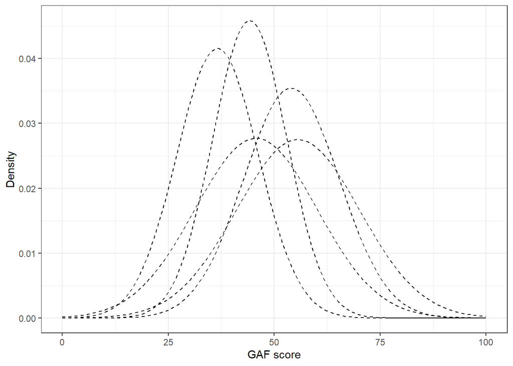

```r
GAF_dat <-
  dat |>
  # Filtering GAF measures and remove Gonzalez and Prihoda since they don't
  # provide enough data to be used for this calculation
  filter(str_detect(outcome, "GAF") & !str_detect(study, "Gon")) |>
  relocate(study)

GAF_dat_restricted <-
  GAF_dat |>
  group_by(study) |>
  filter(row_number() == 1) |>
  ungroup()

ggplot(data.frame(x = c(0, 100)), aes(x)) +
  mapply(function(mean, sd, col) {
    stat_function(fun = dnorm, args = list(mean = mean, sd = sd), linetype = "dashed", color = col)
  },
  # enter means, standard deviations and colors here
  mean = GAF_dat_restricted$m_post_c,
  sd = GAF_dat_restricted$sd_post_c,
  col = "black"
  ) +
  theme_bw() +
  labs(x = "GAF score", y = "Density")
```

```r
GAF_res <- population_SMD(GAF_dat_restricted)
GAF_res
```

```
## # A tibble: 1 × 18
##       N   N_0     J sigma2_WA m_post_mean_c  SSB0  MSB0 n0_star sigma2_B
##   <dbl> <dbl> <int>     <dbl>         <dbl> <dbl> <dbl>   <dbl>    <dbl>
## 1   557   266     5     155.0         47.22 7833. 1958.   251.0    7.183
##   sigma2_TA sd_population n_star     c1    c2    v1    v2 df_pop WaboveT
##       <dbl>         <dbl>  <dbl>  <dbl> <dbl> <dbl> <dbl>  <dbl>   <dbl>
## 1     162.2         12.74  46.55 0.2773 2.628   256     4  217.1  0.9557
```

```r
#saveRDS(GAF_res, "ES calc/GAF_res.rds")
```

### PHQ-9 population measures

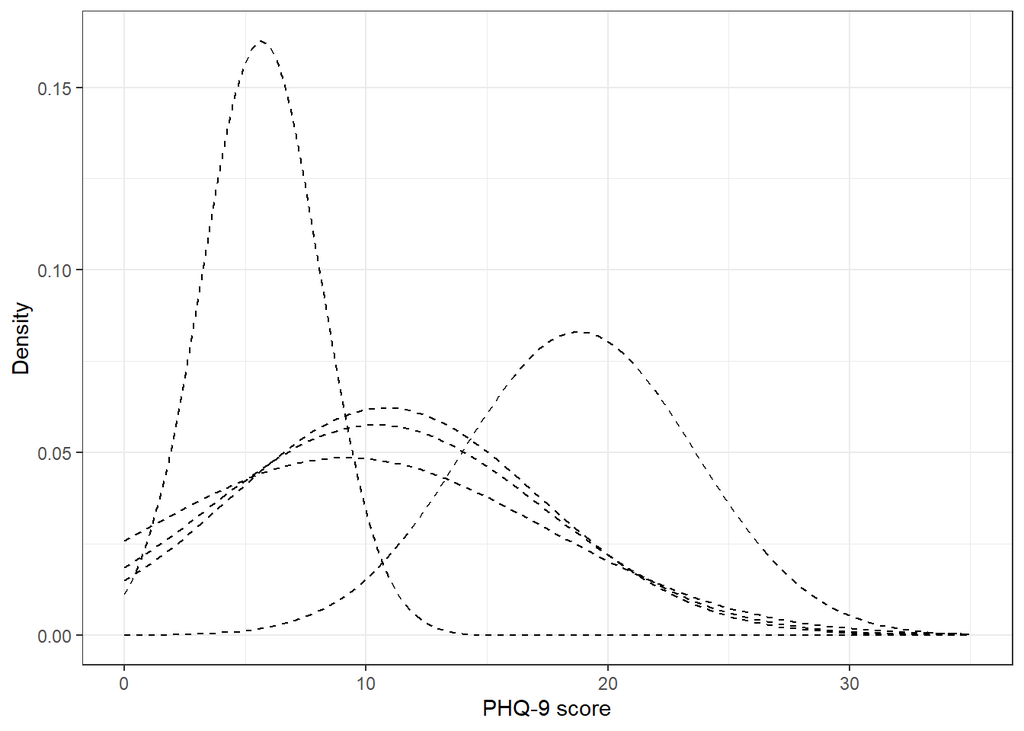

```r
PHQ_9_dat <-
  group_based_dat |>
  filter(
    str_detect(authors, "Cano|Hilden|Himle|Lloyd|Volpe") &
    str_detect(outcome, "9") & measure_type ==  "Post-intervention"
  )

# Removing follow-up effect size from Cano-Vindel
PHQ_9_dat <- PHQ_9_dat[-2,]

ggplot(data.frame(x = c(0, 35)), aes(x)) +
  mapply(function(mean, sd, col) {
    stat_function(fun = dnorm, args = list(mean = mean, sd = sd), linetype = "dashed", color = col)
  },
  # enter means, standard deviations and colors here
  mean = PHQ_9_dat$m_post_c,
  sd = PHQ_9_dat$sd_post_c,
  col = "black"
  ) +
  theme_bw() +
  labs(x = "PHQ-9 score", y = "Density")
```

```r
PHQ_9_res <- population_SMD(PHQ_9_dat)
PHQ_9_res
```

```
## # A tibble: 1 × 18
##       N   N_0     J sigma2_WA m_post_mean_c  SSB0  MSB0 n0_star sigma2_B
##   <dbl> <dbl> <int>     <dbl>         <dbl> <dbl> <dbl>   <dbl>    <dbl>
## 1  1230   605     5     36.15         10.97 1240. 310.1   511.2   0.5359
##   sigma2_TA sd_population n_star      c1     c2    v1    v2 df_pop WaboveT
##       <dbl>         <dbl>  <dbl>   <dbl>  <dbl> <dbl> <dbl>  <dbl>   <dbl>
## 1     36.68         6.056  32.80 0.02872 0.4094   595     4  75.29  0.9854
```

```r
#saveRDS(PHQ_9_res, "ES calc/PHQ_9_res.rds")
```

### BDI population measures

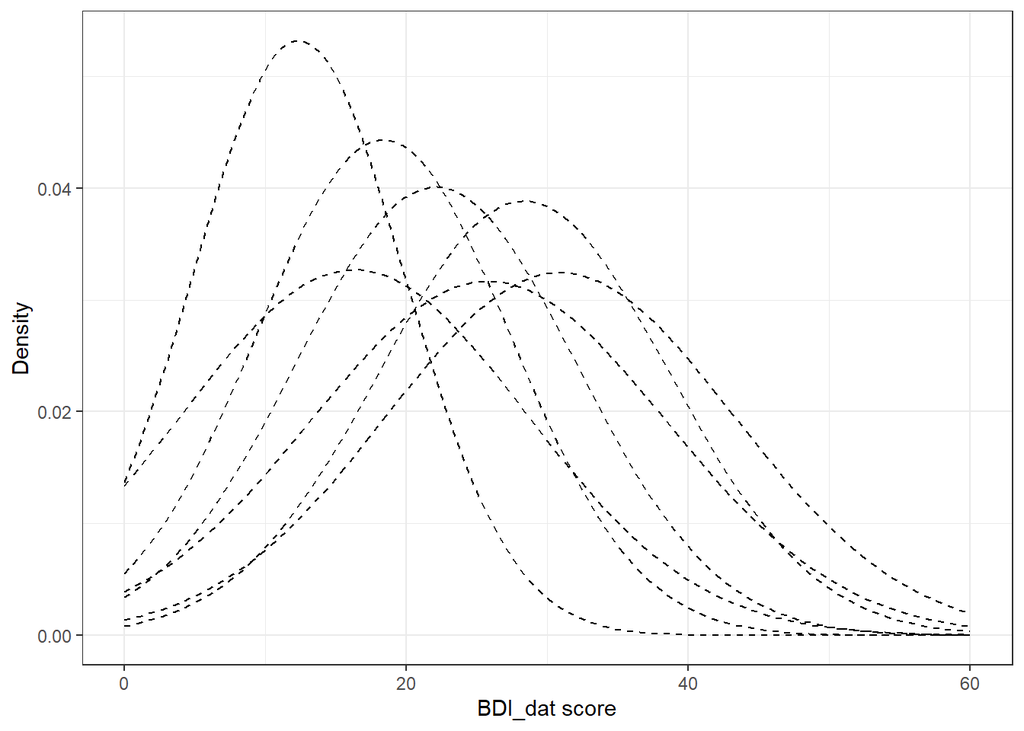

```r
BDI_dat <-
  group_based_dat |>
  filter(
    str_detect(authors, "Craigie|Hagen|Jacob|Michalak|Rabenstein|Sacks|Schäfer") &
    str_detect(outcome, "BDI")
  )

BDI_dat <- BDI_dat[-c(2, 5, 7, 10:13, 15),]

ggplot(data.frame(x = c(0, 60)), aes(x)) +
  mapply(function(mean, sd, col) {
    stat_function(fun = dnorm, args = list(mean = mean, sd = sd), linetype = "dashed", color = col)
  },
  # enter means, standard deviations and colors here
  mean = BDI_dat$m_post_c,
  sd = BDI_dat$sd_post_c,
  col = "black"
  ) +
  theme_bw() +
  labs(x = "BDI_dat score", y = "Density")
```

```r
BDI_res <- population_SMD(BDI_dat)
BDI_res
```

```
## # A tibble: 1 × 18
##       N   N_0     J sigma2_WA m_post_mean_c   SSB0  MSB0 n0_star sigma2_B
##   <dbl> <dbl> <int>     <dbl>         <dbl>  <dbl> <dbl>   <dbl>    <dbl>
## 1  1109   493     7     139.4         22.02 12512. 2085.   478.8    4.064
##   sigma2_TA sd_population n_star     c1    c2    v1    v2 df_pop WaboveT
##       <dbl>         <dbl>  <dbl>  <dbl> <dbl> <dbl> <dbl>  <dbl>   <dbl>
## 1     143.5         11.98  64.41 0.1253 1.038   479     6  300.7  0.9717
```

```r
#saveRDS(BDI_res, "ES calc/BDI_res.rds")
```

## **References**

Acarturk, C., Uygun, E., Ilkkursun, Z., Yurtbakan, T., Kurt, G., Adam-Troian, J., … Kiselev, N. (2022). Group problem management plus (PM+) to decrease psychological distress among Syrian refugees in Turkey: a pilot randomised controlled trial. *BMC Psychiatry*, *22*(8), 1–11. https://doi.org/10.1186/s12888-021-03645-w

Arbuckle, R., Frye, M. A., Brecher, M., Paulsson, B., Rajagopalan, K., Palmer, S., & Degl’ Innocenti, A. (2009). The psychometric validation of the Sheehan Disability Scale (SDS) in patients with bipolar disorder. *Psychiatry Research*, *165*(1), 163–174. https://doi.org/10.1016/j.psychres.2007.11.018

Bækkelund, H., Ulvenes, P., Boon-Langelaan, S., & Arnevik, E. A. (2022). Group treatment for complex dissociative disorders: a randomized clinical trial. *BMC Psychiatry*, *22*(1), 338. https://doi.org/10.1186/s12888-022-03970-8

Barbic, S., Krupa, T., & Armstrong, I. (2009). A randomized controlled trial of the effectiveness of a modified recovery workbook program: preliminary findings. *Psychiatric Services*, *60*(4), 491–497. https://doi.org/10.1176/ps.2009.60.4.491

Bond, G. R., Kim, S. J., Becker, D. R., Swanson, S. J., Drake, R. E., Krzos, I. M., … Frounfelker, R. L. (2015). A controlled trial of supported employment for people with severe mental illness and justice involvement. *Psychiatric Services*, *66*(10), 1027–1034. https://doi.org/10.1176/appi.ps.201400510

Cano-Vindel, A., Munoz-Navarro, R., JA, M., Ruiz-Rodriguez, P., LA, M., & Gonzalez-Blanch, C. (2021). Transdiagnostic group cognitive behavioural therapy for emotional disorders in primary care: the results of the PsicAP randomized controlled trial. *Psychological Medicine*, 1–13. https://doi.org/10.1017/S0033291720005498

Craigie, M. A., & Nathan, P. (2009). A Nonrandomized Effectiveness Comparison of Broad-Spectrum Group CBT to Individual CBT for Depressed Outpatients in a Community Mental Health Setting. *Behavior Therapy*, *40*(3), 302–314. https://doi.org/10.1016/j.beth.2008.08.002

Crawford, M. J., Killaspy, H., Barnes, T. R. E., Barrett, B., Byford, S., Clayton, K., … Johnson, T. (2012). Group art therapy as an adjunctive treatment for people with schizophrenia: multicentre pragmatic randomised trial. *Bmj*, *344*.

Dalgaard, N. T., Flensborg Jensen, M. C., Bengtsen, E., Krassel, K. F., & Vembye, M. H. (2022). PROTOCOL: Group‐based community interventions to support the social reintegration of marginalised adults with mental illness. *Campbell Systematic Reviews*, *18*(3), e1254. https://doi.org/10.1002/cl2.1254

Druss, B. G., Singh, M., Esenwein, S. A. von, Glick, G. E., Tapscott, S., Tucker, S. J., … Sterling, E. W. (2018). Peer-Led Self-Management of General Medical Conditions for Patients With Serious Mental Illnesses: A Randomized Trial. *Psychiatric Services*, *69*(5), 529–535. https://doi.org/10.1176/appi.ps.201700352

Druss, B. G., Zhao, L., Esenwein, S. A. von, Bona, J. R., Fricks, L., Jenkins-Tucker, S., … Lorig, K. (2010). The Health and Recovery Peer (HARP) Program: A peer-led intervention to improve medical self-management for persons with serious mental illness. *Schizophrenia Research*, *118*(1), 264–270. https://doi.org/10.1016/j.schres.2010.01.026

Dyck, D. G., Short, R. A., Hendryx, M. S., Norell, D., Myers, M., Patterson, T., … McFarlane, W. R. (2000). Management of Negative Symptoms Among Patients With Schizophrenia Attending Multiple-Family Groups. *Psychiatric Services*, *51*(4), 513–519. https://doi.org/10.1176/appi.ps.51.4.513

Fitzgerald, K. G., & Tipton, E. (2024). Using Extant Data to Improve Estimation of the Standardized Mean Difference. *Journal of Educational and Behavioral Statistics*, 10769986241238478. https://doi.org/10.3102/10769986241238478

Gatz, M., Brown, V., Hennigan, K., Rechberger, E., O’Keefe, M., Rose, T., & Bjelajac, P. (2007). Effectiveness of an integrated, trauma‐informed approach to treating women with co‐occurring disorders and histories of trauma: The Los Angeles site experience. *Journal of Community Psychology*, *35*(7), 863–878.

Gestel-Timmermans, H. van, Brouwers, E. P. M., Assen, M. A. L. M. van, & Nieuwenhuizen, C. van. (2012). Effects of a peer-run course on recovery from serious mental illness: a randomized controlled trial. *Psychiatric Services*, *63*(1), 54–60. https://doi.org/10.1176/appi.ps.201000450

Gonzalez, J. M., & Prihoda, T. J. (2007). A Case Study of Psychodynamic Group Psychotherapy for Bipolar Disorder. *American Journal of Psychotherapy*, *61*(4), 405–422. https://doi.org/10.1176/appi.psychotherapy.2007.61.4.405

Gordon, A., Davis, P. J., Patterson, S., Pepping, C. A., Scott, J. G., Salter, K., & Connell, M. (2018). A randomized waitlist control community study of Social Cognition and Interaction Training for people with schizophrenia. *British Journal of Clinical Psychology*, *57*(1), 116–130. https://doi.org/10.1111/bjc.12161

Gutman, S. A., Barnett, S., Fischman, L., Halpern, J., Hester, G., Kerrisk, C., … Wang, H. (2019). Pilot Effectiveness of a Stress Management Program for Sheltered Homeless Adults With Mental Illness: A Two-Group Controlled Study. *Occupational Therapy in Mental Health*, *35*(1), 59–71. https://doi.org/10.1080/0164212X.2018.1538845

Hagen, R., Nordahl, H. M., Kristiansen, L., & Morken, G. (2005). A Randomized Trial of Cognitive Group Therapy vs. Waiting List for Patients with Co-Morbid Psychiatric Disorders: Effect of Cognitive Group Therapy after Treatment and Six and Twelve Months Follow-Up. *Behavioural and Cognitive Psychotherapy*, *33*(1), 33–44. https://doi.org/10.1017/S1352465804001754

Halperin, S., Nathan, P., Drummond, P., & Castle, D. (2000). A cognitive-behavioural, group-based intervention for social anxiety in schizophrenia. *Australian and New Zealand Journal of Psychiatry*, *34*(5), 809–813. https://doi.org/10.1046/j.1440-1614.2000.00820.x

Haslam, C., Cruwys, T., Chang, M. X.-L., Bentley, S. V., Haslam, S. A., Dingle, G. A., & Jetten, J. (2019). *GROUPS 4 HEALTH reduces loneliness and social anxiety in adults with psychological distress: Findings from a randomized controlled trial.* https://doi.org/10.1037/ccp0000427

Hedges, L. V., Tipton, E., Zejnullahi, R., & Diaz, K. G. (2023). Effect sizes in ANCOVA and difference-in-differences designs. *British Journal of Mathematical and Statistical Psychology*. https://doi.org/10.1111/bmsp.12296

Hilden, H. M., Rosenstrom, T., Karila, I., Elokorpi, A., Torpo, M., Arajarvi, R., & Isometsa, E. (2021). Effectiveness of brief schema group therapy for borderline personality disorder symptoms: a randomized pilot study. *Nordic Journal of Psychiatry*, *75*(3), 176–185. https://doi.org/10.1080/08039488.2020.1826050

Himle, J., Bybee, D., Steinberger, E., Laviolette, W., Weaver, A., Vlnka, S., … Lisa, O. (2014). Work-related CBT versus vocational services as usual for unemployed persons with social anxiety disorder: A randomized controlled pilot trial. *Behaviour Research & Therapy*, *63*, 169–176. https://doi.org/10.1016/j.brat.2014.10.005

Ilić, I., Šipetić-Grujičić, S., Grujičić, J., Živanović Mačužić, I., Kocić, S., & Ilić, M. (2019). Psychometric properties of the world health organization’s quality of life (WHOQOL-BREF) questionnaire in medical students. *Medicina*, *55*(12), 772.

Izquierdo, G., Débora, Pérez, V., Luisa, M., Moreno, L., Raquel, … Juan, F. (2021). Training coping skills and coping with stress self-efficacy for successful daily functioning and improved clinical status in patients with psychosis: A randomized controlled pilot study. *Science Progress*, 1–22. https://doi.org/10.1177/00368504211056818

Jacob, G., Gabriel, S., Roepke, S., Stoffers, J., Lieb, K., & Hammers, C.-H. (2010). Group therapy module to enhance self-esteem in patients with borderline personality disorder: A pilot study. *International Journal of Group Psychotherapy*, *60*(3), 373–387. https://doi.org/10.1521/ijgp.2010.60.3.373

James, W., Preston, N. J., Koh, G., Spencer, C., Kisely, S. R., & Castle, D. J. (2004). A group intervention which assists patients with dual diagnosis reduce their drug use: a randomized controlled trial. *Psychological Medicine*, *34*, 983–990. https://doi.org/10.1017/s0033291703001648

Kanie, A., Kikuchi, A., Haga, D., Tanaka, Y., Ishida, A., Yorozuya, Y., … Nakagome, K. (2019). The Feasibility and Efficacy of Social Cognition and Interaction Training for Outpatients With Schizophrenia in Japan: A Multicenter Randomized Clinical Trial. *FRONTIERS IN PSYCHIATRY*, *10*. https://doi.org/10.3389/fpsyt.2019.00589

Lim, J. E., Kwon, Y.-J., Jung, S.-Y., Park, K., Lee, W., Lee, S.-H., … Choi, K.-H. (2020). Benefits of social cognitive skills training within routine community mental health services: Evidence from a non-randomized parallel controlled study. *Asian Journal of Psychiatry*, *54*, 102314. https://doi.org/10.1016/j.ajp.2020.102314

Lloyd-Evans, B., Frerichs, J., Stefanidou, T., Bone, J., Pinfold, V., Lewis, G., … Chipp, B. (2020). The Community Navigator Study: Results from a feasibility randomised controlled trial of a programme to reduce loneliness for people with complex anxiety or depression. *Plos One*, *15*(5), e0233535. https://doi.org/10.1371/journal.pone.0233535

Madigan, K., Brennan, D., Lawlor, E., Turner, N., Kinsella, A., JJ, O., … Eadbhard, O. (2013). A multi-center, randomized controlled trial of a group psychological intervention for psychosis with comorbid cannabis dependence over the early course of illness. *Schizophrenia Research*, *143*(1), 138–142. https://doi.org/10.1016/j.schres.2012.10.018

McCay, E., Beanlands, H., Leszcz, M., Goering, P., Seeman, M. V., Ryan, K., … Vishnevsky, T. (2006). *A Group Intervention to Promote Healthy Self-Concepts and Guide Recovery in First Episode Schizophrenia: A Pilot Study.* https://doi.org/10.2975/30.2006.105.111

McCay, E., Heather, B., Robert, Z., Roy, P., Leszcz, M., Landeen, J., … Chan, E. (2007). A randomised controlled trial of a group intervention to reduce engulfment and self-stigmatisation in first episode schizophrenia. *Australian e-Journal for the Advancement of Mental Health*, *6*(3). https://doi.org/10.5172/jamh.6.3.212

Michalak, J., Schultze, M., Heidenreich, T., & Schramm, E. (2015). A randomized controlled trial on the efficacy of mindfulness-based cognitive therapy and a group version of cognitive behavioral analysis system of psychotherapy for chronically depressed patients. *Journal of Consulting and Clinical Psychology*, *83*(5), 951. https://doi.org/10.1037/ccp0000042

Morley, K. C., Sitharthan, G., Haber, P. S., Tucker, P., & Sitharthan, T. (2014). The efficacy of an opportunistic cognitive behavioral intervention package (OCB) on substance use and comorbid suicide risk: A multisite randomized controlled trial. *Journal of Consulting and Clinical Psychology*, *82*(1), 130. https://doi.org/10.1037/a0035310

Morton, J., Snowdon, S., Gopold, M., & Guymer, E. (2012). Acceptance and commitment therapy group treatment for symptoms of borderline personality disorder: a public sector pilot study. *Cognitive and Behavioral Practice*, *19*(4), 527–544. https://doi.org/10.1016/j.cbpra.2012.03.005

Patterson, T. L., McKibbin, C., Taylor, M., Goldman, S., Davila-Fraga, W., Bucardo, J., & Jeste, D. V. (2003). Functional Adaptation Skills Training (FAST): A Pilot Psychosocial Intervention Study in Middle-Aged and Older Patients With Chronic Psychotic Disorders. *The American Journal of Geriatric Psychiatry*, *11*(1), 17–23. https://doi.org/10.1097/00019442-200301000-00004

Popolo, R., MacBeth, A., Canfora, F., Rebecchi, D., Toselli, C., Salvatore, G., & Dimaggio, G. (2019). Metacognitive Interpersonal Therapy in group (MIT-G) for young adults with personality disorders: a pilot randomized controlled trial. *Psychology and Psychotherapy*, *92*(3), 342–358. https://doi.org/10.1111/papt.12182

Rabenstein, R., Pintzinger, N., Knogler, V., Kirnbauer, V., Lenz, G., & Schosser, A. (2015). Effectiveness of a cognitive-behavioral rehabilitation day clinic program - A waiting list controlled trial. *Verhaltenstherapie*, *25*, 192–200. https://doi.org/10.1159/000437449

Ravesteijn, H. van, Wittkampf, K., Lucassen, P., Lisdonk, E. van de, Hoogen, H. van den, Weert, H. van, … Speckens, A. (2009). Detecting somatoform disorders in primary care with the PHQ-15. *The Annals of Family Medicine*, *7*(3), 232–238. https://doi.org/10.1370/afm.985

Rosenblum, A., Matusow, H., Fong, C., Vogel, H., Uttaro, T., Moore, T. L., & Magura, S. (2014). Efficacy of dual focus mutual aid for persons with mental illness and substance misuse. *Drug and Alcohol Dependence*, *135*, 78–87. https://doi.org/10.1016/j.drugalcdep.2013.11.012

Rüsch, N., Staiger, T., Waldmann, T., Dekoj, M. C., Brosch, T., Gabriel, L., … Becker, T. (2019). Efficacy of a peer-led group program for unemployed people with mental health problems: Pilot randomized controlled trial. *International Journal of Social Psychiatry*, *65*(4), 333–337. https://doi.org/10.1177/0020764019846171

Russinova, Z., Gidugu, V., Bloch, P., Restrepo-Toro, M., & Rogers, E. S. (2018). *Empowering individuals with psychiatric disabilities to work: Results of a randomized trial.* https://doi.org/10.1037/prj0000303

Sacks, S., McKendrick, K., Vazan, P., Sacks, J. Y., & Cleland, C. M. (2011). Modified therapeutic community aftercare for clients triply diagnosed with HIV/AIDS and co-occurring mental and substance use disorders. *AIDS Care*, *23*(12), 1676–1686. https://doi.org/10.1080/09540121.2011.582075

Sajatovic, M., MA, D., SJ, G., MS, B., KA, C., RW, H., … JR, C. (2009). A comparison of the life goals program and treatment as usual for individuals with bipolar disorder. *Psychiatric Services (Washington, D.C.)*, *60*(9), 1182–1189. https://doi.org/10.1176/ps.2009.60.9.1182

Saloheimo, H. P., Markowitz, J., Saloheimo, T. H., Laitinen, J. J., Sundell, J., Huttunen, M. O., … O. Katila, H. (2016). Psychotherapy effectiveness for major depression: a randomized trial in a Finnish community. *BMC Psychiatry*, *16*, 1–9. https://doi.org/10.1186/s12888-016-0838-1

Schäfer, I., Lotzin, A., Hiller, P., Sehner, S., Driessen, M., Hillemacher, T., … Grundmann, J. (2019). *A multisite randomized controlled trial of Seeking Safety vs. Relapse Prevention Training for women with co-occurring posttraumatic stress disorder and substance use disorders.* https://doi.org/10.1080/20008198.2019.1577092

Schrank, B., Brownell, T., Jakaite, Z., Larkin, C., Pesola, F., Riches, S., … Slade, M. (2016). Evaluation of a positive psychotherapy group intervention for people with psychosis: pilot randomised controlled trial. *Epidemiology and Psychiatric Sciences*, *25*(3), 235–246. https://doi.org/10.1017/S2045796015000141

Smith, R., Wuthrich, V., Johnco, C., & Belcher, J. (2021). Effect of group cognitive behavioural therapy on loneliness in a community sample of older adults: A secondary analysis of a randomized controlled trial. *Clinical Gerontologist*, *44*(4), 439–449.

Somers, J. M., Moniruzzaman, A., Patterson, M., Currie, L., Rezansoff, S. N., Palepu, A., & Fryer, K. (2017). A randomized trial examining housing first in congregate and scattered site formats. *PloS One*, *12*(1), e0168745. https://doi.org/10.1371/journal.pone.0168745

Spitzer, R. L., Kroenke, K., Williams, J. B. W., & Löwe, B. (2006). A Brief Measure for Assessing Generalized Anxiety Disorder: The GAD-7. *Archives of Internal Medicine*, *166*(10), 1092–1097. https://doi.org/10.1001/archinte.166.10.1092

Tjaden, C., CL, M., W, den H., Castelein, S., Delespaul, P., Keet, R., … Kroon, H. (2021). Effectiveness of Resource Groups for Improving Empowerment, Quality of Life, and Functioning of People With Severe Mental Illness A Randomized Clinical Trial. *JAMA PSYCHIATRY*, *78*(12), 1309–1318. https://doi.org/10.1001/jamapsychiatry.2021.2880

Valiente, C., Espinosa, R., Contreras, A., Trucharte, A., Caballero, R., Peinado, V., … Perdigón, A. (2022). A multicomponent positive psychology group intervention for people with severe psychiatric conditions; a randomized clinical trial. *Psychiatric Rehabilitation Journal*, *45*(2), 103–113. https://doi.org/10.1037/prj0000509

Volpe, U., Torre, F., De Santis, V., Perris, F., & Catapano, F. (2015). Reading group rehabilitation for patients with psychosis: A randomized controlled study. *Clinical Psychology & Psychotherapy*, *22*(1), 15–21. https://doi.org/10.1002/cpp.1867

Wojtalik, J., Eack, S., & Keshavan, M. (2019). Confirmatory efficacy of cognitive enhancement therapy for early schizophrenia: Results from a multi-site randomized trial. *2019 Congress of the Schizophrenia International Research Society, SIRS 2019. Orlando, FL United States.*, *45*(Supplement 2), S184. https://doi.org/10.1093/schbul/sbz021.235

Wuthrich, V. M., & Rapee, R. M. (2013). Randomised controlled trial of group cognitive behavioural therapy for comorbid anxiety and depression in older adults. *Behaviour Research and Therapy*, *51*(12), 779–786. https://doi.org/10.1016/j.brat.2013.09.002

WWC. (2021). *Supplement document for Appendix E and the What Works Clearinghouse procedures handbook, version 4.1*. Retrieved from https://ies.ed.gov/ncee/wwc/Docs/referenceresources/WWC-41-Supplement-508_09212020.pdf

Zuithoff, N. P. A., Vergouwe, Y., King, M., Nazareth, I., Wezep, M. J. van, Moons, K. G. M., & Geerlings, M. I. (2010). The Patient Health Questionnaire-9 for detection of major depressive disorder in primary care: consequences of current thresholds in a crosssectional study. *BMC Family Practice*, *11*(1), 98. https://doi.org/10.1186/1471-2296-11-98